# Birds

Ross Clark

## 1. Introduction

There may not have been a domain of the Proto Oceanic lexicon corresponding precisely to the Class Aves. The creatures referred to by reflexes of POc *manuk (below) almost always include bats and sometimes other flying animals. For example, Kwaio *laŋasi* (a taboo replacement for *manu*) ‘in the broadest categorical sense, includes birds, butterflies, moths, bats, dragonflies and one species of frogs (*Pseudophryne* sp.)’ (Keesing 1975:119). At its widest *manuk may have encompassed the entire non-aquatic animal kingdom (for discussion see chapter 8, §§5 and 6). More restrictive expressions are often coined by adding a modifier to *manuk, typically the verb ‘to fly’, for example Chuukese *māɾ* ‘living creature of land or air (other than human)’, *mac̣c̣aŋ* ‘bird’ (cf. *c̣aŋ* ‘fly’). The organisation of this book, however, follows the Linnaean classification, and bats will be found in chapter 5, with only a couple of cross-references below to connect the two.

| **POc** |  | *manuk | (1) ‘flying creature’; (2) ‘animal’ |
| --- | --- | --- | --- |
| Adm | Lou | *mon-mon* | ‘bird’ |
| NNG | Mangap | *man* | ‘bird, also includes bats and other flying creatures with bones’ |
| NNG | Lukep (Pono) | *man* | ‘bird (generic)’ |
| NNG | Lukep (Pono) | *manu-manu* | ‘bird sp., flycatcher’ |
| NNG | Bariai | *man* | ‘bird’ |
| NNG | Manam | *maŋ* | ‘bird, chicken’ |
| NNG | Hote | *menak* | ‘bird’ |
| NNG | Mapos Buang | *mank* | ‘bird’ |
| MM | Bali | *manuku* | ‘bird’ |
| MM | Bola | *manu* | ‘fish’ |
| MM | Bulu | *manu* | ‘bird’ |
| MM | Kara (East) | *manu* | ‘bird’ |
| MM | Nalik | *mani* | ‘bird’ |
| MM | Lihir | *mon* | ‘bird’ |
| MM | Sursurunga | *man* | ‘bird, flying thing (not insects)’ |
| MM | Banoni | *manuɣu* | ‘bird’ |
| MM | Simbo | *manuɣu* | ‘all creatures, including animals, human beings, birds, marine mammals and possibly fish; thing thingummybob’ |
| PT | Iduna | *manuga* | ‘bird’ |
| PT | Tawala | *manuwa* | ‘bird’ |
| PT | Balawaia | *manu* | ‘bird’ |
| PT | Motu | *manu* | ‘all creatures that fly, including flying foxes’ |
| SES | Bugotu | *manu* | ‘bird’ |
| SES | Gela | *manu* | ‘bird, flying creature’ |
| SES | Kwaio | *manu* | ‘bird’ |
| SES | Lau | *manu* | ‘bird’ |
| SES | Sa’a | *menu* | ‘bird, insect’ |
| SES | Longgu | *manu* | ‘bird’ |
| SES | Longgu | *manu-manu* | ‘insect’ |
| SES | Arosi | *manu* | ‘bird, winged creature’ |
| TM | Buma | *menuko* | ‘bird’ |
| NCV | Mota | *manu* | ‘bird, flying creature, beetle, bat’ |
| NCV | Raga | *manu* | ‘bird’ |
| NCV | Big Nambas | *nanəɣ* | ‘bird’ |
| NCV | Malua Bay | *nə-menox* | ‘bird’ |
| NCV | Paamese | *a-manu* | ‘bird’ |
| NCV | Uripiv | *nu-mön* | ‘bird’ |
| NCV | Port Sandwich | *na-man* | ‘bird’ |
| NCV | Nguna | *mānu* | ‘bird’ |
| **PSV** |  | *manuɣ | ‘bird’ (Lynch 2001) |
| SV | Sye | *menuɣ* | ‘bird’ |
| SV | Lenakel | *menuk* | ‘bird’ |
| SV | Kwamera | *menu* | ‘bird’ |
| SV | Anejom̃ | *in-man* | ‘bird’ |
| **PMic** |  | *manu | ‘living creature of land or air’ (Bender et al. 1983) |
| Mic | Kiribatese | *te-man* | ‘animal, bird’ |
| Mic | Kosraean | *mœn* | ‘animal, insect’ |
| Mic | Trukese | *mān* | ‘living creature’ |
| Mic | Puluwatese | *mān* | ‘living creature’ |
| Mic | Carolinian | *māl* | ‘living creature’ |
| Mic | Ponapean | *mān* | ‘animal, insect’ |
| Fij | Boumā | *manu-manu* | ‘animal, bird’ |
| Fij | Wayan | *manu-manu* | ‘animal, living thing, creature, being, normally excluding human beings’ |
| Fij | Rotuman | *man-manu* | ‘bird, animal, insect’ |
| Pn | Tongan | *manu* | ‘animal, bird’ |
| Pn | Niuean | *manu* | ‘animal’ |
| Pn | Anutan | *manu* | ‘bird or flying insect’ |
| Pn | Anutan | *manu-manu* | ‘animal’ |
| Pn | Pileni | *manu* | ‘bird, flying animal’ |
| Pn | Pileni | *manu-manu* | ‘bird’ |
| Pn | Rennellese | *manu* | ‘fauna except human beings’ |
| Pn | Tikopia | *manu* | ‘creature, ranging from mammal to arthropod; especially including birds’ |
| Pn | East Futunan | *manu* | ‘animal, animal, bird’ |
| Pn | East Uvean | *manu* | ‘animal’ |
| Pn | Samoan | *manu* | ‘animal, bird’ |
| Pn | Luangiua | *maŋu* | ‘bird, animal’ |
| Pn | Tuvalu | *manu* | ‘animal’ |
| Pn | Hawaiian | *manu* | ‘bird’ |
| Pn | Māori | *manu* | ‘bird’ |

Birds played varied roles in the life of Oceanic speakers. Besides the domesticated fowl (*Gallus gallus*), some types of birds (including frigate birds and parrots) were caught and kept as pets. Others were prized as food (pigeons and doves, some seabirds). The large eggs of the megapode were gathered for food. The feathers of many species had decorative uses, and their bones were used for a range of artefacts from needles to flutes. Birds could be caught with snares, nets or traps of various kinds, or shot with bow and arrow. (Special blunt-tipped arrows avoided damage to valued feathers.) Apart from direct exploitation, some birds could be sources of useful information, such as flocks of terns indicating the location of schools of fish, or landbirds far out at sea, indicating the presence of land nearby. Some, on the other hand, were harmful, such as the raptors that preyed on domestic fowl, or the swamp-hen with its destructive effects on taro gardens.

A widespread belief was that the voices of certain species could foretell such events as a death or the arrival of visitors. In eastern Polynesia, the visitors themselves were referred to as ‘birds’ (PCEPn *manu-firi ‘chosen (?) birds’). And in myth, folk tale and religious belief, birds play almost as varied a range of roles as do humans. Among the Dobuans, ‘the native term for totem is the term for bird … [and] one stranger may ask another, “what is your bird?”’ (Fortune 1963:32).

## 2. The life and parts of birds

A few aspects of avian anatomy and behaviour are different enough from their human (or mammalian) analogues that they might be expected to be separately lexicalised. In most cases, however, POc appears to have found commonalities with more general anatomical features of the animal kingdom.

Perhaps the most emblematic features of birds are feathers and wings. But the most general term for feathers is the same as that for human body hair and animal fur:

| **PMP** |  | *bulu | ‘body hair, fur, feather, down, floss’ (Dempwolff 1938) |
| --- | --- | --- | --- |
| **POc** |  | *pulu | ‘body hair, fur, feathers’ |
| Yap | Yapese | *wul* | ‘feather’ |
| NNG | Hote | *vulu-k* | ‘hair, feathers’ |
| PT | Motu | *hui-na* | ‘hair, feather’ |
| PT | Mekeo | *pui* | ‘feather’ |
| MM | Nakanai | *vulu* | ‘feathers, feather headdress’ |
| MM | Nehan | *ulu-* | ‘feather’ |
| SES | Bugotu | *vulu-ña* | ‘feather, hair’ |
| SES | Gela | *vu-vulu* | ‘hair, feather’ |
| NCV | Mota | *ulu-i* | ‘hair, feathers’ |
| NCV | Paamese | *hilin* | ‘hair (of head), feathers’ |
| NCV | Lewo | *vilu-na* | ‘feather, hair’ |
| NCal | Pije | *pun-* | ‘hair, feather’ |
| NCal | Ajië | *pūrū* | ‘feather’ |
| Fij | Wayan | *vulu* | ‘hair, fur, feathers’ |
| Pn | Tongan | *fulu-fulu* | ‘hair (esp. on the body), fur, feathers’ |
| Pn | Rennellese | *hugu* | ‘body hair, feathers, fur’ |
| Pn | Māori | *huru* | ‘hair, feather’ |

A second set with this meaning is connected with PMP *ibut ‘pull, uproot’ (Blust 1995):

| **POc** |  | *ipu | ‘hair, feather’ |
| --- | --- | --- | --- |
| MM | Bola | *ivu* | ‘hair, feather’ |
| MM | Nakanai | *ivu-la* | ‘head hair, plumage of bird’ |
| MM | Tolai | *ivu* | ‘body hair, fur, feathers’ |
| SES | Tolo | *ivu-na* | ‘hair, fur, feathers’ |
| SES | Kwaio | *ifīfu-na* | ‘feather, hair’ |
| SES | Sa’a | *ihu* | ‘hair, feather’ |

Both of the above refer to the overall covering of birds that is analogous to the hair covering of mammals. Feathers particularly conspicuous by length or colour have probably always been of special interest and valued as decoration. A term for such feathers is reconstructed for PMP, but its unambiguous Oceanic reflexes are restricted in scope:

| **PMP** |  | *lawi | ‘tail feather’ (Dempwolff 1938) |
| --- | --- | --- | --- |
| **POc** |  | *lawe | ‘tail feather, plume’ |
| Fij | Rotuman | *lalɔvi* | ‘feather’ |
| Fij | Bauan | *lawe* | ‘the larger feathers of a bird’ |
| Pn | Tongan | *lave* | ‘long tail-feather’ |
| Pn | Samoan | *lave* | ‘a part of a head-dress, a crest’ |

A number of forms suggested a variant reconstruction *la-lau[^1]

| NNG | Manam | *la-lau* | ‘feather’ |
| --- | --- | --- | --- |
| NNG | Bing | *la-lahaw* | ‘tail feathers of poultry’ |
| MM | Tangga | *o-lo-lo* | ‘hair, feathers’ |
| MM | Nehan | *la-le* | ‘feather’ |
| SES | Kwaio | *la-la(ŋala)* | ‘feather’ |
| NCV | Raga | *la-lau* | ‘feather’ |
| SV | Anejom̃ | *na-lau* | ‘feather’ |
| Fij | Wayan | *lau-lau* | ‘tail’ |

A distinct lexical item POc *banic ‘wing, arm, hand, fin (probably pectoral)’ is widely attested. Its PMP ancestor *panij denoted only wings, but its meaning had clearly been extended in POc (see chapter 2 for a fuller cognate set and discussion).

| **PMP** |  | *panij | ‘wing’ (ACD; Dempwolff 1938) |
| --- | --- | --- | --- |
| **POc** |  | *banic | ‘arm, hand, wing, fin (probably pectoral)’ |
| Adm | Kaniet | *pani* | ‘wing, hand, fin’ |
| Adm | Nyindrou | *bani-n* | ‘wing’ |
| Adm | Nauna | *pin* | ‘wing’ |
| Adm | Mondropolon | *pani-n* | ‘wing’ |
| Adm | Drehet | *peni-ŋ* | ‘wing’ |
| NNG | Gedaged | *bani-n* | ‘fin, wing’ |
| NNG | Wampur | *bani-t* | ‘wing’ |
| NNG | Mapos Buang | *bani-s* | ‘fin, wing’ |
| PT | Gumawana | *pane-pane-na* | ‘fish fins, bird’s wing’ |
| PT | Balawaia | *vane* | ‘wing, fin’ (expected †*bani*) |
| PT | Motu | *hani* | ‘wing, fin’ (expected †*bani*) |
| PT | Mekeo | *pa-pani* | ‘wing-like object, incl. fins’ (expected †*fani*) |
| MM | Vitu | *baniti-* | ‘wing, upper arm’ |
| NCV | Mota | *panei, paniu* | ‘hand and arm, wing, pectoral fin, pig’s shoulder’ |
| NCV | Merlav | *bani* | ‘wing’ |
| NCV | Atchin | *na-ᵐben* | ‘wing, sail, armlet’ |
| NCal | Iaai | *beñi-n* | ‘hand, arm, fin’ |
| NCal | Iaai | *la-beñi-n* | ‘wing’ |
| Mic | Marshallese | *pā* | ‘arm, hand, wing, fin’ |
| Mic | Carolinian | *ppʷan* | ‘pectoral fin and attached bone of fish’ |
| Mic | Ulithian | *pal* | ‘ventral fin; hand’ |

Dempwolff (1938) reconstructs PMP *kapak ‘wings; flutter’ on the basis of Oceanic data and Malay *kepak*, Ngaju Dayak *kapak*. This etymon appears to be reflected by the widespread etymon POc *kaba (N) ‘wing’, (v) ‘flap wings’.

| **PMP** |  | *kapak | ‘wings; flutter’ (Dempwolff 1938) |
| --- | --- | --- | --- |
| **POc** |  | *kaba | [N] ‘wing’; [v] ‘flap wings’ |
| SES | Lau | *ʔaba* | ‘wing, hand, arm, foreleg’ |
| SES | Lau | *ʔaba-ʔaba* | ‘to flap the wings’ |
| SES | Kwaio | *ʔaba-ʔaba* | ‘wing’ |
| SES | ’Are’are | *apa* | ‘wing’ |
| SES | ’Are’are | *ʔapa-a* | ‘flap wings’ |
| SES | Sa’a | *ʔapa-ʔapa* | ‘wing’ |
| TM | Buma | *ava* | ‘wing’ |
| TM | Buma | *-ava* | ‘to fly’ |
| TM | Tanema | *-apa* | ‘to fly’ |
| NCV | Mota | *ɣava* | ‘flap wings, fly’ |
| NCV | Nokuku | *kave-n* | ‘wing’ |
| NCV | Tolomako | *kava-kava* | ‘wing’ |
| NCV | Tolomako | *kava* | ‘fly’ |
| NCV | Raga | *ɣaba* | ‘wing’ |
| NCV | Malua Bay | *gə-gep* | ‘fly’ |
| SV | Lenakel | *nə-kav-kavə-* | ‘wing’ |
| Fij | Wayan | *kā-kava* | ‘wing’ |
| Fij | Rotuman | *kap-kapo* | ‘to flutter downwards as if about to alight (of birds flying)’ |
| **PPn** |  | *kapa | [v] ‘beat, of wings, fins, flippers’ (pollex) |
| **PPn** |  | *kapa-kapa | [N] ‘fish fins’; [v] ‘flap wings’ (pollex) |
| Pn | Tongan | *kapa-kapa* | ‘side fin; flap wings’ |
| Pn | Samoan | *ʔapa-ʔapa* | ‘fin; flap wings’ |
| Pn | Samoan | *ʔapa* | ‘to beat, of bird’s wing, turtle flipper etc.’ |
| Pn | Pukapukan | *kapa-kapa* | ‘fish fin, turtle flipper, bird wing, arm of baby’ |
| Pn | Tikopia | *kapa-kapa* | ‘pectoral fins; flap wings’ |
| Pn | East Futunan | *kapa(tā)* | ‘beat wings’ |
| Pn | Tuvalu | *kopa* | ‘flap wing’ |
| Pn | Māori | *kapa-kapa* | ‘flap wings, flutter’ |

Derived from PPn *kapa is PPn *kapa-kau ‘wing, fin’:

| **PPn** |  | *kapa-kau | ‘wing, fin’ (pollex) |
| --- | --- | --- | --- |
| Pn | Tongan | *kapakau* | ‘wing, winged’ |
| Pn | Niuean | *tapakau* | ‘wing of a bird, fin of a fish’ |
| Pn | East Futunan | *kapakau* | ‘wing’ |
| Pn | East Uvean | *kapakau* | ‘wing’ |
| Pn | Rennellese | *kapakau* | ‘wing’ |
| Pn | Tikopia | *kapakau* | ‘shoulder, upper arm, wing, fin’ |
| Pn | Luangiua | *apaʔau* | ‘wing’ |
| Pn | Samoan | *ʔapaʔau* | ‘wing’ |
| Pn | Tuvalu | *kapakau* | ‘wing, arm, lateral fin’ |

Blust (ACD) also reconstructs PWMP *kepek ‘flap wings’ (expected POc form †*kopo(k)) and PWMP *kepay-kepay ‘flap (wings, fins of fish, etc.)’ (expected POc form †*kope) with supporting data, and crossreferences the doublets *kapay and *kipay (without supporting data) (expected POc forms †*kape and †*kipe). PMP *kapay is perhaps reflected by Tawala *apape* ‘wing’. I find no straightforward reflexes of Blust’s other reconstructions, but Iduna (PT) *ofa-na* ‘(its) wing’ and Gela (SES) *gapo-gapo* ‘spread wings, flap, flutter’ suggest that there were perhaps several phonologically similar forms in POc cognate with the forms found in Western Malayo-Polynesian languages.

A bird’s beak was most probably referred to as POc *ŋuju, denoting the external or protruding aspect of the mouth. There is also some evidence for POc *muju, in the form of non-Oceanic terms from which Blust (ACD) reconstructs PWMP *mu(n)cuŋ ‘mouth (of an animal), snout’,[^2] together with the Iduna, Gapapaiwa and Balawaia terms listed below, reflecting PPT *mu(d,j)u. However, it may be that this is a chance similarity and that PPT *muju was an irregular reflex of POc *ŋuju.[^3]

| **POc** |  | *ŋuju | ‘mouth, lips, snout, beak’ |
| --- | --- | --- | --- |
| PT | Motu | *udu* | ‘mouth, nose, beak’ |
| MM | Nehan | *ŋohŋoho-* | ‘beak’ |
| MM | Roviana | *ŋuzu* | ‘beak’ |
| MM | Roviana | *ŋuzu-ŋuzu* | ‘carved prow of war canoe’ |
| SES | Kwaio | *ŋidu-na* | ‘beak’ |
| Fij | Wayan | *ŋusu* | ‘mouth of an animal; external mouth or lips of a person, fish, etc.; beak (of bird or turtle); snout or muzzle of a dog, pig, etc.’ |
| Pn | Tongan | *ŋutu* | ‘mouth, beak, orifice’ |
| Pn | Rennellese | *ŋutu* | ‘mouth, beak, breath’ |
| Pn | Māori | *ŋutu* | ‘lip, beak, rim, mouth, entrance’ |

cf. also:

| PT | Iduna | *mudu* | ‘carved prow’ |
| --- | --- | --- | --- |
| PT | Gapapaiwa | *mutu* | ‘lips, beak’ |
| PT | Balawaia | *muru* | ‘beak’ |

Many, perhaps most Oceanic languages make some lexical distinctions among the tails of birds, fish, reptiles and mammals. The following very common term for tail appears applicable to birds in many languages:

| **PAn** |  | *ikuR | ‘tail’ (Blust 1995) |
| --- | --- | --- | --- |
| **POc** |  | *iku(R) | ‘tail, of quadruped, some birds and possibly fish’ (cf ch. 5, §7.1.3) |
| Adm | Nyindrou | *kiwi-n* | (metathesis) |
| NNG | Manam | *eku* |  |
| NNG | Gitua | *igu* |  |
| NNG | Gedaged | *wi-n* | (metathesis) |
| NNG | Takia | *uyu-n* |  |
| PT | Kilivila | *yeyu-na* |  |
| PT | Tawala | *giu-na* | (metathesis) |
| PT | Balawaia | *ɣiɣu* |  |
| MM | Nakanai | *kiu* | (metathesis) |
| SES | Bugotu | *iu-iɣu* | ‘tail (of dog, bird, fish)’ |
| SES | Kwaio | *ʔiʔi-na* |  |
| SES | Sa’a | *ʔu-ʔuʔi-na* | ‘tail of an animal’ (metathesis) |
| SES | Gela | *igu* |  |
| NCal | Xârâcùù | *kʷi* |  |
| Mic | Trukese | *wɨ̄k* |  |
| Mic | Ponapean | *iki* |  |
| Pn | Tongan | *iku* |  |

Finally, the feet of most bird species are likened to animal claws and fingernails:

| **PMP** |  | *kuSkuS | ‘claw, finger, toenail’ |
| --- | --- | --- | --- |
| **POc** |  | *kuku | ‘nail (of hand or foot), claw’ |
| NNG | Mangap | *kukūnu* | ‘claw’ |
| PT | Tawala | *gigi-na* | ‘claw’ |
| SES | Bugotu | *ɣuɣu* | ‘hoof, claw’ |
| SES | Gela | *kuku* | ‘swoop on prey, as a bird’ |
| SES | Tolo | *huhu-na* |  |
| Mic | Trukese | *kkɨ-ɾ, wɨ̄k* |  |
| Mic | Kiribatese | *ūki* |  |
| Mic | Kiribatese | *gugu* | ‘digit of person or animal: big toe, thumb, hoof, talon, claw’ |
| Pn | Tongan | *kuku* | ‘grasp, grip, clutch, hold on to’ |
| Pn | East Futunan | *(moti)kuku* | ‘claws’ |
| Pn | Māori | *(mai)kuku* | ‘nail, claw, hoof’ |

Other anatomical features such as the cock’s comb and spurs are lexicalised diversely and there is no clear POc reconstruction.

The laying of relatively large (and often edible) eggs is distinctive of birds (along with turtles and other reptiles). A well established reconstruction is:

| **PMP** |  | *qateluR | ‘egg, testicle’ (Blust 1995) |
| --- | --- | --- | --- |
| **POc** |  | *qatoluR | ‘egg’ |
| Adm | Aua | *aʔulul* |  |
| Adm | Seimat | *atōli* |  |
| Adm | Loniu | *ɛlutu* | (metathesis) |
| Adm | Mussau | *otōlu* |  |
| NNG | Kairiru | *katol* |  |
| NNG | Tumleo | *tali-n* |  |
| NNG | Yabem | *ŋa-keʔsulu* |  |
| NNG | Mangap | *(man) kutulūnu* |  |
| NNG | Arawe | *gasuslu* |  |
| PT | Motu | *gatoi* |  |
| PT | Mekeo | *aoi* |  |
| MM | Nakanai | *hatotolu* |  |
| MM | Tangga | *katalu* |  |
| MM | Patpatar | *tulur* |  |
| MM | Simbo | *toruru* |  |
| SES | Bugotu | *kidoru* |  |
| SES | Gela | *tolu* |  |
| SES | Tolo | *kolu-na* |  |
| SES | Sa’a | *saolu* |  |
| SES | Bauro | *aoru* |  |
| NCV | Mota | *toliu* |  |
| NCV | Paamese | *orelī(te)* |  |
| NCV | Namakir | *ʔatol* |  |
| SV | Ura | *n-ahli-* |  |
| SV | Lenakel | *(noua-)n-ahlə-* |  |
| NCal | Iaai | *wākuñ* |  |
| Mic | Ponapean | *kutōr* |  |
| Mic | Kiribatese | *(pun)atoi* |  |

cf. also:

| Fij | Rotuman | *kalofi* | (expected †*ʔafolu*) |
| --- | --- | --- | --- |

A word of more general reference, POc *puaq, originally ‘fruit’, but generalised as a classifier for a wide range of more or less spherical objects, is sometimes used for eggs, but this may well be the result of repeated local extensions.

| NNG | Gitua | *pua* | ‘egg’ |
| --- | --- | --- | --- |
| NNG | Lukep (Pono) | *pua-na* | ‘egg’ |
| PT | Bwaidoga | *fou* | ‘egg’ |
| SES | Arosi | *hua i kua* | ‘fowl’s egg’ |
| Pn | Rennellese | *hua* | ‘fruit, berry, egg’ |
| Pn | East Futunan | *fua ʔi moa* | ‘hen’s egg’ |
| Pn | Māori | *hua* | ‘fruit, egg’ |

Despite the great variety in the form and construction of birds’ nests (note PMic *fata ‘platform, nest’ from POc *patar ‘platform’, vol.1,57 and p. 190), a common term can be reconstructed (sometimes stated as also applying to nests or dens of animals).

| **PEMP** |  | *niku(i) | ‘nest’[^4] |
| --- | --- | --- | --- |
| **POc** |  | *(n,ñ)iku~nuki | ‘nest’ |
| NNG | Amara | *o-nuk* |  |
| NNG | Aria | *o-nuk* |  |
| NNG | Mapos Buang | *nwi-s* | ‘nest, den’ |
| PT | Are | *nigu-na* | ‘nest, den, hole’ |
| PT | Tawala | *nunu* |  |
| PT | Balawaia | *nuɣi* |  |
| PT | Mekeo | *ni-na* |  |
| MM | Kara (East) | *niu* |  |
| MM | Nehan | *niu* |  |
| MM | Maringe | *ñoku* |  |
| SES | Bugotu | *ñiku* |  |
| SES | Gela | *niku* |  |
| SES | Kwaio | *nūʔi* |  |
| SES | Tolo | *niku-na* |  |
| NCV | Mota | *niɣiu* |  |
| NCV | Paamese | *a-nu, nūnu* |  |

A PCP form is also reconstructable:

| **PCP** |  | *ova | ‘nest’ |
| --- | --- | --- | --- |
| Fij | Wayan | *ova* | ‘nest of a bird’ |
| Pn | East Futunan | *ōfa(ŋa)* | ‘nest’ |
| Pn | Samoan | *ōfa(ŋa)* | ‘nest’ |
| Pn | Emae | *ofa(ŋa)* | ‘nest of bird or animal’ |
| Pn | Māori | *ōfa(ŋa)* | ‘nest’ |

The actions surrounding eggs and nests are less distinctively lexicalised. The verb corresponding to ‘lay’ is etymologically various (e.g. Lau *kʷala* ‘give birth, beget, lay an egg’, Bauan *vaka-lutu* ‘drop, lay (egg)’, Paamese *mūmoni* ‘make’ *mūmon orelīte* ‘lay an egg’), but note the following:

| **POc** |  | *tau(p) | ‘lay egg’ |
| --- | --- | --- | --- |
| **POc** |  | *taup-i- | ‘sit on eggs’ |
| NNG | Bing | *tāw* | ‘lay egg’ |
| MM | Nakanai | *tan* | ‘put, place, lay egg’ |
| SES | Gela | *taov-i* | ‘sit on eggs’ |
| SES | Gela | *taov-agi* | ‘brood over’ |
| SES | Longgu | *taov-i(a)* | ‘sit on and hatch’ |
| NCal | Iaai | *hau* | ‘lay egg’ |

The action of incubating eggs by sitting on them is compared with that of covering and protecting the young in the following verb attributable to PEOc:

| **PEOc** |  | *ovi(s), *ovis-i- | (1) ‘brood, sit on eggs’; (2) ‘cover chicks with wings’ |
| --- | --- | --- | --- |
| SES | Bugotu | *ofi* | ‘to sit on eggs, hatch’ |
| SES | Tolo | *ovi(a)* | ‘to sit on and hatch’ |
| Mic | Kosraean | *apis* | ‘cover, hug, hold, protect under wings, brood’ |
| Fij | Wayan | *oviði* | ‘brood, sit on eggs; cover chicks with wings’ |
| Fij | Bauan | *ovið(a)* | ‘to brood, of hens; to cover up the chickens under her wings’ |

When the egg hatches, the words used are generally those for the breaking open of rigid containers (the coconut probably being the most familiar comparison), but no consistent etymon emerges.

The action of flying is as emblematic of birds as their possession of feathers and wings, and several verbs are associated with it (see also POc *kaba ‘(n) wing, (v) flap wings’ above):

| **PMP** |  | *Rebek | ‘to fly’ |
| --- | --- | --- | --- |
| **POc** |  | *Ropok | ‘fly,jump’ |
| Adm | Loniu | *wɔh* |  |
| NNG | Kairiru | *-ruo* |  |
| NNG | Manam | *ro* |  |
| NNG | Yabem | *-lob* |  |
| NNG | Takia | *-rou* |  |
| NNG | Poeng | *lo* | ‘fly, go’ |
| PT | Gapapaiwa | *rovo* |  |
| PT | Motu | *roho* | ‘leap, skip, fly’ |
| MM | Bali | *rovoko* |  |
| MM | Nakanai | *lovo* |  |
| MM | Tolai | *rowo* |  |
| MM | Siar | *rofoi* |  |
| SES | Bugotu | *ðovo* |  |
| SES | Sa’a | *loho* |  |
| NCV | Mota | *rowo* | ‘spring, leap, fly’ |
| NCV | Uripiv | *o-row* | ‘fly,jump’ |
| SV | Lenakel | *ivək* |  |
| Fij | Wayan | *rō* | ‘fly up, rise up through the air’ (expected †*rovo*; cf. no ‘sit, stay’ < *nopo) |

POc *tap(p,pʷ)a may perhaps have referred to gliding or soaring; the apparently contradictory meaning of ‘flap wings’ in some languages may represent contamination from POc *kaba ‘flap wings’ (above).

| **POc** |  | *ta(p,pʷ)a | ‘glide, soar’ |
| --- | --- | --- | --- |
| PT | Gapapaiwa | *tapi* | ‘flap’ |
| MM | Nakanai | *tapa-pa* | ‘flap’ |
| MM | Madak | *rava* | ‘fly’ |
| MM | Tolai | *ta-tap* | ‘flap’ |
| MM | Halia | *tapa* | ‘fly’ |
| MM | Simbo | *ta-tava* | ‘fly’ |
| MM | Maringe | *tava* | ‘glide, soar with wings spread, hover’ |
| SES | Tolo | *ava* | ‘to hover or glide’ |
| NCal | Nengone | *capa-capa* | ‘flutter’ |
| Fij | Bauan | *taba-na* | ‘wing’ |
| Pn | Hawaiian | *kaha* | ‘to swoop, as a kite; to be poised, soar (as a bird)’ |
| Pn | Rarotongan | *taʔa* | ‘glide, plane, skim, sail through the air’ |

| **POc** |  | *toki | ‘peck’ (cf. *toki ‘chop’, vol.1, p.250; also perhaps of fish nibbling at bait) |
| --- | --- | --- | --- |
| MM | Patpatar | *tōk* | ‘peck (food)’ |
| SES | Tolo | *tokia* |  |
| **PMic** |  | *toki | ‘bite, peck’ (Bender et al. 2003) |
| Mic | Sonsorolese | *tɛɣɛa* | ‘to peck, as birds’ |
| Fij | Wayan | *toki-a* |  |

cf. also: Polynesian reflexes show *ŋ* for expected *k*:

| Pn | Samoan | *toŋi* |  |
| --- | --- | --- | --- |
| Pn | Nukuoro | *toŋi* | ‘peck at’ |
| Pn | Māori | *toŋi* | ‘peck, nibble’ |

## 3. Bird names

There is a strong consensus among recent researchers locating the Proto Oceanic homeland in Northwest Melanesia, with the island of New Britain a focus of probabilities. I will follow this view insofar as it helps give a perspective on the dimensions of the problem of reconstructing this particular lexical field. In what follows I will use the term ‘homeland’ to refer to New Britain and its neighbouring islands. The birds among which referents for POc reconstructions will be sought in this study are those which are residents of or regular visitors to the Bismarck Archipelago, as described in recent handbooks (Coates 1985, 1990; Coates & Peckover 2001). This gives a total of slightly more than 200 species belonging to 126 genera, 77 of them monotypic.

The reconstructions presented below do not comprise all or even most of a plausible avian terminology of Proto Oceanic. Entire families of birds which were almost certainly known to the POc speakers are unrepresented here, because the small number of terms so far recorded for living Oceanic languages do not yield up any useful cognate sets. Examples are the grebes (Podicipedidae), pelicans (Pelecanidae), cormorants (Phalacrocoracidae), ibises (Threskiornithidae), nightjars (Caprimulgidae), flowerpeckers (Dicaeidae), waxbills (Estrildidae) and drongos (Dicruridae). This lack, in turn, is primarily a result of the insufficiency of the data, particularly for languages of Northwest Melanesia, where the avifauna is the richest. The situation has improved, but only slightly, since my previous study (Clark 1994b). There is still an almost complete lack of really comprehensive studies.

Most birds produce some sound audible to humans, whether territorial song, flocking calls or alarm cries, and often this is distinctive enough to be recognised as emblematic of the bird itself. The transcoding of bird vocalizations into human speech sounds is a universal phenomenon, and birds are probably onomatopoetically named more than any other class of living things. In theory this can pose an obstacle to the comparative method, if the independent application of an onomatopoetic name to the same bird in different languages produces pseudo-cognates. However, the more remotely related the two languages, the less likely such pairs of names are to follow regular sound correspondences. The approach taken here will be to accept exact cognate sets as genuine, but cases where there are repeated irregularities despite similarity of phonetic form will be taken as, at least, suspect for reconstruction purposes.

In theory we would like to be able to say how POc speakers would have named each species of bird they were familiar with. Some reasons why this is not possible at the present state of knowledge have already been reviewed. There is also the fact that, even if we take the location and date of the POc-speaking community as fairly precisely known, the composition of the avifauna at that place and time is by no means so certain. The distribution of bird species is a changing set of circumstances, affected both by expansion of successful species and by extinction of others. In practice all we have to go on (except for some scattered archaeological evidence) is the present situation. But even in a situation where several reasonably good cognate sets are available, which could in theory be assigned to several species present in the Oceanic homeland, the assignment may be difficult since our data is weakest precisely in the area where the fauna is richest.

Below I present nearly 200 cognate sets, of which about 80 are attributed to Proto Oceanic and the remainder to various interstages. Following a discussion of the domestic fowl, the families are arranged into three large groups: the non-passerine land and fresh-water birds; the passerines; and the sea and shore birds. A typical local inventory contains roughly equal numbers of species in these three groups. (Bregulla 1992 on Vanuatu, for example, has 36 passerine species, 45 sea birds and 40 others.) All scientific and ‘common’ English names have been normalised to follow the checklist of Howard & Moore (1991).

## 4. The domestic bird: *Gallus gallus*

The Red Jungle Fowl, (*Gallus gallus*), spread as a domesticate along with Oceanic speakers throughout almost all the Pacific islands. There does not seem to be any clear lexical distinction between domestic and feral birds, though descriptors may be added, as in Samoan *moa ʔāivao* ‘wild fowl’ (cf *vao* ‘bush, jungle’). The glosses ‘chicken’ and ‘fowl’ have been taken as equivalent.

A number of Oceanic languages use a word for fowl which is most commonly the generic term for ‘bird’.

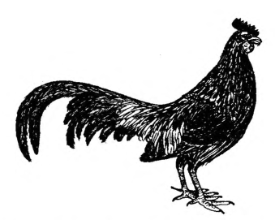

**Figure 6.1:** *Gallus gallus*, Red Jungle Fowl

| **PMP** |  | *manuk | ‘bird, fowl’ |
| --- | --- | --- | --- |
| **POc** |  | *manuk | ‘Red Jungle-fowl, *Gallus gallus*’ |
| Yap | Yapese | *ni-mēn* |  |
| NNG | Manam | *maŋ* | ‘bird, chicken’ |
| NNG | Mangap | *man* |  |
| SV | Kwamera | *menu* | ‘bird, prototypically fowl’ |
| SV | Lenakel | *menuk* |  |
| Mic | Carolinian | *malix* | (loan from Palauan) |
| Mic | Namoluk | *malok* | (loan from Palauan) |
| Mic | Ponapean | *malek(enwel)* | (loan from Palauan) |

Note that Bender et al. (2003:327) consider the Micronesian forms to be loans from Chamorro *mannok* ‘chicken’.

| **POc** |  | *kokorako | ‘fowl, *Gallus gallus*, esp. male’ |
| --- | --- | --- | --- |
| Adm | Loniu | *kɔha* |  |
| Adm | Nyindrou | *kakaro (mʷan)* | ‘rooster’ |
| NNG | Labu | *kakaru* |  |
| NNG | North Watut | *kokora* |  |
| NNG | Bariai | *kokako* |  |
| NNG | Kove | *kok(o)ako, kahako* |  |
| NNG | Lusi | *kok(o)ako* |  |
| NNG | Takia | *kirek* |  |
| NNG | Kilenge | *koako* |  |
| NNG | Mouk | *kuako* |  |
| NNG | Lamogai | *kuako* |  |
| NNG | Poeng | *kukulega* | ‘bird similar to chicken’ |
| PT | Bwaidoga | *kakaleko, kakeliko* | ‘the domestic fowl’ |
| PT | Are | *kokorereko* |  |
| PT | Wedau | *kokorereko* | ‘rooster’ |
| PT | Kilivila | *rekorekʷa* |  |
| PT | Muyuw | *kalkólek, lekólek* |  |
| PT | Bartie Bay | *kokorereko* |  |
| PT | Hula | *kokoroku* |  |
| PT | Mekeo | *ʔoʔolo* |  |
| PT | Motu | *kokoroku* |  |
| MM | Nakanai | *kureko* |  |
| MM | Tolai | *kəkaruk, karegi, kareki* |  |
| MM | Petats | *kekeleau* |  |
| MM | Mono-Alu | *kokolei* |  |
| MM | Babatana | *kokorako* | ‘rooster’ |
| MM | Nduke | *kokorako* |  |
| MM | Roviana | *kokorako* |  |
| MM | Simbo | *kokorako* |  |
| MM | Maringe | *kʰokorako* |  |
| SES | Bugotu | *kokiroko* | ‘cock; to crow’ |
| SES | Longgu | *kokoroko* | ‘rooster’ |
| SES | To’aba’ita | *kūkua* |  |
| SES | Lau | *karaikoa, kakara i koa* |  |
| SES | Langalanga | *kakaraikua* |  |
| SES | ’Are’are | *kua, kukua, kuakua* |  |
| SES | Kwara’ae | *karai* |  |
| SES | Kwaio | *kokorako* |  |
| SES | Kwai | *kakarai* |  |
| SES | Sa’a | *kue* |  |
| Mic | Sonsorolese | *gɔgɔ, kɔkɔ* |  |

The possible Polynesian reflex of the third term has undergone a significant semantic shift.

| **POc** |  | *toqa | ‘fowl’ |
| --- | --- | --- | --- |
| NNG | Kairiru | *(mʸan) tok* | ‘fowl’ (*mʸan* ‘bird’) |
| MM | Teop | *toa* | ‘small water fowl’ |
| NCV | Mota | *toa* |  |
| NCV | Lakon | *tɔ* |  |
| NCV | Raga | *toa* |  |
| NCV | Matantas | *na-toa* |  |
| NCV | Kiai | *toa* |  |
| NCV | Atchin | *na-tò* |  |
| NCV | Neve’ei | *no-to* |  |
| NCV | Avava | *oto* |  |
| NCV | Big Nambas | *n-tu, ni-tū* |  |
| NCV | Nese | *na-to* |  |
| NCV | Labo | *ne-te* |  |
| NCV | Southwest Bay | *ne-teu* |  |
| NCV | Naha’ai (Malfaxal) | *nö-to* |  |
| NCV | Southeast Ambrym | *tuto* |  |
| NCV | Paamese | *(a)to* |  |
| NCV | Lewo | *towa* |  |
| NCV | Nguna | *tōa* |  |
| SV | Ura | *urwa* |  |
| SV | Sye | *ne-two* |  |
| NCal | Nêlêmwâ | *ko* |  |
| NCal | Caac | *ho, jo* |  |
| NCal | Jawe | *ho* |  |
| NCal | Cèmuhî | *jà* |  |
| NCal | Paicî | *ja* |  |
| NCal | Xârâcùù | *dö* |  |
| NCal | Drubea | *tá* |  |
| NCal | Iaai | *xoto* |  |
| NCal | Dehu | *gutu* |  |
| NCal | Nengone | *titewɛ* |  |
| Fij | Bauan | *toa* |  |
| Pn | Tongan | *toʔa* | ‘courageous, hero, strong man’ |
| Pn | East Futunan | *(moa)toʔa* | ‘cock’ |
| Pn | Tikopia | *toa* | ‘strong man, warrior, fighting spirit’ |
| Pn | Marquesan | *toa* | ‘brave, strong, warrior; male’ |

The common Polynesian word for the fowl has no certain external cognates, though it has apparently been borrowed rather far afield. However, it is possible that Wayan and Bauan *mō* are cognate with PPn *moa, as PCP *oa often becomes *ō*, at least in Western Fijian. If they are, then PCP *moa is reconstructable, but with uncertain denotation.

| **PPn** |  | *moa | ‘fowl’ |
| --- | --- | --- | --- |
| Pn | Tongan | *moa* |  |
| Pn | Niuean | *moa* |  |
| Pn | East Futunan | *moa* |  |
| Pn | Samoan | *moa* |  |
| Pn | Tuvalu | *moa* |  |
| Pn | Nukuoro | *moa* | ‘bird sp.’ |
| Pn | Tahitian | *moa* |  |
| Pn | Rarotongan | *moa* |  |
| Pn | Māori | *moa* | ‘Moa (Dinornis) and other extinct spp.’ |

cf. also: Possible borrowings from Polynesian include:

| Yap | Yapese | *moeʔ* |  |
| --- | --- | --- | --- |
| NCal | Ajië | *meyɛ* |  |
| NCal | Tinrin | *meɔ* |  |
| Mic | Kiribatese | *moa* |  |
| Fij | Wayan | *mō* | ‘rail sp., probably *Porzana tabuensis*’ |
| Fij | Bauan | *mō* | ‘Sooty Crake, *Porzana tabuensis*’ |
| Fij | Rotuman | *moa* |  |

A common observation about animal taxonomy is that terminology for domesticated species will be more detailed than for most wild species—specific names for sexes, ages and varieties are to be expected. This does not seem to be the case for the fowl in Proto Oceanic.

One term, reconstructed as PMP _*qup_a ‘hen, egg-laying chicken’, appears to have Oceanic reflexes only in Polynesian and Rotuman (the latter a borrowing):

| **PMP** |  | *qupa | ‘hen, egg-laying chicken’ (ACD) |
| --- | --- | --- | --- |
| **POc** |  | *qupa | ‘hen’ |
| Pn | East Futunan | *ʔufa* | ‘young hen, pullet’ |
| Pn | Rapanui | *uha* | ‘hen; female of animals’ |

cf. also:

| Fij | Rotuman | *ʔufa* | (borrowed from Polynesian source) |
| --- | --- | --- | --- |

The male of the species is most commonly simply denoted by ‘male fowl’ (Manam *maŋ moane*, Motu *kokoruku maruanena*,’Are’are *kua mane*), and chicks as ‘child of fowl’ (Motu *kokoroku natuna*, Cemuhi *nahi-ja*, Bauan *luve ni toa*).

## 5. Non-passerine land and fresh water birds

Though in species numbers they are roughly a third of the total, this group of families accounts for well over half the cognate sets and reconstructions presented here. Land birds are likely to be seen by everyone in the community, and not just those who go to sea. The non-passerines are on the whole larger and more conspicuous than the passerines. They are therefore likely to have names known by everyone. They are also objectively more diverse as a group, and hence more likely to be recognised and lexicalised (Boster, Berlin & O’Neill 1986: 577-578).

### 5.1. Cassowaries (Casuariidae)

A single species of this family of huge flightless birds, the Dwarf Cassowary (*Casuarius bennetti*), lives in the Oceanic homeland. Although cassowaries do not extend even into the Solomons, enough reflexes exist in languages of the NNG, PT and MM groups to support the reconstruction below. Attribution of such a form to POc is further supported by numerous cognates in languages to the west, e.g. Biak (SHWNG) *(man)swar*, Kaiwai (CMP) *asawar* (Anceaux 1961).

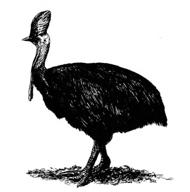

**Figure 6.2:** *Casuarius bennetti*, Dwarf Cassowary

[output not shown]

### 5.2. Herons (Ardeidae)

The herons of the homeland include three species of large herons or egrets of the genus Egretta as well as the Green-backed Heron (*Butorides striatus*), the Nankeen Night Heron (*Nycticorax caledonicus*) and two bitterns (*Ixobrychus* spp.). Most cognate sets refer to the large and conspicuous *Egretta* herons, which may have been the basis for a generic term.

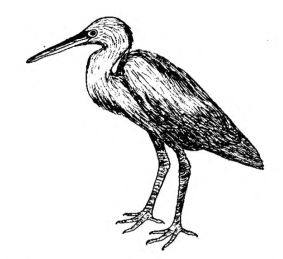

**Figure 6.3:** *Egretta sacra*. Reef Heron

| **POc** |  | *kao(i) | ‘heron, probably *Egretta* sp.’ |
| --- | --- | --- | --- |
| Yap | Yapese | *ʔkãw, ʔkow* | ‘heron’ |
| Adm | Nyindrou | *kaoi* | ‘heron’ |
| NNG | Poeng | *gao* | ‘reef heron’ |
| PT | Gapapaiwa | *kou* | ‘Reef Heron, *Egretta sacra*’ |
| MM | Patpatar | *kou* | ‘rufous night heron’ |
| MM | Sursurunga | *kau* | ‘taxon including Zebra Heron and Nankeen Night Heron’ |
| MM | Halia | *koei* | ‘crane’ |
| MM | Halia | *ko-koyei* | ‘*Egretta sacra*’ |
| MM | Banoni | *koko* | ‘*Egretta sacra* (dark morph)’ |
| MM | Nduke | *kou* | ‘Great Egret, *Egretta alba*’ |
| MM | Simbo | *kau* | ‘bird sp. similar to crane’ |
| SES | Longgu | *ʔao* | ‘reef heron’ |
| SES | ’Are’are | *ao* | ‘black heron’ |
| SES | ’Are’are | *ao eke* | ‘white heron’ |
| SES | Uki ni Masi | *ɣao* | ‘*Egretta sacra*’ |
| Mic | Sonsorolese | *ɣa-ɣaɔ(t)* | ‘heron’ |
| Mic | Trukese | *kawakaw* | ‘heron (general name)’ |
| Mic | Ponapean | *kowe(lik)* | ‘heron-like bird sp.’ |
| Fij | Bauan | *(visa)kō* | ‘Green-backed Heron, *Butorides striatus*’ |
| Pn | Nukuoro | *kava* | ‘*Egretta sacra*’ |
| Pn | Takuu | *kao* | ‘small thin wading bird resembling a heron’ |
| Pn | Tikopia | *keo* | ‘*Egretta sacra*’ |
| Pn | Māori | *kao(riki)* | ‘Little Bittern, *Ixobrychus minutus*’ |

It appears that *kao may have been a generic term for herons in PCP. Both Fijian and Polynesian introduce new terms (see below) for *Egretta*, and *kao mainly survives in reference to less conspicuous species. Among Central Pacific reflexes only the Takuu and Maori reflexes may be considered unproblematic. The Nukuoro word is probably borrowed from a Micronesian language.

| **POc** |  | *kaopa | ‘heron, probably *Egretta* sp.’ |
| --- | --- | --- | --- |
| Adm | Drehet | *kɔp* | ‘heron sp.’ |
| SES | Gela | *kaova* | ‘egret’ |
| SES | Tolo | *haova* | ‘a long-legged, long-necked coastal bird’ |
| SES | Arosi | *kaopʷa* | ‘egret’ |
| SES | Bauro | *ɣaoha* | ‘Reef Heron, *Egretta sacra*’ |
| NCV | Mota | *kaova* | ‘an egret, herodias’ |
| NCV | Southeast Ambrym | *koh* | ‘*Egretta sacra*’ |
| NCal | Nêlêmwâ | *kõõk, kõõva* | ‘*Egretta sacra*’ |
| NCal | Fwai | *kõõva* | ‘*Egretta sacra*’ |
| NCal | Paicî | *kɔɔ* | ‘*Egretta sacra*’ |
| NCal | Xârâcùù | *kaūkʷa* | ‘white heron sp.’ |
| NCal | Xârâcùù | *gɔkɔɔ* | ‘*Egretta sacra*’ |
| Pn | Rennellese | *ɣou* | ‘Black Bittern, *Ixobrychus flavicollis*’ |
| Pn | Pileni | *kova* | ‘heron, egret’ |

Both Polynesian Outlier names are presumably borrowed from SE Solomonic languages.

| TM | Buma | *ove(ne)* | ‘Reef Heron, *Egretta sacra*’ |
| --- | --- | --- | --- |

| **PNCV** |  | *qova | ‘heron, probably *Egretta* sp.’ |
| --- | --- | --- | --- |
| NCV | Raga | *ova* | ‘*Egretta sacra* (dark phase)’ |
| NCV | Kiai | *ova* | ‘heron’ |
| NCV | Lewo | *yeva* | ‘heron’ |
| NCV | Namakir | *ʔov* | ‘reef heron’ |
| NCV | North Efate | *ōva* | ‘reef heron (dark phase)’ |

The relation among the three cognate sets above is not entirely clear. The ordering is based on their successively narrower distribution, from which one might conjecture that *kao was the original POc term, *kaopa an extension of this, and *qopa a truncation of *kaopa restricted to North-Central Vanuatu and its immediate neighbour Temotu area. The above cognate complex is almost unrepresented in the Papuan Tip group, which seems to replace it with the following:

| **PPT** |  | *boqe | ‘heron, *Egretta* sp.’ |
| --- | --- | --- | --- |
| PT | Tubetube | *boi* | ‘reef heron’ |
| PT | Wagawaga | *boi* | ‘Reef Heron, *Egretta sacra*’ |
| PT | Iduna | *foi* | ‘Intermediate Egret, *Egretta intermedia*’ |
| PT | Kilivila | *boi* | ‘heron’ |
| PT | Muyuw | *bouy* | ‘white crane’ |
| PT | Balawaia | *boge* | ‘white heron’ |
| PT | Hula | *poge* | ‘heron’ |
| PT | Lala | *boe* | ‘heron’ |
| PT | Mekeo | *foe* | ‘heron, egret’ |

Two of the identifications below are problematic: the Pied Heron, *Egretta picata*, is a mainland species not known to occur in the Bismarcks, and the Grey Heron, *Ardea cinerea*, does not occur in the New Guinea area at all.

| **POc** |  | *bʷaro | ‘heron, probably *Egretta* sp.’ |
| --- | --- | --- | --- |
| NNG | Yabem | *bʷalɔʔ* | ‘heron’ |
| NNG | Bing | *buar-buar* | ‘Pied Heron, *Egretta picata*’ |
| NNG | Dami | *bar* | ‘heron’ |
| NNG | Gedaged | *(ma)boɬ* | ‘Grey Heron, *Ardea cinerea*’ |
| PT | Motu | *baira* | ‘pure white heron’ |
| MM | Patpatar | *bol* | ‘great egret’ |
| MM | Ramoaaina | *bar* | ‘Reef Heron, *Egretta sacra*’ |
| SES | Longgu | *(koivo) baro* | ‘white heron sp.’ |
| NCV | Neve’ei | *no-bol (yevyev)* | ‘reef heron’ |

cf. also:

| Fij | Rotuman | *pelō* | ‘*Egretta sacra*’ |
| --- | --- | --- | --- |
| Fij | Bauan | *belō* | ‘*Egretta sacra*’ |

A more localised group of cognates in Vanuatu show some resemblance to the above:

| **PSV** |  | *bʷan(ie) | ‘heron’ (Lynch) |
| --- | --- | --- | --- |
| SV | Ura | *(yaɣ)pon* | ‘egret’ |
| SV | Sye | *(yaɣ)pon* | ‘egret’ |
| SV | Kwamera | *pan* | ‘Reef Heron, *Egretta sacra*’ |
| SV | Lenakel | *pʷan* | ‘crane’ |
| SV | Anejom̃ | *n-pʷañ* | ‘*Ardea* spp.’ (sc. Egretta) |

cf. also:

| NCV | Letemboi | *na-liᵐbanua* | ‘heron’ |
| --- | --- | --- | --- |
| NCV | Labo | *nə-ᵐbunuoj* | ‘heron’ |
| NCV | Southwest Bay | *(li)ᵐbanui* | ‘heron’ |

Additional clear but highly localised names in the Solomons, Micronesia and Polynesia also centre around *Egretta*. POc *sou below is suspect as a POc reconstruction as it only occurs in the Solomons. However, Numbami (NNG) *saole* ‘egret’ may be cognate. If it is, then the POc form was perhaps *saol or *saul, but this in turn leaves Numbami final *-e* for expected †*-a* unaccounted for, as well as the lack of the final consonant and echo vowel from expected Marovo †*coulu* Nduke †*houlu*.

| **POc** |  | *sou | ‘heron’ |
| --- | --- | --- | --- |
| MM | Torau | *sou* | ‘Reef Heron, *Egretta sacra*’ |
| MM | Marovo | *cou* | ‘*Egretta sacra*’ |
| MM | Nduke | *hou* | ‘*Egretta sacra*’ |
| SES | Gela | *sou* | ‘heron’ |
| SES | Tolo | *cou* | ‘bird sp.’ |
| SES | Malango | *cou* | ‘Nankeen Night Heron, *Nycticorax caledonicus*’ |
| SES | Longgu | *sou* | ‘heron’ |
| SES | Lau | *tou* | ‘crane’ |
| SES | Kwaio | *tou* | ‘egret’ |
| SES | ’Are’are | *tou* | ‘night heron’ |
| SES | Sa’a | *tou* | ‘night heron’ |

| **Proto Central Micronesian** |  | *karau | ‘*Egretta sacra*’ (Bender et al. 2003) |
| --- | --- | --- | --- |
| Mic | Kiribatese | *kāi* | ‘*Egretta sacra*’ |
| Mic | Marshallese | *kɛkɛ* | ‘reef heron (white phase)’ |
| Mic | Mokilese | *kɔrɔ* | ‘reef heron’ |
| Mic | Sonsorolese | *ɣaɣai(cɔr)* | ‘black heron’ |
| Mic | Namoluk | *örö* | ‘Reef Heron, *Egretta sacra*’ |
| **PChk** |  | *karaɨ | ‘heron’ |
| Mic | Puluwatese | *yœre(n)* | ‘heron’ |
| Mic | Woleaian | *gerœ* | ‘bird sp. with long neck’ |
| Mic | Trukese | *ʌrʌ* | ‘heron’ |

cf. also:

| Pn | Rennellese | *kagau* | ‘*Egretta sacra*’ |
| --- | --- | --- | --- |

The Rennellese term seems to agree with the Central Micronesian reconstruction, but borrowing from this direction would be unexpected. No heron terms like this appear to exist in the Southeast Solomons.

| **PPn** |  | *matuku | ‘Reef Heron, *Egretta sacra*’ |
| --- | --- | --- | --- |
| Pn | Tongan | *motuku* |  |
| Pn | Niuean | *motuku* |  |
| Pn | East Futunan | *amatuku* |  |
| Pn | Samoan | *matuʔu* |  |
| Pn | Tuvalu | *matuku* |  |
| Pn | Kapingamarangi | *matuku* |  |
| Pn | Takuu | *matuku* |  |
| Pn | Sikaiana | *motuku* |  |
| Pn | Ifira-Mele | *matuku(tea)* | ‘white heron’ (*tea* ‘white’) |
| Pn | Pukapukan | *matiku* |  |
| Pn | Marquesan | *matuku* |  |
| Pn | Rarotongan | *mātuku* | ‘a small dark-grey heron which frequents the seashore’ (Savage) |
| Pn | Māori | *matuku* | ‘*Egretta sacra* and other heron spp.’ |

cf. also: Compare, with unexpected referents:

| Pn | Niuean | *motuku* | ‘Bristle-thighed Curlew, *Numenius tahitiensis*’ |
| --- | --- | --- | --- |
| Pn | Rennellese | *matuku* | ‘a kind of *gupe* pigeon, perhaps the female’ |

| **PCEPn** |  | *kautuku~kootuku | ‘heron sp.’ |
| --- | --- | --- | --- |
| Pn | Hawaiian | *ʔaukuʔu* | ‘Black-crowned Night Heron, *Nycticorax nycticorax*’ |
| Pn | Mangareva | *kotuku* | ‘Reef Heron, *Egretta sacra*’ |
| Pn | Tahitian | *ʔōtuʔu* | ‘*Egretta sacra*’ |
| Pn | Rarotongan | *kōtuku* | ‘*Egretta sacra*’ |
| Pn | Māori | *kōtuku* | ‘Great Egret, *Egretta alba*’ |
| Pn | Māori | *kautuku* | ‘Australian Bittern, *Botaurus poiciloptilus*’ |

The East Polynesian forms prefixed with *kō- fall into a large class of nouns so reshaped in this subgroup. However, the Hawaiian and Maori terms with *kau- suggest the possibility of influence of the *kao term reconstructed above.

Compared with extensive cognate sets for the Egretta herons, only two small sets appear to denote the Night Herons:

| **POc** |  | *ŋako | ‘Night Heron, *Nycticorax* sp.’ |
| --- | --- | --- | --- |
| Adm | Loniu | *ñako* | ‘bird sp., sings at night, heralds death, possibly night heron or curlew’ |
| NNG | Musom | *ŋoku(ᵐbuŋ)* | ‘gray or black heron’ |
| NNG | North Watut | *ŋako(tof)* | ‘crane’ |
| PT | Motu | *noko* | ‘heron’ |

| **PNCal** |  | *tila | ‘night heron, *Nycticorax* sp.’ |
| --- | --- | --- | --- |
| NCal | Nêlêmwâ | *rʰẽlã* | ‘Nankeen Night Heron, *Nycticorax caledonicus*’ |
| NCal | Ajië | *sira* | ‘mangrove heron’ |
| NCal | Tinrin | *ṭĩrã* | ‘grey night heron’ |
| NCal | Xârâcùù | *sĩrã* | ‘*Nycticorax caledonicus*’ |

### 5.3. Ducks (Anatidae)

The Pacific Black Duck (*Anas superciliosa*) is the most common duck of the Oceanic region, but the Grey Teal (*Anas gibberifrons*) is also present in the homeland, as are two species of Whistling Ducks (*Dendrocygna* spp.), and various other species of this family are known as migrants. There is no evidence of domestication of any duck species in pre-European Oceania. Many languages use a separate lexical item for the introduced domesticates, as Samoan *pato* ‘domestic duck’ (from Spanish), *toloa* ‘wild duck’. Very few descriptions offer glosses more precise than ‘duck’ or ‘wild duck’. However, Iduna *geluluva* is explicitly stated to cover both species of Anas mentioned above, and Nelemwa *kerorōp* includes both these as well as the Mallard, *Anas platyrhynchos*). There may be a terminological agreement between Caaac and Fijian (Lomaivitilevu) in which the Whistling Duck is described as ‘red duck’ (Caaac *nīaŋ mīa*, Fijian *gā-damu*).

| **PMP** |  | *ŋaRaq | ‘wild duck’ (Blust 2002) |
| --- | --- | --- | --- |
| **POc** |  | *ŋaRa | ‘duck’ |
| Adm | Loniu | *ŋay* | ‘bird sp., floats on surface of water, possibly duck or booby’ |
| Adm | Nyindrou | *ña* | ‘duck; shag’ |
| PT | Wedau | *ŋara* | ‘duck; shag’ |
| MM | Banoni | *nāra(ka)* | ‘Pacific Black Duck, *Anas superciliosa*’ |
| MM | Torau | *nara* | ‘*Anas superciliosa*’ |
| MM | Roviana | *ŋara* | ‘wild duck’ |
| SES | Uki ni Masi | *(ʔa)ŋara* |  |
| SES | Arosi | *(ka)ŋara* |  |
| SES | Arosi | *ŋara (i suʔu)* | (*suʔu* ‘lake, swamp’) |
| SV | Anejom̃ | *n-ŋa* | ‘possibly *Porphyrio* sp.’ (John Lynch, pers. comm.) |
| SV | Anejom̃ | *ŋar(ohos)* | ‘possibly *Porphyrio* sp.’ (John Lynch, pers. comm.) |
| **PMic** |  | *ŋāŋā | ‘sea bird, duck’ |
| Mic | Carolinian | *ŋāŋa* | [^5] |
| Mic | Satawalese | *ŋāŋa* |  |
| Mic | Woleaian | *ŋāŋā* |  |
| Fij | Bauan | *ŋā* |  |

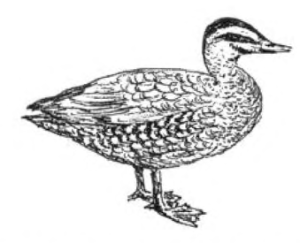

**Figure 6.4:** *Anas superciliosa*, Pacific Black Duck

The following possible Maori reflex refers to a different waterfowl, but the formal development would be regular. (The grebe is presently found only in the South Island, where Maori *ŋ > *k*.

| Pn | Māori | *kā(mana)* | ‘Great Crested Grebe, *Podiceps cristatus*’ |
| --- | --- | --- | --- |

The following reconstruction is a metathetic variant of the above, apparently a local development in SE Solomonic and Micronesian.

| **PEOc** |  | *Raŋa | ‘duck’ |
| --- | --- | --- | --- |
| SES | Gela | *(ɣaɣa)raŋa* | ‘a duck’ |
| SES | Tolo | *(ha)raŋa* | ‘wild duck’ |
| SES | To’aba’ita | *(ʔāʔa)raŋa* |  |
| SES | Kwaio | *(ʔaʔa)laŋa* | ‘Pacific Black Duck, *Anas superciliosa*’ |
| SES | ’Are’are | *(araʔa)rana* | ‘wild duck’ |
| SES | Sa’a | *araŋa* | ‘wild duck’ |
| Mic | Namoluk | *raŋ* | ‘Spotbill Duck, *Anas poecilorhyncha*’ |
| Mic | Marshallese | *ṛᵚaŋ* | ‘wild duck’ |
| Mic | Marshallese | *ṛᵚoŋa(npat)* | ‘*Anas* spp.’ (*pat* ‘swamp’) |

cf. also: Probably borrowed from a SE Solomonic language:

| MM | Marovo | *araŋa* | ‘*Anas superciliosa*’ |
| --- | --- | --- | --- |

A final local development of this same group, again with metathesis:

| **Proto South Melanesian** |  | *l(i)aŋ | ‘duck’ (Lynch)[^6] |
| --- | --- | --- | --- |
| SV | Kwamera | *ia-réŋ* | ‘duck (indigenous)’ |
| NCal | Caac | *nīaŋ* | ‘duck’ |
| NCal | Tinrin | *nĩã* | ‘duck’ |
| NCal | Xârâcùù | *nĩã* | ‘*Anas* spp.’ |
| NCal | Iaai | *eŋ* | ‘duck’ |

PPn *toloa replaces *ŋaRa as the generic term for ‘duck’.

| **PPn** |  | *toloa | ‘duck’ |
| --- | --- | --- | --- |
| Pn | Tongan | *toloa* | ‘Pacific Black Duck, *Anas superciliosa*’ |
| Pn | East Futunan | *toloa* | ‘Spotbill Duck, *Anas poecilorhyncha*’ |
| Pn | Samoan | *toloa* | ‘*Anas superciliosa*’ |
| Pn | Tokelauan | *toloa* | ‘*Anas superciliosa*’ |
| Pn | Tuvalu | *toloa* | ‘Mallard, *Anas platyrhynchos*, and Northern Shoveller, *Anas clypeata*’ |
| Pn | Pukapukan | *toloa* | ‘*Anas superciliosa*’ |
| Pn | Kapingamarangi | *tolō* | ‘duck sp.’ |
| Pn | Tikopia | *toroa* | ‘*Anas superciliosa*’ |
| Pn | Anutan | *toroa* | ‘duck’ |
| Pn | West Uvean | *toloa* | ‘*Anas superciliosa*’ |
| Pn | Hawaiian | *koloa* | ‘*Anas* spp.’ |

cf. also: A probable Polynesian borrowing:

| TM | Buma | *teloloa* | ‘*Anas superciliosa*’ |
| --- | --- | --- | --- |

A number of other Polynesian and Fijian languages have bird names formally cognate with the above, but referring to shore and sea birds. (A number of these innovations are in the languages of atolls, where ducks are rare or non-occurrent owing to the absence of surface fresh water.):

| Fij | Kadavu | *torō, tarō* | ‘*Sula* spp.’ |
| --- | --- | --- | --- |
| Fij | Wayan | *torō* | ‘probably Frigatebird, *Fregata* spp.’ |
| Pn | Nukuria | *koroa* | ‘Whimbrel, *Numenius phaeopus*’ |
| Pn | Takuu | *taroa* | ‘*Numenius phaeopus*’ |
| Pn | Luangiua | *kaloa(kule)* | ‘Bar-tailed Godwit, *Limosa lapponica*’ |
| Pn | Sikaiana | *toloa* | ‘*Numenius phaeopus*, *Limosa lapponica*’ |
| Pn | Rennellese | *togoa* | ‘Great Egret, *Egretta alba*’ |
| Pn | Tuamotuan | *toroa* | ‘booby, *Sula* sp.’ |
| Pn | Rarotongan | *toroa* | ‘booby, *Sula* spp.’ |
| Pn | Māori | *toroa* | ‘albatross, *Diomedea* spp.’ |

| **Proto Tahitic** |  | *mokolā | ‘duck’ |
| --- | --- | --- | --- |
| Pn | Tahitian | *moʔorā* | ‘Pacific Black Duck, *Anas superciliosa*’ |
| Pn | Manihiki | *rāmoko* | ‘wild duck sp.’ |
| Pn | Rarotongan | *mokorā* | ‘duck’ |

Maori applies formally cognate terms to two quite different species:

| Pn | Māori | *mokorā* | ‘New Zealand Robin, *Petroica australis* (female)’ |
| --- | --- | --- | --- |
| Pn | Māori | *makorā* | ‘Silver Gull, *Larus novaehollandiae*’ |

A strikingly resemblant form occurs in Motu. The only known source of Polynesian loanwords here would be 19th century missionaries from the Cook Islands, but it seems odd to have a wild species named in this way.

| PT | Motu | *mokoraha* | ‘Wandering Whistling Duck, *Dendrocygna arcuata*’ |
| --- | --- | --- | --- |

### 5.4. Diurnal raptors (Pandionidae, Accipitridae, Falconidae)

These three families are treated together because of obvious similarities in appearance and habits, as well as overlap in naming practices. They are well represented in the homeland, with at least ten species. Roughly from largest to smallest, they include the White-bellied Sea Eagle (*Haliaeetus leucogaster*), the Osprey (*Pandion haliaetus*), several goshawks of genus Accipiter, the Brahminy Kite (*Haliastur indus*), the Black Honey Buzzard (*Henicopernis infuscata*), the Crested Baza (*Aviceda subcristata*), and probably both the Peregrine Falcon (*Falco peregrinus*) and the Oriental Hobby (*Falco severus*).

A very large number of terms for birds of prey are recorded, from which a number of cognate sets emerge; however, associating particular names with particular species is much more difficult, owing in large part to vague descriptions which use ‘hawk’ or ‘eagle’ to refer to any bird of prey.

#### 5.4.1. Fish-eating raptors (*Pandion*, *Haliaeetus*, *Haliastur*)

Perhaps because of their size alone, these species provide some of the best POc reconstructions. The following set may represent a generic term:

| **POc** |  | *taragau | ‘fish-eating eagle or hawk’ |
| --- | --- | --- | --- |
| NNG | Kairiru | *tarakʸau, tirakʸau* | ‘hawk/eagle’ |
| NNG | Manam | *taragau* | ‘fish-eagle’ |
| MM | Patpatar | *taragau* | ‘Whistling Kite, *Haliastur sphenurus*’ |
| MM | Tolai | *taragau* | ‘Osprey, *Pandion haliaetus*’ |
| SES | Malango | *taragau* | ‘*Pandion haliaetus*’ |
| SES | Kwara’ae | *alafau* | ‘hawk not very big, steals chickens and other birds food’ |
| SES | Kwaio | *alagau* | ‘White Goshawk, *Accipiter novaehollandiae*’ |
| SES | Sa’a | *arakau* | ‘Brahminy Kite, *Haliastur indus*’ |
| SES | Arosi | *aragau* | ‘*Haliastur indus*’ |

cf. also:

| MM | Nehan | *targau* | ‘Red-footed Booby, *Sula sula*’ |
| --- | --- | --- | --- |

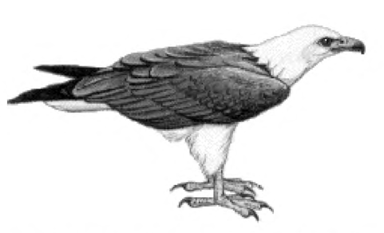

**Figure 6.5:** *Haliaeetus leucogaster*, White-bellied Sea Eagle

The fish-eagle (Haliaeetus) was probably the largest flying creature known to the Proto Oceanic speakers. (*Haliaeetus leucogaster* of the homeland is replaced in the Solomons by the very similar *Haliaeetus sanfordi*.) So it is not surprising to find terms for this species literally meaning ‘big bird’ in a number of languages. In all but one of the following, the first element reflects POc *manuk ‘bird’, and the second is the local word for ‘big’. These second elements are etymologically diverse, but Patpatar, Nehan and Puluwatese probably retain the POc form *lapuat ‘large’ (vol.2:190-191).

| **POc** |  | *manuk-lapuat | ‘White-bellied Sea Eagle, *Haliaeetus leucogaster*’ |
| --- | --- | --- | --- |
| PT | Bartie Bay | *manu-bada* | ‘sea hawk’ |
| PT | Are | *manu-bada* | ‘fish hawk’ |
| PT | Wedau | *manu-bada* | ‘fish hawk’ |
| MM | Patpatar | *malaba* | ‘eagle (black and white)’ |
| MM | Nehan | *manu-lab* | ‘*Haliaeetus leucogaster* or Osprey, *Pandion haliaetus*’ |
| SES | Bugotu | *manu hutu* | ‘eagle’ |
| SES | Gela | *manu-kama* | ‘a hawk, eagle’ |
| SES | Gae | *manu-loki* | ‘eagle’ |
| SES | To’aba’ita | *noʔo baʔita* | ‘eagle sp.’ |
| TM | Vano | *menuka pʷene* | ‘eagle’ |
| Fij | Bauan | *manu-levu* | ‘Pacific Marsh Harrier, *Circus approximans*’ |

The following is formally connected, but from an area with no eagles—perhaps still referring to the largest bird in the area:

| Mic | Puluwatese | *mallap* | ‘frigate bird’ |
| --- | --- | --- | --- |

Two other sets are derived from the bird generic *manuk, though the second element is less easy to identify.

| **POc** |  | *manuka | ‘sea eagle’ (Blust 2002) |
| --- | --- | --- | --- |
| Yap | Yapese | *manuw* | ‘eagle’ |
| MM | Halia | *manu* | ‘Sanford’s Sea Eagle, *Haliaeetus sanfordi*’ |
| MM | Petats | *manu* | ‘the very large fish-eagle’ |
| MM | Banoni | *manuka* | ‘*Haliaeetus sanfordi*’ |
| MM | Mono-Alu | *mānuʔa* | ‘eagle’ |
| MM | Roviana | *manuvu, manuɣu* | ‘a large grey fish-hawk’ |
| MM | Ughele | *manuɣu* | ‘eagle’ |
| Mic | Puluwatese | *mānuwa* | ‘legendary man-eating bird’ |
| Mic | Carolinian (Tanapag) | *mʷuluwa, manuwɔ* | ‘eagle, hawk’ |
| Mic | Trukese | *mərɨwo* | ‘a kind of sea eagle; a mythical bird, the flapping of whose wings makes a wind that topples trees’ |

| **PAdm** |  | *manu(w)ai | ‘sea eagle’ (Blust 2002) |
| --- | --- | --- | --- |
| Adm | Loniu | *mɛnuway* | ‘eagle’ |
| Adm | Nyindrou | *mañuwe* | ‘eagle’ |
| Adm | Titan | *manuai* | ‘Osprey, *Pandion haliaetus*’ |
| Adm | Baluan | *manuay* | ‘sea eagle’ |
| Adm | Lou | *menua* | ‘hawk, eagle’ |
| Adm | Wuvulu | *manua* | ‘sea eagle’ |

Though perhaps not so strongly identified with a particular species, the following also appears to refer to the largest raptors:

| **POc** |  | *bogi | ‘large bird of prey sp., possibly sea eagle’ |
| --- | --- | --- | --- |
| Adm | Titan | *poe(dilei)* | ‘large eagle’ |
| NNG | Gitua | *(man)bok* | ‘large eagle’ |
| NNG | Bariai | *bogi* | ‘sea eagle’ |
| NNG | Lusi | *voɣi* | ‘sea eagle’ |
| NNG | Malalamai | *bogi* | ‘small eagle’ |
| NNG | Gedaged | *bog* | ‘large predatory bird, fish eagle’ |
| NNG | Takia | *bog* | ‘eagle’ |
| NNG | Wab | *buog* | ‘large eagle’ |
| NNG | Roinji | *bok* | ‘small eagle’ |
| NNG | Aria | *bogi* | ‘sea eagle’ |
| PT | Lala | *boʔi(bata)* | ‘beach eagle’ |
| PT | Mekeo | *foi* | ‘large birds of prey more common near mountains’ |
| PT | Motu | *bogi(bada)* | ‘Black Kite, *Milvus migrans*’ (*bada* ‘big’) |

Further possible POc reconstructions for ‘eagles’ are:

| **POc** |  | *bʷaŋ | ‘sea eagle’ |
| --- | --- | --- | --- |
| Adm | Baluan | *(ŋa)puaŋ* | ‘brown bird, eats fish, similar to sea eagle but smaller’ |
| NNG | Yabem | *(mɔʔ)bʷaŋ* | ‘sea eagle’ (*mɔʔ* ‘bird’) |
| NNG | Mangap | *man-boŋ* | ‘eagle’ |

| **POc** |  | *roqa | ‘eagle’ |
| --- | --- | --- | --- |
| MM | Bola | *loɣa* | ‘eagle’ |
| MM | Nakanai | *loha(uru)* | ‘sea eagle’ (*uru* ‘big’) |
| SES | Malango | *roha* | ‘White Goshawk, *Accipiter novaehollandiae*’ |
| SES | Longgu | *aroha* | ‘eagle’ |

| **POc** |  | *maya | ‘Osprey, *Pandion haliaetus*’ |
| --- | --- | --- | --- |
| Adm | Titan | *maya* | ‘type of raptor’ |
| PT | Wedau | *mai(dunari)* |  |
| MM | Nakanai | *mãe* | ‘large hawk’ |

There are several further local reconstructions in the Solomons for these fish-eaters:

| **Proto Northwest Solomonic** |  | *katata~kakata | ‘sea eagle, *Haliaeetus*’ |
| --- | --- | --- | --- |
| MM | Nehan | *katkata(kubul)~tatate(kubul)* | ‘White-bellied Sea Eagle, *Haliaeetus leucogaster* (juvenile)’ |
| MM | Marovo | *kakaka* | ‘eagle’ |
| MM | Nduke | *tala* | ‘Sanford’s Sea Eagle, *Haliaeetus sanfordi*’ |
| MM | Roviana | *atāta* | ‘eagle’ |
| MM | Simbo | *kakaka* | ‘eagle’ |
| MM | Vangunu | *akaka* | ‘eagle’ |
| MM | Kokota | *kakade* | ‘eagle’ |
| MM | Maringe | *gaɣata* | ‘*Haliaeetus sanfordi*’ |

| **PSES** |  | *tava | ‘hawk or eagle’ (cf POc *tap(ʷ)a ‘glide, soar’ above) |
| --- | --- | --- | --- |
| SES | Gela | *tava* | ‘small hawk’ |
| SES | Malango | *tavo(kea)* | ‘Brahminy Kite, *Haliastur indus*’ |
| SES | To’aba’ita | *afa* | ‘eagle sp.’ |
| SES | Kwara’ae | *afa* | ‘eagle (largest of all birds)’ |
| SES | Kwaio | *afa* | ‘Sanford’s Sea Eagle, *Haliaeetus sanfordi*’ |
| SES | ’Are’are | *aha* | ‘sparrow-hawk, eagle’ |
| SES | Fataleka | *āfe* | ‘eagle’ |
| SES | Uki ni Masi | *hata(roŋa)* | ‘eagle’ |
| SES | Bauro | *aheta(roŋa)* | ‘eagle’ |

cf. also:

| Pn | Rennellese | *tava* | ‘Australian Goshawk, *Accipiter fasciatus*’ (borrowed from a SE Solomonic source) |
| --- | --- | --- | --- |

| **Proto Malaita-Makira** |  | *fada | ‘sea eagle, *Haliaeetus*’ |
| --- | --- | --- | --- |
| SES | Kwaio | *fada* | ‘eagle’ |
| SES | Dori’o | *fada* | ‘eagle’ |
| SES | ’Are’are | *hata* | ‘big brown eagle’ |
| SES | Sa’a | *hada* | ‘White-bellied Sea Eagle, *Haliaeetus leucogaster*’ |
| SES | Arosi | *hada* | ‘*Haliaeetus leucogaster*’ |

| **Proto Malaita-Makira** |  | *wakio | ‘Osprey, *Pandion haliaetus*’ |
| --- | --- | --- | --- |
| SES | To’aba’ita | *kʷakiʔo* | ‘fish eating raptor, probably osprey’ |
| SES | Lau | *kʷakio* |  |
| SES | Langalanga | *kʷagio* | ‘eagle’ |
| SES | ’Are’are | *wakio* | ‘fish hawk’ |
| SES | Sa’a | *wakio* |  |
| SES | Arosi | *wagio* |  |
| SES | Bauro | *wakio* |  |

The following may be cognate with PSOc *mala (§5.4.2 on p.303):

| **PNCal** |  | *bʷamara | ‘fishing bird of prey’ |
| --- | --- | --- | --- |
| NCal | Nêlêmwâ | *bʷaivada* | ‘Osprey, *Pandion haliaetus*’ |
| NCal | Jawe | *bʷaemada* | ‘Whistling Kite, *Haliastur sphenurus*’ |
| NCal | Pije | *bʷaepʰada* | ‘*Haliastur sphenurus*’ |
| NCal | Paicî | *bʷāmʌ̃ta* | ‘Pacific Marsh Harrier, *Circus approximans*’ |
| NCal | Ajië | *boamara* | ‘oiseau de proie, genre epervier’ |
| NCal | Tinrin | *bʷamera* | ‘*Pandion haliaetus*’ |
| NCal | Xârâcùù | *mʷãmara* | ‘*Pandion haliaetus*’ |
| NCal | Xârâcùù | *bʷamata* | ‘harrier sp.’ |

#### 5.4.2. Other raptors

The highly distinctive Crested Baza had an apparent POc name:

| **POc** |  | *ki(t,s)o | ‘Crested Baza, *Aviceda subcristata*’ |
| --- | --- | --- | --- |
| PT | Iduna | *kito* |  |
| MM | Patpatar | *kistou* |  |
| MM | Halia | *kitou* | ‘large bird (similar to the cockatoo and blue pigeon)’ |
| MM | Banoni | *kītou* |  |
| MM | Nduke | *pito* | ‘crested hawk, Baza guineyi’ |
| MM | Roviana | *pito* | ‘crested hawk, Baza guineyi’ |
| MM | Maringe | *kʰutu(reo)* | ‘Imitator Sparrow Hawk, *Accipiter imitator*’ (cf. *reʔo* ‘having hoarse, raspy voice’) |
| SES | Gela | *kito* | ‘very large bird sp.’ |
| SES | Malango | *kico* |  |
| SES | Longgu | *kito* | ‘crested hawk’ |
| SES | To’aba’ita | *ʔito* | ‘bush bird sp.’ |
| SES | Kwaio | *kito* | ‘bird sp.’ |
| SES | ’Are’are | *kiʔito* | ‘a hawk’ |
| SES | Sa’a | *kīto* |  |

cf. also:

| Fij | Wayan | *kītū* | ‘swamphen, *Porphyrio porphyrio*’ |
| --- | --- | --- | --- |

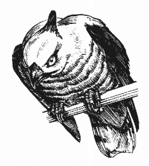

**Figure 6.6:** Aviceda subcrislata. Crested Baza

| **PNGOc** |  | *kisakisa | ‘hawk or eagle’ |
| --- | --- | --- | --- |
| NNG | Dami | *kisō* | ‘hawk’ |
| NNG | Gedaged | *kiskis* | ‘eagle sp., catches fish’ |
| PT | Tubetube | *kisakisa* | ‘a hawk’ |
| PT | Are | *kisakisa* | ‘hawk’ |
| PT | Kilivila | *kilakila* | ‘hawk’ |
| PT | Nimoa | *kisakisa* | ‘hawk’ |

cf. also:

| NNG | Adzera | *ŋasŋas* | ‘type of eagle’ |
| --- | --- | --- | --- |
| NNG | Takia | *ŋesaŋes* | ‘hawk’ |
| SES | Gela | *kisokiso* | ‘bird sp. in the forest’ |

The following three sets of terms have fairly wide geographical spread but they are not numerous or semantically consistent enough to justify a confident attribution to Proto Oceanic.

| **POc** |  | *luar | ‘eagle’ |
| --- | --- | --- | --- |
| MM | Tolai | *luər* | ‘large hawk sp.’ |
| MM | Petats | *loa* | ‘a hawk which is a little bigger and more tawny than the halalug’ |
| TM | Nebao | *nüœ* | ‘eagle’ |
| TM | Asumboa | *lio* | ‘eagle’ |
| TM | Tanibili | *(noño)luo* | ‘eagle’ |

| **POc** |  | *pʷa(r,R)a | ‘hawk’ |
| --- | --- | --- | --- |
| Adm | Mussau | *palē* | ‘hawk’ |
| NNG | Pasismanua | *pola* | ‘Brahminy Kite, *Haliastur indus*’[^7] |
| PT | Gapapaiwa | *bora* | ‘eagle (generic)’ |
| MM | Patpatar | *peres* | ‘*Haliastur indus*’ |
| MM | Roviana | *vari (ivu)* | ‘eagle sp.’ |
| TM | Vano | *na-vala* | ‘Pied Goshawk, *Accipiter albogularis*’ |
| NCV | Mota | *var-vara(mʷatika)* | ‘a kite that preys on the mʷatika [swamphen]’ |
| NCV | Kiai | *pa-para* | ‘Australian Goshawk, *Accipiter fasciatus*, or Peregrine Falcon, *Falco peregrinus*’ |
| NCV | Atchin | *(mato)war* | ‘a large species of hawk that sometimes kills fowls and rats’ |
| NCV | Southeast Ambrym | *vœ-vœ(hum)* | ‘Pacific Marsh Harrier, *Circus approximans*’ |
| NCV | Paamese | *vei-va(kume)* | ‘*Circus approximans*’ |
| NCV | Lewo | *pe-pa(uma)* | ‘hawk; eagle’ |
| Pn | Takuu | *pallā* | ‘large mythical bird of prey’ |

| **POc** |  | *ta(ou)k | ‘hawk, bird of prey’ |
| --- | --- | --- | --- |
| Adm | Mussau | *tao-taoko* | ‘sea eagle’ |
| NNG | Kaulong | *(ekiŋ) tau* | ‘hawk’ (*ekiŋ* ‘bird’) |
| MM | Tolai | *tauk(il)* | ‘Crested Baza, *Aviceda subcristata*’ |

Regionalisms for the smaller predators include:

| **PWOc** |  | *kipa | ‘hawk’ |
| --- | --- | --- | --- |
| PT | Balawaia | *kipa* | ‘carnivorous bird’ |
| PT | Motu | *kipa* | ‘hawk’ |
| MM | Maringe | *ki-kʰipa* | ‘White Goshawk, *Accipiter novaehollandiae*’ |

| **PWOc** |  | *kamʷaga | ‘eagle, hawk’ (cf. perhaps PMic *kemoa ‘booby’, §7.3) |
| --- | --- | --- | --- |
| PT | Balawaia | *ɣamoga* | ‘eagle’ |
| PT | Hula | *amoa* | ‘eagle hawk’ |
| MM | Babatana | *kamaga* | ‘hawk’ |

| **PPT** |  | *kitave | ‘hawk’ |
| --- | --- | --- | --- |
| PT | Wedau | *kita* | ‘kestrel’ |
| PT | Wedau | *kitave* | ‘hawk’ |
| PT | Bartie Bay | *kitave* | ‘hawk’ |
| PT | Mekeo | *afi* | ‘hawk’ |

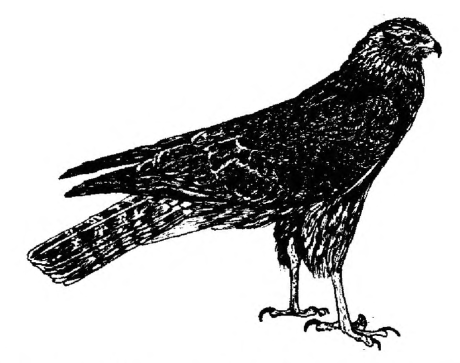

**Figure 6.7:** *Circus approximans*, Pacific Marsh Harrier

In Southern Oceania, the sea eagles are no longer present, and the familiar raptors are the goshawks (*Accipiter* spp.) and the Pacific Marsh Harrier (*Circus approximans*)

| **PSOc** |  | *mala | ‘hawk’ (John Lynch, pers. comm.) |
| --- | --- | --- | --- |
| NCV | Mota | *mala* | ‘hawk, kite, osprey’ |
| NCV | Lakon | *mal* | ‘Pacific Marsh Harrier, *Circus approximans*’ |
| NCV | Raga | *mala* | ‘*Circus approximans*’ |
| NCV | Raga | *mal-kal-bʷiru* | ‘Australian Goshawk, *Accipiter fasciatus*’ (*bʷiru* ‘Purple Swamphen, *Porphyrio porphyrio*’) |
| NCV | Matantas | *na-nala* | ‘*Circus approximans*’ |
| NCV | Sakao | *ne-anal* | ‘*Circus approximans*’ (Flux 1993) |
| NCV | Kiai | *mala* | ‘*Circus approximans*’ |
| NCV | Atchin | *ni-mal* | ‘kite’ |
| NCV | Namakir | *māl* | ‘red hawk’ |
| NCV | Nguna | *māla* | ‘hawk (brown back, white underneath)’ |
| SV | North Tanna | *maləkam* | ‘eagle’ |
| SV | Lenakel | *melkəm* | ‘eagle’ |
| SV | Anejom̃ | *in-mecɣapʷ* | ‘*Accipiter fasciatus*, *Circus approximans*’ |

cf. also: Borrowed from a North-Central Vanuatu language:

| Pn | Ifira-Mele | *mala* | ‘*Circus approximans*’ |
| --- | --- | --- | --- |
| Pn | Ifira-Mele | *mala-pʷēriki* | ‘Peregrine Falcon, *Falco peregrinus*’ |

The following could be an irregular development of *mala, the languages shown are all from Malakula, Vanuatu; however some of the Vanuatu reflexes of POc *pʷa(r,R)a ‘hawk’ above may belong here, being from languages in which *l and *R would both give zero in this environment.

| **Proto Central Vanuatu** |  | *bala | ‘Pacific Marsh Harrier, *Circus approximans*’ |
| --- | --- | --- | --- |
| NCV | Atchin | *ni-ᵐbel* | ‘hawk’ |
| NCV | Naman | *ne-bel* |  |
| NCV | Neve’ei | *ne-bal* |  |
| NCV | Nese | *na-dᫀal* |  |
| NCV | Big Nambas | *ni-bəl* | ‘hawk’ |
| NCV | Letemboi | *na-ᵐbála* | ‘hawk’ |
| NCV | Labo | *ne-ᵐbaɬe* | ‘hawk’ |
| NCV | Southwest Bay | *na-ᵐbal* | ‘hawk’ |
| NCV | Aulua | *ne-ᵐbel* | ‘hawk’ |

| **Proto South Melanesian** |  | *marup | ‘falcon’ |
| --- | --- | --- | --- |
| SV | Ura | *umrom* | ‘peregrine falcon’ |
| SV | Sye | *umrom* | ‘peregrine falcon’ |
| SV | Kwamera | *murup* | ‘Peregrine Falcon, *Falco peregrinus*’ |
| NCal | Nengone | *marup* | ‘Australian Goshawk, *Accipiter fasciatus*, possibly also falcon’ |

| **PNCal** |  | *deŋ | ‘Pacific Marsh Harrier, *Circus approximans*’ |
| --- | --- | --- | --- |
| NCal | Nêlêmwâ | *daŋ* |  |
| NCal | Caac | *deñ* |  |
| NCal | Jawe | *deñ* |  |
| NCal | Pije | *diŋ* |  |
| NCal | Cèmuhî | *diŋ* | ‘New Caledonia Sparrow Hawk, *Accipiter haplochrous*’ |
| NCal | Paicî | *(mʌ̃rü)dü* | ‘*Accipiter haplochrous*’ |
| NCal | Tinrin | *dəı* | ‘hawk’ |
| NCal | Xârâcùù | *dẽ* |  |
| NCal | Drubea | *nrú* |  |
| NCal | Iaai | *ḍiŋ* |  |
| NCal | Nengone | *(wa)ḍoŋ* |  |

| **PNCal** |  | *bʷakole | ‘hawk or kite’ (cf. *bʷamara above) |
| --- | --- | --- | --- |
| NCal | Nêlêmwâ | *bʷāɣole, bʷāole* | ‘Pacific Marsh Harrier, *Circus approximans*’ |
| NCal | Caac | *bʷaole* | ‘Australian Goshawk, *Accipiter fasciatus*’ |
| NCal | Pije | *bʷāholē* | ‘Whistling Kite, *Haliastur sphenurus*’ |
| NCal | Cèmuhî | *bʷāolē* | ‘*Haliastur sphenurus*’ |
| NCal | Paicî | *bʷāwʌ̃ré* | ‘*Haliastur sphenurus*’ |
| NCal | Iaai | *bāholē* | ‘*Accipiter fasciatus*, *Haliastur sphenurus*’ |

### 5.5. Megapodes (Megapodiidae)

Megapodes or scrub fowl (*Megapodius* spp.) are found from the homeland south to Vanuatu and as far east as the island of Niuafo’ou in Tonga. The representative in the homeland is the Bismarck Scrub Fowl (*Megapodius eremita*). All three of the name-sets below may be of imitative origin, given the bird’s two-syllable calls ending in [au]-like sounds. (Hadden (2004a:78) gives ‘*paa-au*’, ‘*keeawau keeawuh*’, ‘*keereow keerow*’ and ‘*kiau kiau*’ as representations of its calls.)

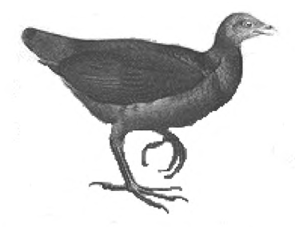

**Figure 6.8:** *Megapodius eremita*, Bismarck Scrub Fowl

POc *mʷalau is reflected from Sulawesi (Sangirese *maleo*) to the easternmost bird of this family in Tonga (Wallace 1869: 202-4, Christian 1926, but see also comments in Blust 2002).

| **POc** |  | *mʷalau | ‘Bismarck Scrub Fowl, *Megapodius eremita*’ |
| --- | --- | --- | --- |
| NNG | Kairiru | *molau* | ‘wild fowl inhabiting the bush, produces fairly large eggs’ |
| NNG | Manam | *molau* | ‘bird sp.’ |
| NNG | Gedaged | *malau* | ‘megapode’ |
| NNG | Sengseng | *muluŋ* | ‘bush hen, megapode’ |
| NCV | Mota | *mʷalau* | ‘Banks Island Scrub Fowl, *Megapodius layardi*’ |
| NCV | Lakon | *mʷala* | ‘*Megapodius layardi*’ |
| NCV | Raga | *mʷalau* | ‘*Megapodius layardi*’ |
| NCV | Matantas | *na-malau* | ‘*Megapodius layardi*’ |
| NCV | Sakao | *na-mlau* | ‘*Megapodius layardi*’ (Flux 1993) |
| NCV | Kiai | *malau* | ‘megapode (?)’ |
| NCV | Atchin | *(to)mla* | ‘bush turkey’ (to ‘fowl’) |
| NCV | Neve’ei | *(noto)molo* | ‘*Megapodius layardi*’ |
| NCV | Tape | *(ti)molo* | ‘*Megapodius layardi*’ |
| NCV | Nese | *(to)mola* | ‘*Megapodius layardi*’ |
| NCV | Southeast Ambrym | *meu* | ‘*Megapodius layardi*’ |
| NCV | Paamese | *meau* | ‘*Megapodius layardi*’ |
| NCV | Lewo | *miāu* | ‘bird sp., green with white belly and tail’ |
| NCV | Namakir | *molo* | ‘*Megapodius layardi*’ |
| NCV | Nguna | *malau* | ‘*Megapodius layardi*’ |
| Pn | Tongan | *malau* | ‘Polynesian Scrub Fowl, *Megapodius pritchardii*’ |
| Pn | Takuu | *marau* |  |
| Pn | Luangiua | *malau* |  |

An apparent doublet with *kʷ- appears in a number of New Guinea and Solomons languages:

| **POc** |  | *kʷal(i)au | ‘Bismarck Scrub Fowl, *Megapodius eremita*’ |
| --- | --- | --- | --- |
| NNG | North Watut | *keroŋ* | ‘bush-hen sp.’ |
| NNG | Poeng | *kerao* | ‘wildfowl’ |
| PT | Hula | *kʷalio* | ‘scrubhen’ |
| PT | Muyuw | *korau(ta)* | ‘megapod’ |
| PT | Iduna | *kʷalau(ta)* | ‘Dusky Scrub Fowl, *Megapodius freycinet*’ |
| PT | Bwaidoga | *kʷalau(ta)* | ‘megapod or bush hen’ |
| MM | Nakanai | *kileo* | ‘bush fowl (megapode)’ |
| MM | Tolai | *kuru(pap)* | ‘*Megapodius freycinet*’ |
| MM | Petats | *koloŋ* | ‘the mound-bird or megapodidae’ |
| MM | Kia | *kolo(peho)* | ‘megapode’ |
| SES | Gela | *koleo* | ‘a brush turkey, megapod’ |

The following set shows many irregularities suggestive of independent onomatopoetic origin, but there may be some basis for a reconstruction *k(a)iau.

| **POc** |  | *k(a)iau | ‘Bismarck Scrub Fowl, *Megapodius eremita*’ |
| --- | --- | --- | --- |
| Adm | Mussau | *kikiau* | ‘large mound building bird, Megapodius’ |
| NNG | Kove | *kio* | ‘bush hen, megapode’ |
| NNG | Lusi | *kaiau* |  |
| NNG | Amara | *o-koiou* | ‘bush hen, *wailpaul* (i.e. megapode)’ |
| NNG | Bariai | *kaiau* |  |
| NNG | Kilenge | *kaiau* | ‘bush hen’ |
| NNG | Mangap | *kiau* | ‘a wild bird, bush chicken’ |
| MM | Patpatar | *kiou* | ‘fowl that has been domesticated’ |
| MM | Tolai | *kiau* |  |
| MM | Halia | *kihau* | ‘ground bushfowl’ |
| MM | Halia | *kio* | ‘Dusky Scrub Fowl, *Megapodius freycinet*’ |
| MM | Nehan | *kaio* | ‘bush fowl’ |
| MM | Torau | *kiau* | ‘*Megapodius freycinet*’ |
| MM | Marovo | *io* |  |
| MM | Nduke | *eo* |  |
| MM | Roviana | *eo* | ‘brush hen’ |
| MM | Maringe | *kʰoʔio* |  |
| SES | Malango | *kihau* |  |
| SES | To’aba’ita | *geo* |  |
| SES | Kwara’ae | *geo* |  |
| SES | Kwaio | *geo* |  |

### 5.6. Pheasants and quails (Phasianidae)

Apart from the domestic fowl, the only representative of this family in the homeland is the Indian Blue Quail (*Coturnix chinensis*). In the following comparison, a POc reconstruction is justified if the Mangap and Tolai forms are regarded as continuing the PAn etymon.

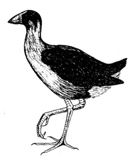

**Figure 6.9:** Porphyria porphyrio, Purple Swamphen

| **PAn** |  | *puRuq | ‘quail, partridge’ (Blust 2002) |
| --- | --- | --- | --- |
| **POc** |  | *puRu(q) | ‘quail’ |
| NNG | Mangap | *puru(pāla)* | ‘quail’ |
| MM | Tolai | *voro, woro* | ‘Indian Blue Quail, *Coturnix chinensis*’ |

### 5.7. Rails (Rallidae)

The numerous rails of Oceania include the very widespread Purple Swamphen (*Porphyrio porphyrio*), easily recognised by its large size and red forehead. Among the smaller species are the Buff-banded Rail (*Rallus philippensis*) and White-browed Rail (*Porzana cinerea*), which occur throughout much of the Oceanic region, and in the homeland three others of the genus *Rallus*, as well as the Bare-eyed Rail (*Eulabeornis plumbeiventris*), Red-necked Crake (*Rallina tricolor*), and Rufous-tailed Moorhen (*Amaurornis olivaceus*).

| **POc** |  | *bʷalaRe | ‘Purple Swamphen, *Porphyrio porphyrio*’ |
| --- | --- | --- | --- |
| MM | Tolai | *bulārə* | ‘purple swamp hen’ |
| SES | Uki ni Masi | *polale* |  |
| SES | Arosi | *pʷarare* | ‘large blue swamp bird sp.’ |
| SES | Bauro | *balare* | ‘large blue swamp bird sp.’ |
| Fij | Lau, Vanua Levu | *galā* |  |
| Fij | Rotuman | *kalœe* |  |
| Pn | Tongan | *kalae* |  |
| Pn | Niuean | *kalē, kulē* |  |
| Pn | East Futunan | *kalae* |  |
| Pn | Sikaiana | *kalae* | ‘bird sp.’ |
| Pn | Pileni | *kalai* | ‘bush bird sp.’ |
| Pn | Rennellese | *kagae* |  |
| Pn | Tikopia | *karae* |  |
| Pn | Emae | *karae* |  |
| Pn | West Uvean | *kalae* |  |
| Pn | Hawaiian | *ʔalae* | ‘Moorhen, *Gallinula chloropus*’ |

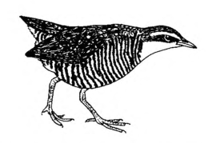

**Figure 6.10:** *Rallus philippensis*, Buff-banded Rail

Another possible POc reconstruction for the same bird is the following:

| **POc** |  | *bʷiru | ‘Purple Swamphen, *Porphyrio porphyrio*’ |
| --- | --- | --- | --- |
| MM | Maringe | *na-phiro* |  |
| NCV | Mota | *weru* | ‘*Eulabeornis*, a rail’ |
| NCV | Raga | *bʷiru* |  |
| NCV | Nese | *ne-vere* |  |
| SV | Sye | *(um)pulau* |  |
| SV | Ura | *bulau* |  |

The only other rail forwhich widespread cognate sets exist is the Buff-banded Rail (*Rallus philippensis*). The following possible POc reconstruction has only slender support:

| **POc** |  | *b(a,e,i)risu | ‘Buff-banded Rail, *Rallus philippensis*’ |
| --- | --- | --- | --- |
| MM | Tolai | *piriu* |  |
| SES | Uki ni Masi | *perisu* |  |
| SES | Bauro | *parisu* |  |

In Vanuatu, a solid set of cognates referring to this bird shows a distinct resemblance to the term for the Swamphen, POc *bʷalaRe.

| **PNCV** |  | *(b,bʷ)ilake | ‘Buff-banded *Rallus philippensis*’ |
| --- | --- | --- | --- |
| NCV | Mota | *pilaɣe* | ‘rail’ |
| NCV | Lakon | *pilaɣ* | ‘*Rallus philippensis*’ |
| NCV | Matantas | *na-pilagi* | ‘White-browed Rail, *Porzana cinerea*’ |
| NCV | Matantas | *na-pilagi ruhupoi* | ‘*Rallus philippensis*’ |
| NCV | Kiai | *pilae* | ‘*Rallus philippensis*’ |
| NCV | Atchin | *pila* | ‘rail’ |
| NCV | Neve’ei | *ni-bilaʔ* | ‘*Rallus philippensis*’ |
| NCV | Big Nambas | *beləɣ* | ‘rail’ |
| NCV | Namakir | *bʷilak* | ‘*Rallus philippensis*’ |
| NCV | Nguna | *na-pʷilake* | ‘*Rallus philippensis*’ |
| SV | Sye | *ne-mpli* | ‘*Rallus philippensis*’ |
| SV | Kwamera | *pəre* | ‘*Rallus philippensis*’ |

The similarity is enhanced by two SE Solomonic languages in which the word, while still denoting the Purple Swamphen, show unexpected *k* for *R in the final syllable:

| SES | Gela | *bilake, bulake* | ‘swamp hen’ |
| --- | --- | --- | --- |
| SES | Malango | *bulaki* | ‘*Porphyrio porphyrio*’ |

A group of New Caledonian names for the smaller rail echo the canonical form of *bʷalaRe and *(b,bʷ)olake:

| **PNCal** |  | *pit(a,i)ri | ‘rail’ |
| --- | --- | --- | --- |
| NCal | Tinrin | *piṭiri* | ‘rail’ |
| NCal | Xârâcùù | *picari* | ‘New Caledonian Wood Rail, *Gallirallus lafresnayanus*’ |
| NCal | Drubea | *pícárí* | ‘Buff-banded Rail, *Rallus philippensis*’ |

| **PNCal** |  | *biŋ | ‘Buff-banded Rail, *Rallus philippensis*’ |
| --- | --- | --- | --- |
| NCal | Nêlêmwâ | *biñ* |  |
| NCal | Caac | *pik* |  |
| NCal | Pije | *pik* |  |
| NCal | Cèmuhî | *bɛ̃n* |  |
| NCal | Iaai | *bœŋ* |  |

Proto Central Pacific had a distinct name for the Buff-banded Rail.

| **PCP** |  | *weka | ‘Buff-banded Rail, *Rallus philippensis*’ |
| --- | --- | --- | --- |
| Fij | Rotuman | *veʔa* |  |
| Pn | Tongan | *veka* |  |
| Pn | Niuean | *veka* |  |
| Pn | East Uvean | *veka* |  |
| Pn | East Futunan | *veka* |  |
| Pn | Samoan | *veʔa* |  |
| Pn | Rennellese | *veka* | ‘Purple Swamphen, *Porphyrio porphyrio* (juvenile)’ |
| Pn | Emae | *veka* |  |
| Pn | West Futunan | *veka* | ‘woodhen’ |
| Pn | West Uvean | *veka* |  |
| Pn | Tahitian | *tevea* | ‘*Rallus pacificus*’ (Forster, 1775; i.e. *teveʔa*) |
| Pn | Māori | *weka* | ‘Weka Rail, *Gallirallus australis*’ |

The hypothetical Tahiti Rail (*Rallus pacificus*) is known only from a painting made on Cook’s second voyage (duPont 1976:41), but the name recorded agrees with the evidence of its appearance that it was a species of Rallus.

The only reconstruction for the Sooty Crake (*Porzana tabuensis*) is restricted to Polynesian.

| **PPn** |  | *mo(s)o | ‘Sooty Crake, *Porzana tabuensis*’ |
| --- | --- | --- | --- |
| Pn | Tongan | *moho* |  |
| Pn | Niuean | *moho* |  |
| Pn | East Futunan | *moso* |  |
| Pn | Rennellese | *moso* |  |
| Pn | Mangareva | *moho* | ‘rail sp.’ |
| Pn | Tahitian | *meho* |  |
| Pn | Rarotongan | *moʔo-moʔo* |  |
| Pn | Māori | *moho* | ‘Buff-banded Rail, *Rallus philippensis*’ |

cf. also: Two Outlier languages apply a possible reflex of this word to a different small black bird:

| Pn | Nukuoro | *moso* | ‘Micronesian Starling, *Aplonis opaca*’ |
| --- | --- | --- | --- |
| Pn | Kapingamarangi | *moeho* | ‘*Aplonis opaca*’ |

The Nukuoro name looks like a regular development of PPn *moso, but the Kapingamarangi suggests possible borrowing from Micronesian (cf. Mokilese *mʷiɔk*).

### 5.8. Pigeons and doves (Columbidae)

This family is among the most richly elaborated in the Oceanic realm. Almost every island has at least one or two representatives, and the Proto Oceanic speakers may have been acquainted with twenty or more species. The most widely distributed Columbidae belong to two genera: the Imperial Pigeons (*Ducula* spp.), and the much smaller Fruit Doves (*Ptilinopus* spp.). Other genera represented include *Gymnophaps*, *Columba*, *Macropygia*, *Reinwardtoena*, *Chalcophaps*, *Gallicolumba*, *Henicophaps*, and the shaggy-plumaged Nicobar Pigeon, *Caloenas nicobarica*.

The most likely candidate for a generic is the following, which is identified as generic in some languages (Gedaged, Tawala, Muyuw), and elsewhere refers to a wide range of columbid genera. In some local areas, however, it appears to have become specialised.

| **PAn** |  | *punay | ‘dove, *Treron* sp.’ (Blust 2002) |
| --- | --- | --- | --- |
| **POc** |  | *bune | ‘pigeon, dove’ |
| NNG | Kairiru | *(mʸan)pun* | ‘pigeon’ (*mʸan* ‘bird’) |
| NNG | Manam | *bune* | ‘dove’ |
| NNG | Gedaged | *bun* | ‘general name for pigeons and doves’ |
| PT | Iduna | *bune-bune* | ‘Australian Pied Imperial Pigeon, *Ducula spilorrhoa*’ |
| PT | Tawala | *bune-bune* | ‘pigeon (generic)’ |
| PT | Kilivila | *bu-buna* | ‘dove’ |
| PT | Muyuw | *bʷá-bun* | ‘general term for pigeons’ |
| PT | Muyuw | *bu-buna* | ‘pigeon’ |
| PT | Muyuw | *bunú(vad)* | ‘white pigeon’ |
| PT | Muyuw | *buna(kuku)* | ‘blue pigeon’ |
| PT | Hula | *pune* | ‘dove’ |
| PT | Motu | *pune* | ‘*Ducula spilorrhoa*’ |
| PT | Bartie Bay | *bune-bune* | ‘a dove, blue pigeon’ |
| PT | Wedau | *bune-bune* | ‘green dove’ |
| MM | Patpatar | *bun* | ‘dove, pigeon’ |
| MM | Tolai | *(ta)bunə* | ‘Knob-billed Fruit Dove, *Ptilinopus insolitus*’ |
| MM | Nehan | *bun* | ‘Yellow-bibbed Fruit Dove, *Ptilinopus solomonensis*’ |
| MM | Petats | *bun* | ‘a small bird about the size of a dove’ |
| TM | Buma | *bune (batanoe)* | ‘Santa Cruz Ground Dove, *Gallicolumba sanctaecrucis*’ |
| NCV | Raga | *bune* | ‘*Ptilinopus greyii* (imm)’ |
| NCV | Matantas | *na-pone* |  |
| NCV | Kiai | *(va)pune* | ‘Silver-shouldered Fruit Dove, *Ptilinopus tannensis* (imm)’ |
| NCV | Atchin | *(wo)pun* | ‘bird sp.’ |
| NCV | Neve’ei | *(nav)bin* | ‘*Ptilinopus tannensis*’ |
| NCV | Avava | *(nep)bbun* | ‘*Ptilinopus tannensis*’ |
| NCV | Port Sandwich | *(na-vim)bün* | ‘*Ptilinopus tannensis*’ |
| NCV | Labo | *(ne-v)pün* | ‘*Ptilinopus tannensis*’ |
| NCV | Aulua | *(vi)ᵐbun* | ‘*Ptilinopus tannensis*’ |
| SV | Ura | *ubuda* | ‘*Ptilinopus greyii*’ |
| SV | Sye | *no-mpon* | ‘*Ptilinopus greyii*’ |
| SV | Lenakel | *pun(hūa)* | ‘bird sp., blue with red breast’ |
| SV | Kwamera | *pən(harov), pin(uas)* | ‘*Ptilinopus greyii*’ |
| SV | Anejom̃ | *no-pña* | ‘*Ptilinopus* spp.’ |
| NCal | Nêlêmwâ | *gun* | ‘Cloven-feathered Dove, *Drepanoptila holosericea*’ |
| NCal | Caac | *gun* | ‘*Ptilinopus greyii*’ |
| NCal | Jawe | *gun* | ‘pigeon vert’ |
| NCal | Cèmuhî | *bun-hêʔ-wī* | ‘*Drepanoptila holosericea*’ |
| NCal | Iaai | *biñ* | ‘*Ptilinopus greyii*’ |
| NCal | Dehu | *piñ* | ‘a pigeon’ |
| Fij | Bauan | *bune(damu)* | ‘Orange Dove, *Ptilinopus victor*’ |
| Fij | Bauan | *buna(kō)* | ‘Golden Dove, *Ptilinopus luteovirens*’ |

Another very widespread set is also wide-ranging in its reference, though with a clear focus on genus *Ducula*, at least in Remote Oceanic languages.

| **POc** |  | *ku(i)ba | ‘pigeon, probably *Ducula* sp.’ |
| --- | --- | --- | --- |
| PT | Tawala | *guba(lia)* | ‘blue pigeon’ |
| PT | Magori | *gubai* | ‘pigeon’ |
| PT | Mekeo | *kopi* | ‘pigeon’ |
| MM | Marovo | *(ba)kupa* | ‘Nicobar Pigeon, *Caloenas nicobarica*’ |
| MM | Nduke | *(ba)kupa* | ‘*Caloenas nicobarica*’ |
| MM | Roviana | *(ba)kupa* | ‘a pigeon’ |
| SES | Bauro | *(wa)ubo* | ‘Mackinlay’s Cuckoo Dove, *Macropygia mackinlayi*’ |
| NCV | Matantas | *na-whete* | ‘Pacific Pigeon, *Ducula pacifica*’ |
| NCV | Kiai | *wepe* | ‘*Ducula pacifica*’ |
| NCV | Neve’ei | *no-ɣoim* | ‘*Ducula pacifica*’ |
| NCV | Naman | *nu-ɣub* | ‘*Ducula pacifica*’ |
| NCV | Tape | *no-ɣʷip* | ‘*Ducula pacifica*’ |
| NCV | Avava | *wīm* | ‘*Ducula pacifica*’ |
| NCV | Big Nambas | *kutᫀ, wibi* |  |
| NCV | Nese | *no-ɣdᫀo* | ‘*Ducula pacifica*’ |
| NCV | Nasarian | *na-xaiᵐba* | ‘*Ducula pacifica*’ |
| NCV | Southwest Bay | *no-ʔoiᵐb* | ‘*Ducula pacifica*’ |
| NCV | Port Sandwich | *na-xuᵐb* | ‘*Ducula pacifica*’ |
| NCV | Southeast Ambrym | *nip* | ‘*Ducula pacifica*’ |
| NCV | Paamese | *uīve* | ‘*Ducula pacifica*’ |
| NCV | Lewo | *kupa* | ‘pigeon’ |
| NCV | Namakir | *kīm* | ‘*Ducula pacifica*’ |
| NCV | Nguna | *wīpa* | ‘*Ducula pacifica*’ |
| SV | Ura | *wim* | ‘Pacific pigeon’ |
| SV | Sye | *no-ɣʷem* | ‘*Ducula pacifica*’ |
| Mic | Sonsorolese | *kyope* | ‘Micronesian Pigeon, *Ducula oceanica*’ |
| Fij | Rotuman | *ʔipɔ* | ‘*Ducula pacifica*’ |
| Pn | Rennellese | *kuipa* | ‘male Pacific Pigeon with black swelling at bill’ |
| Pn | Pileni | *uᵐbe* | ‘pigeon, dove’ |
| Pn | Marquesan | *kūkupa* | ‘*Ptilinopus dupetithouarsi*’ |
| Pn | Tahitian | *ʔuʔupa* | ‘Grey-green Fruit Dove, *Ptilinopus purpuratus*’ |
| Pn | Manihiki | *kukupa* | ‘wood dove’ |
| Pn | Rarotongan | *kūkupa* | ‘Rarotongan Fruit Dove, *Ptilinopus rarotongensis*’ |
| Pn | Māori | *kūkupa* | ‘New Zealand Pigeon, *Hemiphaga novaeseelandiae*’ |

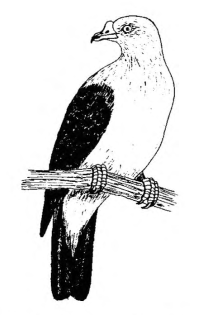

**Figure 6.11:** *Ducula pacifica*, Pacific Pigeon

#### 5.8.1. Imperial Pigeons (*Ducula*)

The best supported cognate set for this type of pigeon has a PAn antecedent, though the development of PAn *R to POc *l is not regular.

| **PAn** |  | *baRuj | ‘dove, *Ducula* sp.’ (Blust 2002) |
| --- | --- | --- | --- |
| **POc** |  | *baluc | ‘pigeon, *Ducula* sp.’ |
| Adm | Mussau | *balus* | ‘dove sp.’ (from Tok Pisin?) |
| Adm | Loniu | *pan* | ‘bird sp.’ |
| Adm | Nyindrou | *ban* | ‘dove’ |
| Adm | Titan | *(pim)pal* | ‘pigeon’ |
| Adm | Lou | *pɔl* | ‘pigeon, dove: *Ducula* spp.’ |
| NNG | Manam | *bali(boro)* | ‘grey pigeon’ |
| NNG | Yabem | *balosi* | ‘dove, big slate-coloured pigeon’ |
| NNG | Kove | *vazuhi* | ‘dove’ |
| NNG | Kilenge | *a-vol* | ‘dove’ |
| NNG | Mangap | *ᵐbalᵐbal* | ‘dove’ |
| NNG | Tami | *ᵐbalut* | ‘blue dove’ |
| NNG | Aria | *belis* | ‘dove’ |
| NNG | Kaulong | *(ekiŋ) vulus* | ‘dove’ (*ekiŋ* ‘bird’) |
| NNG | Lamogai | *belis* | ‘dove’ |
| MM | Bali | *balu* | ‘dove’ |
| MM | Tigak | *valus* | ‘dove’ |
| MM | Patpatar | *balus* | ‘big black and white pigeon’ |
| MM | Tolai | *bəlu* | ‘generic for pigeons, esp. Island Imperial Pigeon, *Ducula pistrinaria*’ |
| MM | Nehan | *baluh* | ‘*Ducula pistrinaria*’ |
| MM | Tinputz | *banus* | ‘*Ducula* spp.’ |

cf. also:

| MM | Roviana | *baruku* | ‘fruit pigeon’ |
| --- | --- | --- | --- |
| MM | Simbo | *ba(r)ɣu* | ‘pigeon sp.’ |
| MM | Maringe | *balʰu* | ‘pigeon (generic)’ |
| MM | Kia | *babaluhu* | ‘pigeon’ |

Note that the New Georgia and Santa Isabel words listed under ‘cf. also’ reflect the wrong final consonant.

| **POc** |  | *bona | ‘pigeon, *Ducula* sp.’ |
| --- | --- | --- | --- |
| MM | Tolai | *bonbon* | ‘pigeon sp.’ |
| MM | Ramoaaina | *(kūru) bonbon* | ‘Island Imperial Pigeon, *Ducula pistrinaria*’ |
| NCV | Mota | *pʷona* | ‘a pigeon’ |
| NCV | Mota | *mala-pʷona* | ‘*Ptilinopus* spp.’ |
| NCV | Lakon | *pʷɔn* | ‘Pacific Pigeon, *Ducula pacifica*’ |
| NCV | Raga | *man-bona* | ‘*Ducula pacifica*’ |
| NCV | Apma | *bihil-bon* | ‘*Ducula* spp.’ |

cf. also: Probable borrowing from a North Vanuatu language:

| Pn | Pileni | *nu-mbona* | ‘pigeon’ |
| --- | --- | --- | --- |

Probably a local development of the above are the following Solomons forms reflecting *boRa.

| MM | Nehan | *bor* | ‘Grey-breasted Quail Dove (*Gallicolumba beccarii*) and ground doves generally’ |
| --- | --- | --- | --- |
| MM | Maringe | *bora* | ‘variety of *balhu* [pigeon] found in forest’ |
| MM | Kia | *bora* | ‘Knob-billed Fruit Dove, *Ptilinopus insolitus*’ |
| SES | Bugotu | *bora* | ‘pigeon’ |
| SES | Gela | *bola* | ‘pigeon spp.’ |
| SES | To’aba’ita | *bola* | ‘pigeon, probably *Ducula* sp.’ |
| SES | Kwara’ae | *bola* | ‘pigeon like *kurukuru* but lives inland’ |
| SES | Kwaio | *bola* | ‘pigeon’ |
| SES | ’Are’are | *pora* | ‘a pigeon’ |

Like PPn *tū below, an undoubtedly imitative name, but locally focused on a single species:

| **PNCV** |  | *tutu | ‘Baker’s Pigeon, *Ducula bakeri*’[^8] |
| --- | --- | --- | --- |
| NCV | Mota | *(man)tut* | ‘kind of Vanua Lava pigeon that cries *tut*’ |
| NCV | Mwotlap | *nu-tut* |  |
| NCV | Lakon | *tut* |  |
| NCV | Raga | *tutu* |  |
| NCV | Wusi (Nokovula) | *(manu)tu* |  |
| NCV | Matantas | *(na-nohu)tu* |  |
| NCV | Kiai | *(mu)tu-(nu)tu* | (second name) |

Although the following is in near-complementary distribution with POc *bune, and could almost be a metathetic development of it, Bauan at least contrasts the two terms.

| **PCP** |  | *ru(b,v)e | ‘Pacific Pigeon, *Ducula pacifica*’ |
| --- | --- | --- | --- |
| Fij | Bauan | *ruve* | ‘Pacific Pigeon, *Ducula pacifica*, or White-throated Pigeon, *Columba vitiensis*’ |
| Pn | Tongan | *lupe* |  |
| Pn | Niuean | *lupe* |  |
| Pn | Samoan | *lupe* |  |
| Pn | East Futunan | *lupe* |  |
| Pn | Tuvalu | *lupe* |  |
| Pn | Luangiua | *lupe* |  |
| Pn | Sikaiana | *lupe* |  |
| Pn | Rennellese | *gupe* |  |
| Pn | Tikopia | *rupe* |  |
| Pn | Marquesan | *ʔupe* | ‘Marquesas Pigeon, *Ducula galeata*’ |
| Pn | Tahitian | *rupe* | ‘Society Islands Pigeon, *Ducula aurorae*’ |
| Pn | Rarotongan | *rupe* |  |
| Pn | Māori | *rupe* | ‘New Zealand Pigeon, *Hemiphaga novaeseelandiae*’ |

cf. also: Probable Polynesian loans:

| TM | Buma | *(te)lupe* | ‘pigeon spp.’ |
| --- | --- | --- | --- |
| Mic | Kiribatese | *rupe* | ‘Micronesian Pigeon, *Ducula oceanica*’ |
| Fij | Rotuman | *rupe(vao)* | ‘bird sp.’ (*vao* ‘forest’) |

#### 5.8.2. Fruit Doves (*Ptilinopus*)

| **POc** |  | *g(a)umu | ‘Fruit Dove, *Ptilinopus* sp.’ |
| --- | --- | --- | --- |
| NNG | Yabem | *(mɔʔ)ᵑgom* | ‘dove’ (*mɔʔ* ‘bird’) |
| NNG | Bing | *gūmgum* |  |
| PT | Ubir | *kum(ag)* | ‘blue pigeon’ |
| SES | ’Are’are | *(ku)kumu* | ‘pigeon’ |
| SES | Arosi | *(kumu)kumu* | ‘pigeon sp.’ |
| NCV | Matantas | *na-kauma* |  |
| NCV | Rerep | *ŋaum* |  |
| NCV | Neve’ei | *(nav)goum* | ‘large Tanna fruit dove’ |
| SV | Lenakel | *(təma)kum* | ‘k. bird, like *punhūa* but larger’ |
| SV | Kwamera | *(təmə)kum* | ‘k.o. *pinharov*, red-bellied fruit dove’ |

| **PSES** |  | *va(o,u) | ‘Fruit Dove, *Ptilinopus* sp.’ |
| --- | --- | --- | --- |
| SES | Malango | *(bela)vau* | ‘Yellow-bibbed Fruit Dove, *Ptilinopus solomonensis*) (female)’ |
| SES | To’aba’ita | *fao* | ‘dove sp., green with yellow breast’ |
| SES | Kwara’ae | *fao* | ‘bird sp., not very big, powdery-white like pigeon (*bola*)’ |
| SES | Kwara’ae | *fau* | ‘Red-bibbed Fruit Dove, *Ptilinopus viridis*’ |

| **PNCV** |  | *vʷeru | ‘Fruit Dove, *Ptilinopus* sp.’ |
| --- | --- | --- | --- |
| NCV | Mota | *wir* | ‘a bird’ |
| NCV | Vurës | *wiria* | ‘Grey’s Fruit Dove, *Ptilinopus greyii*’ |
| NCV | Ambae | *were (memea)* | ‘*Ptilinopus greyii*’ (*memea* ‘red’) |
| NCV | Raga | *vʷeru* | ‘*Ptilinopus greyii*’ |
| NCV | Naman | *nu-vire* | ‘bird sp.’ |
| NCV | Tape | *vʷiri* | ‘*Ptilinopus greyii*’ |
| NCV | Larëvat | *na-ver* | ‘Silver-shouldered Fruit Dove, *Ptilinopus tannensis*’ |

| **PNCV** |  | *tobaka | ‘Fruit Dove, *Ptilinopus* sp.’ |
| --- | --- | --- | --- |
| NCV | Ambae | *tobaka* | ‘Silver-shouldered Fruit Dove, *Ptilinopus tannensis*’ |
| NCV | Kiai | *tipa* | ‘*Ptilinopus tannensis*’ |
| NCV | Araki | *tipa* | ‘*Ptilinopus tannensis*’ |
| NCV | Nese | *(novo)todᫀak* | ‘*Ptilinopus tannensis*’ |
| NCV | Nguna | *tokopea* | ‘dove’ |
| NCV | South Efate | *tokape* | ‘ground dove, *Chalcophaps*’ |

| **POc** |  | *(k,g)upuR | ‘pigeon or dove’ |
| --- | --- | --- | --- |
| MM | Patpatar | *kuhur* | ‘ground dove’ |
| MM | Tolai | *kuvur* | ‘pigeon sp.’ |
| MM | Nduke | *kukuvu* | ‘Island Imperial Pigeon, *Ducula pistrinaria*’ |
| MM | Roviana | *kukuva* | ‘small green dove sp.’ |
| SES | Gela | *kuvu* | ‘pigeon sp., very small, yellowish breast’ |
| SES | ’Are’are | *kuvu* | ‘a wood pigeon’ |
| SES | Bauro | *kuhui* | ‘Red-bibbed Fruit Dove, *Ptilinopus viridis*’ |

#### 5.8.3. Ground-feeding pigeons

The following appears to be a local survival of a term reconstructible for PMP, but the glosses, even within the SE Solomonic subgroup, are confusingly diverse.

| **PMP** |  | *-muken | ‘omen dove’ (Blust 2002) |
| --- | --- | --- | --- |
| **POc** |  | *((l,R)(a,u))mu(k,kʷ)o | ‘dove sp.’ |
| SES | Gela | *lumuko* | ‘ground pigeon sp.’ |
| SES | Malango | *muko* | ‘Mackinlay’s Cuckoo Dove, *Macropygia mackinlayi*’ |
| SES | Lau | *lamoa* | ‘dove’ |
| SES | Kwaio | *lamuʔo* | ‘small red bird in mountainous interior, a ground feeder’ |
| SES | Bauro | *rumoɣo* | ‘Brown-backed Emerald Dove, *Chalcophaps stephani*’ |

| **POc** |  | *butir | ‘pigeon sp.’ |
| --- | --- | --- | --- |
| NNG | Adzera | *busir* | ‘pigeon’ |
| NNG | North Watut | *boser* | ‘dove’ |
| PT | Wedau | *butura* | ‘blue pigeon’ |
| MM | Patpatar | *buten* | ‘imperial pigeon’ |
| MM | Nduke | *buti* | ‘Brown-backed Emerald Dove, *Chalcophaps stephani*’ |
| MM | Roviana | *buti* | ‘bird like a small pigeon, brown breast, green back, eats canarium nuts’ |
| NCV | N Ambrym | *(min)buis* | ‘large Tanna fruit dove’ |

An isolated Micronesian form appears as a possible cognate of this set, Kiribati *pitin* ‘ground dove, *Gallicolumba* sp.’. The exact species reference of the Kiribati term is unclear. However, Pratt et al. (1987:194-5) indicate that this bird was introduced to Kiribati (Abemama) about 1940 from some other Pacific island. Since none of the possible source islands have words resembling *bitin*, it would seem much more likely that this name (phonetically [pisin]) is a borrowing from English pigeon.

| **PSOc** |  | *mʷaRaki | ‘Emerald Dove, *Chalcophaps indica*’ (John Lynch, pers. comm.) |
| --- | --- | --- | --- |
| NCV | Mota | *mʷara* | ‘a dove’ |
| NCV | Lakon | *mʷœrœɣ* |  |
| NCV | Raga | *mʷaraɣi* |  |
| NCV | Matantas | *na-mahi* |  |
| NCV | Kiai | *(vo)mae* |  |
| NCV | Atchin | *(wo)mere* | ‘bird sp.’ |
| NCV | Naman | *(vo)mar* |  |
| NCV | Neve’ei | *(na-v)mar* |  |
| NCV | Tape | *(na-vʷi)mar* |  |
| NCV | Avava | *(ap)mar* |  |
| NCV | Larëvat | *(ave)mar* |  |
| NCV | Nese | *(no-vo)maɣ* |  |
| NCV | Labo | *(na-v)maxa* |  |
| NCV | Axamb | *(na-vi)mʷer* |  |
| NCV | Southeast Ambrym | *mai* |  |
| NCV | Paamese | *amē* |  |
| NCV | Namakir | *mar* | ‘ground dove’ |
| SV | North Tanna | *mʷak* | ‘dove’ |
| SV | Kwamera | *mak* | ‘pigeon or dove (generic)’ |

| **PPn** |  | *tū | ‘ground dove’ |
| --- | --- | --- | --- |
| Pn | Tongan | *tū* | ‘Friendly Quail Dove, *Gallicolumba stairi*’ |
| **PNPn** |  | *tū, *tū-kele | ‘ground dove’ |
| Pn | East Futunan | *tū* | ‘Purple-capped Fruit Dove, *Ptilinopus porphyraceus*’ |
| Pn | East Futunan | *tū-kele* | ‘*Gallicolumba stairi*’ |
| Pn | Samoan | *tū-ʔaimeo* | ‘*Gallicolumba stairi* (female and young)’ |
| Pn | Samoan | *tū-tautifa* | ‘*Gallicolumba stairi* (male)’ |
| Pn | Emae | *tū-kere* | ‘Emerald Dove, *Chalcophaps indica*’ |
| Pn | Ifira-Mele | *tū-kere* | ‘*Chalcophaps indica*’ |
| Pn | Māori | *tū-kere* | ‘bird sp. remembered in proverbs’ |

The absence of glottal stop in the Tongan and E Futunan forms shows that this name is likely imitative of the species’ voice, rather than derived from *tuʔu* ‘stand’ (referring to the species’ ground-feeding habits). However, in languages where the glottal stop has been lost the two would be homophonous, and *tū-kere* may be understood by present day speakers as ‘stands on the ground’.

#### 5.8.4. Other species

| **POc** |  | *woku | ‘Cuckoo Dove, *Macropygia* sp.’ |
| --- | --- | --- | --- |
| MM | Nakanai | *(ka)voku* | ‘bird sp.’ |
| MM | Tolai | *(to)vok* | ‘bird sp.’ |
| MM | Banoni | *boku* | ‘Mackinlay’s Cuckoo Dove, *Macropygia mackinlayi*’ |
| MM | Nduke | *oku* | ‘prob. *Macropygia mackinlayi*’ |
| MM | Simbo | *voku* | ‘bird sp.’ |
| SES | Bugotu | *(ka)vuku* | ‘pigeon’ |
| SES | Gela | *(ka)vuku* | ‘a dove’ |
| SES | Malango | *(ka)vuku* | ‘*Ptilinopus* sp.’ |
| SV | Ura | *(uvor)wok* | ‘White-throated Pigeon, *Columba vitiensis*’ |
| SV | Sye | *(no-ɣol)woɣ* | ‘*Columba vitiensis*’ |

Imitative naming is a high probability here; cf. PAn *qekuŋ ‘owl’, PWMP *bekur ‘coo, turtle dove’, PMP *bukaw ‘owl sp.’ (Blust 2002). The voice of *Macropygia mackinlayi* is represented as ‘kor-wu’ or ‘vo-ku’ (Hadden 2004a: 114). A metathetic variant is represented by Teop (MM) *uvo* ‘*Macropygia mackinlayi*’, cf. Koiari (Papuan) *kuvo* ‘Lesser Bar-tailed Cuckoo Dove, *Macropygia* nigrirostris’.

| **PSOc** |  | *taroap(v) | ‘White-throated Pigeon, *Columba vitiensis*’ (John Lynch, pers. comm.) |
| --- | --- | --- | --- |
| **PNCV** |  | *taroa | ‘White-throated Pigeon, *Columba vitiensis*’ |
| NCV | Mota | *taroa* | ‘pigeon sp.’ |
| NCV | Lakon | *tarɔ* |  |
| NCV | Matantas | *na-taroa* |  |
| NCV | Kiai | *taroa* |  |
| NCV | Naman | *doro* |  |
| NCV | Neve’ei | *no-toro* |  |
| NCV | Big Nambas | *toro* |  |
| NCV | Southeast Ambrym | *teau* |  |
| NCV | Paamese | *talʊ* | ‘bird sp.’ |
| NCV | Lewo | *tewa* | ‘bird (smaller than *kupa*)’ |
| NCV | Namakir | *taro* | ‘blackbird sp.’ |
| NCV | Nguna | *taroa* | ‘pigeon sp.’ |
| NCV | South Efate | *tarʊ* | ‘bush bird sp.’ |
| NCal | Fwai | *dāp* |  |
| NCal | Cèmuhî | *(íú̄íá)-jāap* | (*íú̄íá* ’New Caledonian Pigeon, *Ducula goliath*’) |
| NCal | Paicî | *(déa)jéé* |  |

| **PNCV** |  | *toava | ‘Mackinlay’s Cuckoo Dove, *Macropygia mackinlayi*’ |
| --- | --- | --- | --- |
| NCV | Mwotlap | *nʊ-tʊap* |  |
| NCV | Vera’a | *ʔoava* |  |
| NCV | Vurës | *tʊav* |  |
| **Proto Central Vanuatu** |  | *bʷaueve | ‘Mackinlay’s Cuckoo Dove, *Macropygia mackinlayi*’ |
| NCV | Raga | *bʷaueve* |  |
| NCV | Southeast Ambrym | *vūeh* |  |
| NCV | Paamese | *vouehe* |  |
| NCV | Namakir | *tov* | ‘long-tailed pigeon sp’ |

The following set undoubtedly owes something to imitation of typical pigeon ‘coo’ vocalizations—low pitched but with strong formant structure. Compare the Wayan Fijian name for a species introduced from Asia in modern times: *kukurū* ’Spotted-necked Dove, Streptopelia chinensis‘.

| **POc** |  | *(ku(r,l)u)ku(r,l)u | ‘pigeon sp.’ |
| --- | --- | --- | --- |
| NNG | Takia | *kula-kulu* | ‘pigeon sp.’ |
| PT | Gapapaiwa | *kuɣu-kuɣu* | ‘fruit dove, *Ptilinopus* sp.?’ |
| PT | Mekeo | *kūr* | ‘pigeon/dove’ (Schellong and Carolsfeld 1890) |
| MM | Nakanai | *kuru* | ‘dove, pigeon’ |
| MM | Ramoaaina | *kūru* | ‘a pigeon’ (*Ducula*, *Macropygia*) |
| MM | Tolai | *kur* | ‘Brown’s Long-tailed Pigeon, *Reinwardtoena browni*’ |
| MM | Nehan | *kū(i)lū* | ‘pigeon/dove’ (Schellong and Carolsfeld 1890) |
| MM | Petats | *kulu* | ‘the blue wild pigeon’ |
| MM | Halia | *kulu* | ‘Island Imperial-Pigeon, *Ducula pistrinaria*, or Red-knobbed Pigeon, *Ducula* rubricera’ |
| MM | Torau | *ku-kuru* | ‘*Ducula pistrinaria*’ |
| MM | Marovo | *kuru-kuru* | ‘*Ducula pistrinaria* and similar spp.’ |
| MM | Nduke | *ku-kuru (peka)* | ‘k. fruit dove, similar to *Ducula rubricera*, but lives in mountains’ |
| MM | Nduke | *kuru* | ‘*Ducula* spp.’ |
| SES | Gela | *kuru-kuru* | ‘white pigeon sp.’ |
| SES | Malango | *kulu-kulu* | ‘Chestnut-bellied Pigeon, *Ducula brenchleyi*’ |
| SES | Malango | *kuru-kuru* | ‘*Ducula rubricera*’ |
| SES | Kwara’ae | *kuru-kuru* | ‘dove like bola but lives on the sea’ |
| SES | Kwaio | *kulu-kulu* | ‘bird sp.’ |
| SES | Sa’a | *kuru-kuru (ni malau)* | ‘pigeon sp. without wattles on the beak’ (*malau* ‘island’, also place name) |
| SES | Sa’a | *kolo-kolo* | ‘Crested Long-tailed Pigeon, *Reinwardtoena crassirostris*’ |
| SES | Ulawa | *kuru-kuru* | ‘wood pigeon (generic)’ |
| SES | Uki ni Masi | *kuru-kuru (ni wapu)* | ‘*Ducula brenchleyi*’ (*wapu* ‘forest’) |
| Fij | Bauan | *kulu(votu)* | ‘Many-coloured Fruit Dove, *Ptilinopus perousii*’ |
| Fij | Bauan | *gilu* | ‘Friendly Quail Dove, *Gallicolumba stairi*’ |
| Pn | Tongan | *kulu-kulu* | ‘Purple-capped Fruit Dove, *Ptilinopus porphyraceus*’ |
| Pn | Niuean | *kulu-kulu* | ‘*Ptilinopus porphyraceus*’ |
| Pn | East Uvean | *kulu-kulu* | ‘*Ptilinopus porphyraceus*’ |
| Pn | Emae | *kulu-kulu* | ‘*Ptilinopus* spp.’ |

cf. also:

| NNG | Gedaged | *kududuk* | ‘bird like small dove, bluish green’ |
| --- | --- | --- | --- |

| **POc** |  | *kurau | ‘pigeon sp.’ |
| --- | --- | --- | --- |
| NNG | Poeng | *kulao* | ‘great cuckoo-dove’ |
| MM | Nduke | *kuratu* | ‘Pale Mountain Pigeon, *Gymnophaps solomonensis*’ (*-t-* unexplained) |
| MM | Vangunu | *kərao* | ‘red-knobbed pigeon’ |
| SES | Gela | *kura-kurau* | ‘green and white pigeon sp. with red crest’ |
| SES | Tolo | *kuau* | ‘bird sp. which feeds on nuts’ |
| SES | Malango | *kurau* | ‘Nicobar Pigeon, *Caloenas nicobarica*’ |
| SES | ’Are’are | *urau* | ‘pigeon’ |
| SES | Sa’a | *urou* | ‘wood pigeon with large wattles’ |

cf. also:

| SES | Bauro | *kuvʷau* | ‘Red-knobbed Pigeon, *Ducula rubricera*’ |
| --- | --- | --- | --- |
| SES | Bauro | *kuvʷau (mano)* | ‘White-throated Pigeon, *Columba vitiensis*’ |
| Pn | Rennellese | *kiou* | ‘small *Ducula* sp.’ (borrowed from a SES language) |

| **PEOc** |  | *belik(e,i)o | ‘pigeon sp.’ |
| --- | --- | --- | --- |
| SES | Gela | *belikokeo* | ‘pigeon sp., black with red beak’ |
| NCV | Naman | *beligio* |  |
| NCV | Neve’ei | *ni-bʷiligio* |  |
| NCV | Larëvat | *balgio* |  |
| NCV | Nese | *na-ble* |  |

| **PROc** |  | *soge | ‘pigeon sp.’ |
| --- | --- | --- | --- |
| NCV | Nasarian | *nə-soᵑg* | ‘black pigeon of the mountains’ |
| Fij | Bauan | *soge* | ‘Peak’s Pigeon, *Ducula latrans*’ |
| Fij | Bauan | *soge(loa)* | ‘White-throated Pigeon, *Columba vitiensis*’ (*loa* ‘black’) |
| Fij | Wayan | *soge* | ‘Peak’s Pigeon, *Ducula latrans*’ |

| **POc** |  | *bʷaruruk | ‘pigeon or dove sp.’ |
| --- | --- | --- | --- |
| NNG | Takia | *pururuk* | ‘pigeon sp.’ |
| SES | Malango | *(manu) pururu* | ‘Brown-backed Emerald Dove, *Chalcophaps stephani*’ |
| SES | Sa’a | *(ta)pʷaruru* | ‘bronze-wing dove’ |
| SES | Bauro | *bʷoroau* | ‘Crested Long-tailed Pigeon, *Reinwardtoena crassirostris*’ |
| NCV | Nguna | *pʷoruru* | ‘to coo’ |

cf. also:

| MM | Tolai | *bilul* | ‘Nicobar Pigeon, *Caloenas nicobarica*’ |
| --- | --- | --- | --- |

Possibly cognate are forms in SHWNG languages (Ansus *mambaru*, Biak *mambruk*) referring to the Crowned Pigeons (*Goura* spp.) (Anceaux 1961).

### 5.9. Parrots (Loriidae, Cacatuidae, Psittacidae)

The three families united here are represented by nine diverse genera in the homeland. By far the largest bird, not confusible with any other, is the Blue-eyed Cockatoo (*Cacatua ophthalmica*). The large Eclectus Parrot (*Eclectus roratus*) shows striking sexual dimorphism, with males (green) and females (red) often lexically distinguished. The Rainbow Lory (*Trichoglossus haematodus*) is probably the most conspicuous and widespread parrot in western Oceania. Among other middle-sized parrots are the Cardinal Lory (*Chalcopsitta cardinalis*), the Purple-bellied Lory (*Lorius hypoinochrous*) and the Singing Parrot (*Geoffroyus heteroclitus*). Smaller parrots include two Lorikeets of the genus Charmosyna, which, along with the closely related genus Vini, are found as far as eastern Polynesia. Smallest of all are the Pygmy Parrots of genus *Micropsitta* and the Orange-fronted Hanging Parrot (*Loriculus aurantiifrons*). For the last (which is found no further east than New Guinea) not a single name was found in any of the sources.

#### 5.9.1. Cockatoos

Only Papuan Tip languages supply sufficient cognates to support reconstructions for these birds. That the first term may be traceable to POc, however, is suggested by possible cognates in SHWNG languages such as Ansus *kara*, Serui-Laut *karai*, Ambai *kara* ‘cockatoo’ (Anceaux 1961).

| **PPT** |  | *karai | ‘white cockatoo’ |
| --- | --- | --- | --- |
| PT | Wagawaga | *kehoi* |  |
| PT | Dobu | *keyoi* |  |
| PT | Wedau | *keloi* |  |
| PT | Sinaugoro | *karai* |  |
| PT | Hula | *kalai* |  |
| PT | Motu | *karai* | ‘cockatoo’ |

| **PPT** |  | *wakeke~kakawe | ‘Sulphur-crested Cockatoo, *Cacatua galerita*’ |
| --- | --- | --- | --- |
| PT | Tubetube | *wakeke* | ‘cockatoo’ |
| PT | Suau | *wakeke* | ‘cockatoo’ |
| PT | Iduna | *kakawe* |  |
| PT | Bwaidoga | *kakawe* | ‘white cockatoo’ |
| PT | Bwaidoga | *wakeke* | (northern dialect) |
| PT | Roro | *iaveiave* | ‘white cockatoo’ |
| PT | Mekeo | *aveave* | ‘bird sp.’ |

cf. also: Compare perhaps:

| MM | Nduke | *vakvoa* | ‘Ducorps Cockatoo, *Cacatua ducorpsii*’ |
| --- | --- | --- | --- |
| MM | Maringe | *veɣa* | ‘*Cacatua ducorpsii*’ |

#### 5.9.2. The Eclectus Parrot

This large parrot (*Eclectus roratus*) is most notable for its sexual dimorphism, with the predominantly red-plumaged female and green-plumaged male sometimes being separately lexicalised. The first two reconstructions are similar in form, and appear to refer to the male. Unfortunately, sources for the few languages that reflect both the shorter and longer term are unhelpful as to the distinction of meaning. Apparent reflexes of the first reconstruction extend well beyond the range of the Eclectus, and are applied to various other species, eventually reaching as far as New Zealand.

| **POc** |  | *kaRa | ‘male Eclectus Parrot, *Eclectus roratus*’ |
| --- | --- | --- | --- |
| NNG | Yabem | *kalaʔ* | ‘the green male parrot’ |
| NNG | Bariai | *kala* | ‘parrot’ |
| NNG | Kove | *kaha* | ‘parrot’ |
| NNG | Lusi | *kara* | ‘parrot’ |
| NNG | Kilenge | *(ai)kala* | ‘parrot’ |
| MM | Halia | *kala-kala* | ‘Eclectus Parrot’ |
| MM | Marovo | *kara* | ‘*Eclectus roratus*’ |
| MM | Nduke | *(ma)kara* | ‘*Eclectus roratus*’ |
| MM | Roviana | *kara* | ‘general name for parrots’ |
| MM | Simbo | *(ma)kara* | ‘*Eclectus roratus*’ |
| MM | Kia | *(ma)kara* | ‘green parrot’ |
| MM | Maringe | *(ma)k(h)ara* | ‘*Eclectus roratus*’ (Webb 1992) ; ‘green parrot’ (Tryon 1995) |
| SES | Gela | *kalao* | ‘green parrot sp.’ |
| SES | To’aba’ita | *a-ʔala* | ‘*Eclectus roratus*’ |
| SES | Kwaio | *a-ʔala* | ‘*Eclectus roratus*’ |
| SES | ’Are’are | *ara* | ‘large green parrot, red under wings’ |
| SES | Sa’a | *ʔa-ʔa* | ‘*Eclectus roratus*’ |
| SES | Uki ni Masi | *ʔala* | ‘*Eclectus roratus*’ |
| SES | Bauro | *ɣara* | ‘*Eclectus roratus*’ |
| Fij | Bauan | *ka-kā* | ‘Shining Parrot, *Prosopeia* spp.’ |
| Fij | Wayan | *ka-kā* | ‘possibly Collared Lory, *Phigys solitarius*’ |
| Pn | Tongan | *ka-kā* | ‘Red Shining Parrot, *Prosopeia tabuensis*’ |
| Pn | Tahitian | *(e)ʔa-ʔa* | ‘green parrot sp. with red forehead’ (probably *Cyanoramphus* sp.; Forster 1775) |
| Pn | Māori | *kā-kā* | ‘parrot spp.’ |

| **PWOc** |  | *ka(l,R)aŋa(r,R) | ‘male Eclectus Parrot, *Eclectus roratus*’ |
| --- | --- | --- | --- |
| NNG | Bariai | *kalaŋa-n* | ‘parrot’ |
| NNG | Kove | *kahaŋa-ni* | ‘parrot’ |
| NNG | Lusi | *karaŋa-ni* | ‘parrot’ |
| NNG | Gedaged | *iɬaŋ* | ‘k. parrot, male green and red, blue and red’ |
| NNG | Amara | *a-kalaŋar* | ‘parrot’ |
| NNG | Kilenge | *ai-kalaŋa* | ‘parrot’ |
| NNG | Mouk | *kalaŋa* | ‘parrot’ |
| NNG | Kaulong | *(ekiŋ) kalaŋ* | ‘parrot’ |
| NNG | Lamogai | *kalaŋa* | ‘parrot’ |
| NNG | Sengseng | *kahalaŋ* | ‘parrot’ |
| NNG | Poeng | *kerana* | ‘Eclectus Parrot; parakeet (?) likes corn, banana, papaya’ |
| PT | Bwaidoga | *anegala* | ‘parrot sp.’ |
| PT | Tawala | *kanagala* | ‘parrot’ |
| PT | Wedau | *kanagara* | ‘parrot’ |
| PT | Kilivila | *karaga* | ‘green parrot’ |
| PT | Nimoa | *heleŋe* | ‘parrot sp.’ |
| PT | Balawaia | *ɣalaga* | ‘parrot’ |
| PT | Hula | *alaka* | ‘green lorikeet’ |
| PT | Mekeo | *alaŋa* | ‘common green parrot, female red’ |
| MM | Vitu | *ɣalaŋa* | ‘*Eclectus roratus*’ |
| MM | Nakanai | *kalaŋan* | ‘*Eclectus roratus*’ |
| MM | Tabar | *garagar* | ‘*Eclectus roratus*’ |
| MM | Patpatar | *kalaŋar* | ‘parrot sp.’ |
| MM | Tolai | *kələŋərə* | ‘Eclectus Parrot (red)’ |
| MM | Nehan | *kalaŋara* | ‘Eclectus Parrot’ |
| MM | Petats | *kanakana* | ‘large green fruit-eating parrot’ |
| MM | Banoni | *karaka* | ‘male Eclectus Parrot’ |

| **POc** |  | *(k,kʷ)ilo(ki) | ‘female Eclectus Parrot’ |
| --- | --- | --- | --- |
| PT | Balawaia | *kiloki* | ‘dark green bird sp.’ |
| PT | Hula | *kiloki* | ‘lovebird’ |
| PT | Motu | *kiole* | ‘parrot sp.’ (metathesis of †*kilo(ɣ)i*) |
| MM | Simbo | *kilo* | ‘parrot sp.’ |
| MM | Maringe | *na-klio* | ‘red and green parrot, possibly female of makara’ |
| SES | Gela | *kilo* | ‘red parrot sp.’ |
| SES | Longgu | *kilo* | ‘red parrot (female)’ |
| SES | To’aba’ita | *kiro* | ‘female Eclectus’ |
| SES | Kwaio | *liko-liko* | ‘Yellow-bibbed Lory, *Lorius chlorocercus*’ (metathesis) |
| SES | ’Are’are | *riko-riko* | ‘a parrot, tamed as a pet’ (metathesis) |
| SES | Sa’a | *ilo-iloʔa* | ‘large red parrot, female of *ʔaʔa*’ |
| SES | Arosi | *riko-riko* | ‘a parrot, tamed as a pet’ (metathesis) |

The following term may also be associated with Eclectus. Cf. POc *keRaŋ ‘hawksbill turtle’ (ch. 5, 250), a name which is eventually re-applied to a parrot in New Zealand (Maori *kea* ‘Nestor nolabilis’).

| **POc** |  | *kiRak | ‘parrot sp.’ |
| --- | --- | --- | --- |
| PT | Gapapaiwa | *kira-kiraka* |  |
| PT | Wedau | *kira-kirako* | ‘parrot’ |
| MM | Tinputz | *ki-kire* | ‘Eclectus parrot’ |
| MM | Banoni | *kire* | ‘(red) Eclectus parrot’ |
| MM | Babatana | *kira* | ‘lorikeet’ |
| MM | Marovo | *kira* | ‘medium sized parrots, between chiri and kara’ |
| MM | Kia | *ki-kila* | ‘Blue-streaked Lory, *Eos reticulata*’ |
| MM | Maringe | *kʰie-kile* | ‘small green bird’ |
| SES | Malango | *kira* | ‘Eclectus Parrot, *Eclectus roratus*’ |
| SES | Lau | *kil-kila* | ‘green parrot’ |
| SES | Kwara’ae | *kila* | ‘palm lorikeet (green, yellow, red)’ |
| SES | Sa’a | *kile-kile* | ‘Rainbow Lory, *Trichoglossus haematodus*’ |
| SES | Arosi | *kira-kira* | ‘small green parrot’ |

#### 5.9.3. Middle-sized parrots

The following four reconstructions appear to be cut from the same basic form: the first with a three-consonant sequence, and each of the others missing one of the three. It would be natural to treat the others as simply variously reduced forms of the longest form, but there are apparent contrasts in several languages. The references are to medium-sized parrots (*Chalcopsitta*, *Lorius*, *Trichoglossus*), but it is difficult to see any consistent association between a particular species and any of these forms. Beyond the Solomons, the first two species disappear, and these terms are applied to Trichoglossus, or in New Caledonia to the parakeets of genus Cyanoramphus.

| **POc** |  | *sipi(r,R)i | ‘Rainbow Lory, *Trichoglossus haematodus*, or Cardinal Lory, *Chalcopsitta cardinalis*’ |
| --- | --- | --- | --- |
| Adm | Lou | *sipir* | ‘parrot-like bird’ |
| NNG | Takia | *siwir* | ‘*Trichoglossus haematodus*’ |
| PT | Balawaia | *rivili* | ‘small green parrot’ |
| PT | Lala | *sivili* | ‘small parrot with green neck’ |
| PT | Mekeo | *cipili, kipili* | ‘a noisy parrot’ |
| MM | Teop | *subiri* | ‘*Chalcopsitta cardinalis*’ |
| SES | Bugotu | *siviri* | ‘red parrot’ |
| TM | Buma | *vili* | ‘Palm Lorikeet and Rainbow Lorikeet’ |
| NCV | Mota | *sivure* | ‘a parrot’ |
| NCV | Nume | *(we)svur* | ‘*Trichoglossus haematodus*’ |
| NCV | Raga | *siviru* | ‘*Trichoglossus haematodus*’ |
| NCV | Neve’ei | *ni-n-sivir* | ‘*Trichoglossus haematodus*’ |
| NCV | Nese | *ni-civir* | ‘*Trichoglossus haematodus*’ |
| NCV | Nasarian | *na-sivərə* | ‘*Trichoglossus haematodus*’ |
| NCV | Labo | *ni-sivəxə* | ‘*Trichoglossus haematodus*’ |
| NCV | Port Sandwich | *sivir* | ‘*Trichoglossus haematodus*’ |
| NCV | Lewo | *leviri* | ‘parrot sp., red with green neck’ |
| NCV | Nguna | *siviri* | ‘parrot sp., red chest, green and yellow wings’ |
| SV | Kwamera | *sivur* | ‘*Trichoglossus haematodus*’ |
| NCal | Pije | *diwali* | ‘Red-fronted Parakeet, *Cyanoramphus novaezelandiae*’ |
| NCal | Nengone | *sipih* | ‘parrot (red)’ |
| Pn | Rennellese | *sivigi* | ‘*Lorius chlorocercus*’ |

cf. also:

| MM | Nduke | *sivoro* | ‘Yellow-bibbed Lory, *Lorius chlorocercus* and Duchess Lorikeet, *Charmosyna margarethae*’ |
| --- | --- | --- | --- |
| MM | Roviana | *sivoro* | ‘parrot sp. like rosella’ |
| MM | Maringe | *sivoro* | ‘*Trichoglossus haematodus*’ |

| **POc** |  | *sipi | ‘parrot, perhaps Cardinal Lory, *Chalcopsitta cardinalis*’ |
| --- | --- | --- | --- |
| Adm | Loniu | *cihi* | ‘small parrot’ |
| NNG | Sengseng | *susu* | ‘parrot’ |
| PT | Mekeo | *ufi* | ‘mountain parrot sp., blue, prized for its plumes’ |
| MM | Nehan | *sipih* | ‘*Chalcopsitta cardinalis*’ |
| SES | Bugotu | *sivi* | ‘parrot sp.’ |
| SES | Gela | *suisui* | ‘a red parakeet in coconuts’ |
| SES | Malango | *cui* | ‘Yellow-bibbed Lory, *Lorius chlorocercus*’ |
| SES | Arosi | *sivī, divi* | ‘scarlet parrot sp.’ |
| SES | Bauro | *sivi* | ‘scarlet parrot sp.’ |
| NCV | Dorig | *siv* | ‘*Trichoglossus haematodus*’ |
| NCV | Raga | *sivi* | ‘Lorius, *Trichoglossus haematodus*’ |
| NCV | Matantas | *na-civi* | ‘*Trichoglossus haematodus* and Palm Lorikeet, *Charmosyna palmarum*’ |
| NCV | Atchin | *na-si* | ‘parrot sp.’ |
| NCV | Atchin | *šiel* | ‘parrot sp.’ |
| NCV | Naman | *ni-ncəv* | ‘*Trichoglossus haematodus*’ |
| NCV | Paamese | *sīho* | ‘parrot’ |
| Pn | Takuu | *sivi* | ‘*Chalcopsitta cardinalis*’ |
| Pn | Luangiua | *sivo* | ‘red parrot’ |
| Pn | Tikopia | *sivi* | ‘*Trichoglossus haematodus*’ |

| **POc** |  | *siri | ‘parrot, perhaps Cardinal Lory, *Chalcopsitta cardinalis*’ |
| --- | --- | --- | --- |
| PT | Wedau | *tiri(rama), siri(rama)* | ‘long-tailed parrot sp.’ |
| MM | Mono-Alu | *(ulu)sili* | ‘red parrot’ |
| MM | Marovo | *ciri* | ‘*Charmosyna* sp. (?) and small parrots generally’ (also modified = Trichoglossus) |
| MM | Nduke | *siri nabo* | ‘*Chalcopsitta cardinalis*’ |
| MM | Roviana | *siri* | ‘red parakeet sp.’ |
| MM | Simbo | *siri* | ‘red bird sp. that eats coconut’ |
| SES | Gela | *siri* | ‘small red parrot sp.’ |
| SES | Malango | *ciciri* | ‘*Chalcopsitta cardinalis*’ |
| SES | Malango | *(kolo)ciri* | ‘*Charmosyna* spp.’ |
| SES | Longgu | *suri* | ‘noisy parrot, lives in coconut trees’ |
| SES | To’aba’ita | *suri(aoa)* | ‘parrot sp.’ |
| SES | To’aba’ita | *sū-suri* | ‘parrot sp.’ |
| SES | Lau | *siri* | ‘small bird sp.’ |
| SES | Lau | *siru* | ‘long tailed bird sp.’ |
| SES | Kwaio | *suli(kē)* | ‘Rainbow Lory, *Trichoglossus haematodus*’ |
| SES | ’Are’are | *siri* | ‘red hen parrot’ |
| SES | Sa’a | *siri* | ‘a parrot’ |
| SES | Sa’a | *siri (alaha)* | ‘Yellow-bibbed Lory, *Lorius chlorocercus*’ (*alaha* ‘chief’) |
| SES | Sa’a | *siri (uʔu)* | ‘a lory that hangs head downward’ (*uʔu* ‘hang down’) |
| SES | Uki ni Masi | *siri* | ‘*Chalcopsitta cardinalis*’ |
| SES | Arosi | *siri* | ‘*Chalcopsitta cardinalis*’ |
| SES | Arosi | *sire* | ‘small parrot sp.’ |
| NCV | Sakao | *ne-ssere* | (Flux 1993) |
| NCal | Tinrin | *ḍiria* | ‘parrot’ |
| NCal | Xârâcùù | *jiria* | ‘*Trichoglossus haematodus*’ |
| NCal | Drubea | *jíríá* | ‘Red-fronted Parakeet, *Cyanoramphus novaezelandiae*’ |

cf. also:

| Mic | Ponapean | *serēt* | ‘Ponape Lory, *Trichoglossus rubiginosus*’ |
| --- | --- | --- | --- |
| Mic | Mokilese | *cerēt* | ‘*Trichoglossus rubiginosus*’ |
| Pn | Nukuoro | *serete* | ‘parakeet’ |

| **POc** |  | *pʷiri(p) | ‘parrot sp.’ |
| --- | --- | --- | --- |
| MM | Nduke | *vili(sulu)* | ‘Rainbow Lory, *Trichoglossus haematodus*’ |
| MM | Roviana | *vili(suru)* | ‘small noisy greenish bird often found at coconut and *Barringtonia* blossoms’ |
| TM | Buma | *vili* | ‘*Trichoglossus haematodus* and Palm Lorikeet, *Charmosyna palmarum*’ |
| NCV | North Efate | *vini* |  |
| SV | Ura | *ule* | ‘coconut lory’ |
| SV | Sye | *ure* | ‘*Trichoglossus haematodus*’ |
| NCal | Nêlêmwâ | *pʷīrip* | ‘Horned Parakeet, *Psittacus cornutus*’ |
| NCal | Caac | *pʷīrip* | ‘*Trichoglossus haematodus*’ |
| NCal | Fwai | *pʷīrip* | ‘perruche ecossaise’ (*Trichoglossus haematodus*) |
| Pn | Samoan | *vilu* | ‘a large parroquet’ |
| Pn | Pileni | *vili* | ‘parrot’ |
| Pn | Tahitian | *vini* | ‘Tahitian Lory, *Vini peruviana*’ |

| **Proto Malaita-Makira** |  | *kirori | ‘parrot sp.’ |
| --- | --- | --- | --- |
| SES | Lau | *kirori* | ‘parrot sp.’ |
| SES | ’Are’are | *irori* | ‘a parrot’ |
| SES | ’Are’are | *kirori* | ‘a parrot, finding its food specially on the blossoms of coconut trees; tamed as pets’ |
| SES | Sa’a | *kirori, ʔirori* | ‘Cardinal Lory, *Chalcopsitta cardinalis*’ |
| SES | Arosi | *kirori* | ‘*Chalcopsitta cardinalis*’ |

#### 5.9.4. Small parrots

The small parrots of closely related genera *Charmosyna* and *Vini* are referred to by two possibly not independent etyma.

| **POc** |  | *(ka)reŋas | ‘small parrot sp.’ |
| --- | --- | --- | --- |
| Adm | Loniu | *kɛʔɛŋ* | ‘parrot sp.’ |
| Adm | Nyindrou | *karen* | ‘parrot’ |
| Adm | Titan | *kareŋ* | ‘red parrot, *Agapornis roseicollis*’ |
| Adm | Lou | *kareŋ* | ‘red parrot’ |
| NNG | Yabem | *(mɔ)ndeŋ* | ‘female red parrot’ |
| NNG | Bing | *(iri)reŋ* | ‘Emerald Lorikeet, *Neopsittacus pullicauda*’ |
| MM | Petats | *reŋis* | ‘the small red honey-eating parrot’ |
| MM | Tinputz | *renges* | ‘Rainbow Lory, *Trichoglossus haematodus*’ |
| NCV | Mota | *reŋa* | ‘a parrot’ |
| NCV | Mota | *reŋas* | ‘Palm Lorikeet, *Charmosyna palmarum*’ |
| NCV | Mwotlap | *na-iŋɛs* | ‘*Charmosyna palmarum*’ |
| NCV | Raga | *deŋasi* | ‘*Charmosyna palmarum*’ |
| NCV | Wusi (Nokovula) | *(de)deŋa* | ‘*Charmosyna palmarum*’ |
| NCV | Southeast Ambrym | *reŋ* | ‘*Charmosyna palmarum*’ |

cf. also: Probable loanword from a North-Central Vanuatu language:

| Pn | Tikopia | *leŋa* | ‘Duchess Lorikeet, *Charmosyna margarethae*, also Cardinal Honeyeater, *Myzomela cardinalis*’ |
| --- | --- | --- | --- |

The Titan gloss is subject to question, as the lovebirds (*Agapornis* spp.) are native to Africa.

| **POc** |  | *seŋa | ‘parrot sp.’ |
| --- | --- | --- | --- |
| NNG | Manam | *seŋ* | ‘parrot’ |
| MM | Nehan | *seŋ* | ‘Rainbow Lory, *Trichoglossus haematodus*’ |
| MM | Halia | *seŋe* | ‘*Trichoglossus haematodus*’ |
| Fij | Bauan | *seŋa* | ‘Blue-crowned Lory, *Vini australis*’ |
| Pn | Tongan | *heŋa* | ‘*Vini australis*’ |
| Pn | Niuean | *heŋa* | ‘*Vini australis*’ |
| Pn | East Uvean | *heŋa* | ‘*Vini australis*’ |
| Pn | East Futunan | *seŋa* | ‘*Vini australis*’ |
| Pn | Samoan | *seŋa(vao)* | ‘*Vini australis*’ |
| Pn | Nukuria | *te-hēna* | ‘*Trichoglossus haematodus*’ |
| Pn | Pileni | *eŋa* | ‘land bird sp.’ |

#### 5.9.5. Other parrot species

| **POc** |  | *(k,kʷ,g)i(l,n)e | ‘Singing Parrot, *Geoffroyus heteroclitus*’ |
| --- | --- | --- | --- |
| MM | Tolai | *ŋini-ŋil* | ‘*Geoffroyus heteroclitus*’ |
| MM | Tolai | *gili-gil* | ‘small green parrot sp.’ |
| MM | Tolai | *gini-gil* | ‘sea bird allied to parrots’ |
| MM | Tinputz | *ki-kire* |  |
| MM | Nduke | *ki-kine* | ‘Red-breasted Pygmy Parrot, *Micropsitta bruijnii*’ |
| MM | Roviana | *kine-kine* | ‘a parakeet, sometimes tamed and trained to speak’ |
| SES | Bugotu | *kie-kiñe* | ‘a green parrot’ |
| SES | Gela | *kine-kine* | ‘green parrot’ |
| SES | Malango | *kina* |  |
| SES | To’aba’ita | *kila-kila* |  |
| SES | Bauro | *ɣinai* |  |

cf. also: A loan from a Southeast Solomonic language:

| Pn | Rennellese | *ɣinei* | ‘Finsch’s Pygmy Parrot, *Micropsitta finschii*’ |
| --- | --- | --- | --- |

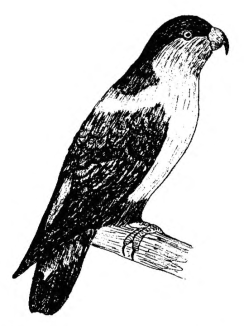

**Figure 6.12:** *Phigys solitarius*, Collared Lory

| **POc** |  | *marewe | ‘parrot’ |
| --- | --- | --- | --- |
| MM | Nakanai | *marea* | ‘parrot’ |
| MM | Tolai | *malip* | ‘Purple-bellied Lory, *Lorius hypoinochrous*’ |
| MM | Ramoaaina | *marewe* | ‘Lorins hypoinochrous’ |
| MM | Petats | *malei* | ‘bird (generic)’ |
| MM | Taiof | *marei* | ‘bird (generic)’ |
| MM | Torau | *marii* | ‘bird (generic)’ |
| NCV | Wusi (Nokovula) | *maramarei* | ‘Palm Lorikeet, *Charmosyna palmarum*’ |
| NCV | Atchin | *mʷer* | ‘parrot sp.’ |

| **PCP** |  | *kula | ‘Collared Lory, *Phigys solitarius*’ |
| --- | --- | --- | --- |
| Fij | Bauan | *kula* |  |
| Pn | Tongan | *kula* | ‘bird sp.’ (Churchward); ‘possibly Cardinal *Myzomela cardinalis*’ (Carlson 1974) |
| Pn | Marquesan | *kuʔa* | ‘bird sp.’ |
| Pn | Tuamotuan | *kura* | ‘bird sp. highly prized for its plumage’ |
| Pn | Rarotongan | *kurā(moʔo)* | ‘Tahitian Lory, *Vini peruviana*’ |

cf. also: Polynesian borrowing (the species is a recent introduction from the Austral Islands):

| Mic | Kiribatese | *kura* | ‘Kuhl’s Lory, *Vini kuhlii*’ |
| --- | --- | --- | --- |

The renown of this parrot’s feathers has produced a range of extended meanings, beyond bird names, as in PPn *kula ‘(bright) red’ and the following:

| Pn | Tikopia | *kura* | ‘honored; of ritual value’ |
| --- | --- | --- | --- |
| Pn | West Uvean | *kula* | ‘flying fox fur’ |
| Pn | Pukapukan | *(wulu) kula* | ‘red feathers from western islands’ (*wulu* ‘feathers’) |
| Pn | Rapanui | *kura* | ‘short, multi-coloured feathers of certain birds’ |
| Pn | Marquesan | *kuwa* | ‘red, applied to feathers, cloth etc. imported to the islands, also to the scarlet berries or peas used in their ornaments’ (Crook et al. 1799) |
| Pn | Tahitian | *ʔura* | ‘red feathers, formerly sacred to the gods’ |
| Pn | Māori | *kura* | ‘red feathers; ornamented with feathers; precious, treasure’ |

### 5.10. Cuckoos (Cuculidae)

Eight species of this family are recorded from the homeland, two as seasonal visitors. They include parasitic cuckoos of the genera *Cuculus*, *Cacomantis*, *Chalcites*, *Urodynamis* and *Scythrops*, and two Coucals of the genus *Centropus*. Names recorded, however, are far fewer than for the parrots with a comparable number of species. Only one small cognate set of Proto Oceanic scope has been found.

| **POc** |  | *seke | ‘cuckoo, possibly *Centropus* sp.’ |
| --- | --- | --- | --- |
| MM | Patpatar | *sēk* | ‘cuckoo’ |
| MM | Nduke | *heɣe-heɣe* | ‘*Centropus* sp.’ |
| SES | Malango | *sege* | ‘Buff-headed Coucal, *Centropus milo* (imm)’ |

| **PSOc** |  | *lVvusi | ‘cuckoo’ (John Lynch, pers. comm.) |
| --- | --- | --- | --- |
| NCV | Raga | *livusi-ɣala* | ‘Long-tailed Koel, *Urodynamis taitensis*’ |
| NCV | Matantas | *ri-risive(re)* | ‘Golden-Bronze Cuckoo, *Chalcites lucidus*’ (metathesis) |
| SV | Kwamera | *ia-rovəs* | ‘*Urodynamis taitensis*’ (metathesis) |

| **PCP** |  | *kalewa | ‘Long-tailed Koel, *Urodynamis taitensis*’ |
| --- | --- | --- | --- |
| Fij | Rotuman | *(si)aʔleva* | ‘? *Urodynamis taitensis*’ |
| Pn | Tongan | *kaleva* |  |
| Pn | Niuean | *kalue* |  |
| Pn | East Futunan | *kaleva* |  |
| Pn | Samoan | *ʔāleva* |  |
| Pn | Pukapukan | *kāleva* |  |
| Pn | Tuvalu | *kaleva* |  |
| Pn | Takuu | *kāreva* |  |
| Pn | Sikaiana | *kaleva* |  |
| Pn | Rennellese | *kāgeva* | ‘a large dove or pheasant’ |
| Pn | Tikopia | *kāreva* |  |
| Pn | Marquesan | *kāʔeva-ʔeva* |  |
| Pn | Tahitian | *ʔāreva-reva* |  |
| Pn | Māori | *kārea-rea, kārewa-rewa* | ‘New Zealand Falcon, *Falco novaeseelandiae*’ |

The Maori reflex above refers to a bird which, though not closely related, has an overall similarity in appearance to the Koel.

| **PCP** |  | *kawekawesā | ‘Long-tailed Koel, *Urodynamis taitensis*’ |
| --- | --- | --- | --- |
| Fij | Bauan | *kawakasā* | ‘long-tailed bird sp.’ |
| Fij | Lau (Eastern Fijian) | *kawakawasā* | ‘*Urodynamis taitensis*’ |
| Pn | Tahitian | *ʔōʔōvea* | ‘*Urodynamis taitensis*’ |
| Pn | Tongareva | *koekoeā* | ‘*Urodynamis taitensis*’ |
| Pn | Māori | *koekoeā* | ‘*Urodynamis taitensis*’ |

| **PMic** |  | *(li)kapilei | ‘cuckoo’ |
| --- | --- | --- | --- |
| Mic | Kiribatese | *kapenei* | ‘*Urodynamis taitensis*’ |
| **PChk** |  | *likāpi | ‘a bird’ |
| Mic | Woleaian | *rixāpirāi* | ‘bird sp.’ |
| Mic | Namoluk | *likapilei* | ‘Long-tailed Koel, *Urodynamis taitensis*’ |
| Mic | Trukese | *nikœ̄p* | ‘land bird sp. (brown, long tail, afraid of other birds)’ |

Although Micronesian borrowing would not be expected, the similarity of the following is intriguing:

| Pn | Mangareva | *pakanei* | ‘name of a bird mentioned by Laval, possibly the cuckoo’(Hiroa 1938) |
| --- | --- | --- | --- |

### 5.11. Owls (Tytonidae, Strigidae)

The Barn Owls (Tytonidae) and Typical Owls (Strigidae) are each represented in Oceania by a single genus. The Barn Owl (*Tyto alba*) is probably the most widespread owl of the Oceanic region. In the homeland it coexists with the endemic New Britain Barn Owl (*Tyto aurantia*). There are also two Hawk Owls of the genus Ninox. While the voice of the Barn Owl is described as a screech, Typical Owls (like pigeons) have calls whose acoustic profile suggests the low second formant of [u]-type vowels. The Solomon Islands Hawk Owl (*Ninox jacquinoti*), for example, has a call described as ‘’Kuurrroo’ with rolled ’r” (Hadden 2004a: 155). The prevalence of such vowels in the first three cognate sets places them under a certain degree of uncertainty. Note, however, that reflexes of *lulu are found mostly in areas where the Barn Owl is the only owl present, and are therefore unlikely to be imitative.

| **POc** |  | *kuru(dr,d)u | ‘owl’ |
| --- | --- | --- | --- |
| NNG | Dami | *kuru(min)* | ‘owl’ |
| NNG | Yabem | *kululuʔ(poŋ)* | ‘owl’ |
| NNG | Poeng | *ku-kulo* | ‘owl spp.’ |
| PT | Gapapaiwa | *gudu-gudu* | ‘owl; Papuan Frogmouth, *Podargus papuensis*’ |
| PT | Kilivila | *kuru* | ‘owl’ |
| MM | Patpatar | *kur-kuru* | ‘owl’ |
| MM | Tolai | *kur(u)kur* | ‘small owl sp.’ |
| MM | Halia | *kurou* | ‘Solomon Islands Hawk-Owl, *Ninox jacquinoti*’ |
| MM | Teop | *kuroi* | ‘*Ninox jacquinoti*’ |
| MM | Teop | *(toto)kururu* | ‘Fearful Owl, *Nesasio solomonensis*’ |
| MM | Tinputz | *kuro* | ‘*Ninox jacquinoti*’ |
| MM | Banoni | *kūru* | ‘*Ninox jacquinoti*’ |
| MM | Torau | *kuru* | ‘*Ninox jacquinoti*’ |
| MM | Babatana | *kururu* | ‘owl’ |
| MM | Marovo | *orodo* | ‘*Ninox jacquinoti* or *Nesasio solomonensis*’ |
| MM | Maringe | *na-krudu* | ‘*Ninox jacquinoti*’ |
| SES | Tolo | *kuru* | ‘owl’ |
| SES | Longgu | *kuru* | ‘owl’ |
| SES | To’aba’ita | *(noʔo) kurudu* | ‘owl (as pet)’ |

cf. also:

| NNG | Mangap | *uloto* | ‘owl’ |
| --- | --- | --- | --- |
| MM | Kia | *kikituru* | ‘owl’ |

| **POc** |  | *drudru(r,R) | ‘owl’ |
| --- | --- | --- | --- |
| MM | Madak | *dudu* | ‘owl’ |
| MM | Sursurunga | *durdur* | ‘owl taxon, includes Sooty Owl, Grass Owl’ |
| MM | Nduke | *duduru* | ‘owl (generic)’ |
| MM | Roviana | *duduru* | ‘owl sp.’ |
| SES | Bugotu | *duru* | ‘owl’ |
| SES | Gela | *duru* | ‘an owl’ |

cf. also:

| MM | Halia | *tutul* | ‘Fearful Owl, *Nesasio solomonensis*’ |
| --- | --- | --- | --- |
| MM | Tinputz | *toruruen* | ‘owl’ |

| **PROc** |  | *lulu | ‘Barn Owl, *Tyto alba*’ |
| --- | --- | --- | --- |
| NCV | Kiai | *lulu* |  |
| NCV | Araki | *lulu* |  |
| NCV | Atchin | *lul* | ‘the night hawk’ |
| NCV | Maskelynes | *na-rür* | ‘owl’ |
| NCV | Lewo | *(kia)lulu* | ‘owl’ |
| Fij | Bauan | *lulu* |  |
| Pn | Tongan | *lulu* |  |
| Pn | East Futunan | *lulu* |  |
| Pn | Samoan | *lulu* |  |
| Pn | Pileni | *lulu* | ‘owl’ |
| Pn | Rennellese | *gugu* |  |
| Pn | Tikopia | *ruru* |  |
| Pn | West Uvean | *lulu* |  |
| Pn | Māori | *ruru* | ‘Boobook Owl, *Ninox novaeseelandiae*’ |

cf. also: A Polynesian borrowing:

| Fij | Rotuman | *ruru* | ‘owl spp’ |
| --- | --- | --- | --- |

cf. also:

| TM | Buma | *e-luro* |  |
| --- | --- | --- | --- |

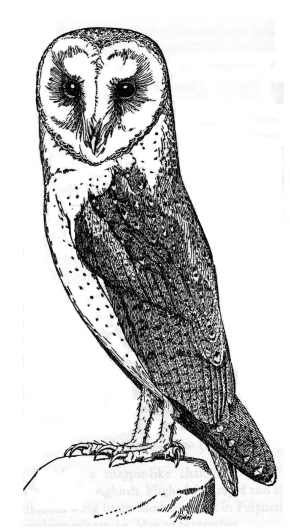

**Figure 6.13:** *Tyto alba*, Barn Owl

An unusually large number of Polynesian bird names reflect *lulu but are applied to various seabirds (compare *toloa, §5.3):

| Pn | Tuvalu | *lulu* | ‘Phoenix Petrel, *Pterodroma alba*’ |
| --- | --- | --- | --- |
| Pn | Rapanui | *ruru* | ‘Giant Petrel, *Macronectes giganteus*’ |
| Pn | Tahitian | *ruro* | ‘Tahiti Kingfisher, *Halcyon venerata*’ |
| Pn | Manihiki | *ruru* | ‘large sea bird sp. with hooked bill’ |
| Pn | Māori | *ruru-tāiko* | ‘Black Petrel, *Procellaria parkinsoni*’ |

And borrowed from Polynesian:

| Mic | Kiribatese | *ruru* | ‘*Pterodroma alba*’ |
| --- | --- | --- | --- |

There is at present an owl-free area in Eastern Polynesia, which may account for the maritime application of some of these words. However, owls and petrels have in common that they are seldom seen, and mainly known by their calls at night. Spenneman (2004:149) notes that *licemᵚao*, the present Marshallese term for the female of the Short-eared Owl (*Asio flammeus*) was given by an earlier source for a type of petrel. (The name is probably analysable as *li-* ‘feminine prefix’ + ? + *mᵚa* ‘cry’ + *o* ‘oh!’.)

| **POc** |  | *pora | ‘owl’ |
| --- | --- | --- | --- |
| NNG | Kaulong | *(ekiŋ) voh* | ‘owl’ |
| MM | Nduke | *po-poro* | ‘nocturnal bird, said to call just before daylight’ |
| NCV | Mota | *(man)wara* | ‘owl’ |
| NCV | Rerep | *nu-ᵐbur* | ‘owl’ |
| NCV | Port Sandwich | *na-vandr* | ‘owl’ |
| NCV | Southwest Bay | *(ni-vin) ᵐbant* | ‘owl’ |
| NCV | Southeast Ambrym | *vuei* | ‘Barn Owl, *Tyto alba*’ |
| NCV | Paamese | *voia(asue)* | ‘*Tyto alba*’ |

| **PEOc** |  | *wisi | ‘owl’ |
| --- | --- | --- | --- |
| SES | Lau | *kʷisi* | ‘bird sp.’ |
| SES | Kwaio | *kʷisi* | ‘bird believed to announce events’ |
| NCV | Mota | *wis* | ‘an owl’ |
| NCV | Lakon | *wis* | ‘Barn Owl, *Tyto alba*’ |
| NCV | Ambae | *wisi* |  |
| NCV | Raga | *(bʷat)vʷisi* | ‘*Tyto alba*’ (expected †*-wisi*) |
| NCV | Big Nambas | *nū-vis* | ‘owl, *Tyto alba*’ (expected †*-wis*) |

| **PSV** |  | *sumʷit | ‘Barn Owl, *Tyto alba*’ |
| --- | --- | --- | --- |
| SV | Ura | *ne-mit* |  |
| SV | Sye | *no-mit* |  |
| SV | North Tanna | *(ka)səmʷ* | ‘owl’ |
| SV | Kwamera | *(kə)sumʷi* |  |
| SV | Lenakel | *himʷir* |  |

| **PNCal** |  | *mʷen | ‘Barn Owl, *Tyto alba*’ |
| --- | --- | --- | --- |
| NCal | Nêlêmwâ | *mʷen* |  |
| NCal | Caac | *mʷen* |  |
| NCal | Fwai | *mʷen* |  |
| NCal | Cèmuhî | *mʷin* |  |
| NCal | Xârâcùù | *mʷã(dööya)* |  |
| NCal | Drubea | *mʷé* |  |
| NCal | Iaai | *mun* |  |
| NCal | Dehu | *men* |  |
| NCal | Nengone | *meni* |  |

### 5.12. Swifts and swallows (Apodidae, Hemiprocnidae, Hirundinidae)

These three groups are closely allied in general appearance and habits and rarely distinguished terminologically. The swiftlets are familiar birds of garden areas throughout much of Oceania. The most common species noted are the White-rumped Swiftlet (*Aerodramus spodiopygius*), Uniform Swiftlet (*Aerodramus vanikorensis*) and White-bellied Swiftlet (*Collocalia esculenta*). These are not in general lexically distinguished. The few terms recorded for the Pacific Swallow (*Hirundo tahitica*) and the even fewer for the Whiskered Tree-swift (*Hemiprocne mystacea*) are often lexically associated with those for the Swiftlets, and where they are not, they do not support any independently reconstructible term. These birds are also terminologically linked with small insectivorous bats: SE Ambrym (NCV) *avœp* ‘any small bat; swiftlet’; E Futunan *pekapeka* ‘White-rumped Swiftlet’, *pekapeka saʔi* ‘small bat sp.’ (see ch.5, §2.9).

| **POc** |  | *kabakabal | ‘swiftlet, Aerodramus or *Collocalia* spp.’ (cf. *kaba etc. ‘wing, flap’) |
| --- | --- | --- | --- |
| NNG | North Watut | *koᵐbaŋkoᵐb* | ‘birdsp.’ |
| MM | Tolai | *kəbəkəbəl* | ‘*Collocalia esculenta*’ |
| MM | Tolai | *kubəkubal* | ‘swallow or swift sp.’ (expected †*kabəkabal*) |
| MM | Roviana | *kapakapa(gema)* | ‘a small greenish bird, frequents *qema* [Nephelium] trees’ |
| MM | Maringe | *gāɣable* | ‘*Collocalia* spp.’ |
| SES | Malango | *habahaba (viso)* | ‘Whiskered Tree-swift, *Hemiprocne mystacea*’ |
| SES | Kwaio | *kaba(ʔī)* | ‘*Hemiprocne mystacea*’ |
| SES | Arosi | *ʔapaʔapa* | ‘swallow’ |
| SES | Arosi | *kapakapa* | ‘swallow (swift)’ |
| SES | Bauro | *ɣapaɣapa* | ‘*Collocalia* spp.’ |
| SES | Bauro | *ɣapaɣapa (usu)* | ‘*Hemiprocne mystacea*’ |
| NCV | Mota | *ɣapaɣapa* | ‘*Collocalia esculenta*’ |
| NCV | Mwotlap | *na-baɣbaɣ(lo)* | ‘White-rumped Swiftlet, *Aerodramus spodiopygius*’ (metathesis) |
| NCV | Raga | *ɣabaɣaba* | ‘*Collocalia* spp.’ |
| NCV | Port Sandwich | *(xu)ᵐbaxaᵐb* | ‘*Hirundo tahitica*’ (metathesis) |
| NCV | Southeast Ambrym | *avœp* | ‘swiftlets and bats, esp. *Aerodramus vanikorensis*’ |
| NCV | Nisvai | *(navi)xabxabel* | ‘swiftlet’ (John Lynch, pers. comm.) |
| NCV | South Efate | *kapkāp* | ‘swiftlet’ |
| Fij | Bauan | *kākaba(ðe)* | ‘*Aerodramus spodiopygius*’ |

cf. also: A probable borrowing from a North Vanuatu language, with metathesis (cf. Mwotlap):

| Pn | Tikopia | *paka(lili)* | ‘Uniform Swiftlet, *Aerodramus vanikorensis*’ |
| --- | --- | --- | --- |

cf. also:

| PT | Iduna | *(manu) yayabama* | ‘White-bellied Swiftlet, *Collocalia esculenta*’ |
| --- | --- | --- | --- |
| SV | Ura | *n-ibem* | ‘white-rumped swiftlet’ |
| SV | Sye | *ni-mpem* | ‘*Aerodramus spodiopygius*’ |

| **PCP** |  | *bekabeka | ‘swiftlet’ (cf. POc *bʷeka ‘fruit bat, flying fox’, ch. 5, §2.9) |
| --- | --- | --- | --- |
| Fij | Lau (Eastern Fijian) | *bekabeka(niðaŋi)* | ‘White-rumped Swiftlet, *Aerodramus spodiopygius*’ |
| Pn | Tongan | *pekepeka(tea)* | ‘*Aerodramus spodiopygius*’ |
| Pn | Tongan | *pekepeka* | ‘Pacific Swallow, *Hirundo tahitica*’ |
| Pn | Niuean | *pekapeka* | ‘*Aerodramus spodiopygius*’ |
| Pn | East Futunan | *pekapeka* | ‘*Aerodramus spodiopygius*’ |
| Pn | Pileni | *pekapeka* | ‘swiftlet’ |
| Pn | Rennellese | *pekapeka* | ‘White-bellied Swiftlet, *Collocalia esculenta*’ |
| Pn | Emae | *pekapeka* | ‘*Collocalia* spp.’ |
| Pn | Marquesan | *(kō)pekapeka* | ‘Marquesan Swiftlet, Aerodramus ocista’ |
| Pn | Tahitian | *(ʔō)peʔa* | ‘*Hirundo tahitica* or Tahitian Swiftlet, *Aerodramus leucophaeus*’ |
| Pn | Rarotongan | *(kō)peka* | ‘Cook Islands Swiftlet, *Aerodramus sawtelli*’ |

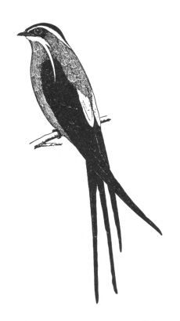

**Figure 6.14:** *Hemiprocne mystacea*, Whiskered Tree-swift

| **Proto Malaita-Makira** |  | *sisiri | ‘swiftlet’ |
| --- | --- | --- | --- |
| SES | To’aba’ita | *sīsiri* | ‘*Collocalia* sp.’ |
| SES | Lau | *sisiru* | ‘swallow’ |
| SES | Kwaio | *sīsili* | ‘*Collocalia* sp.’ |
| SES | ’Are’are | *sisiri(hapa)* | ‘a small swallow’ |
| SES | Sa’a | *sisiri (hapa)* | ‘swallow’ |
| SES | Uki ni Masi | *sisiri(hapa)* | ‘*Collocalia* sp.’ |
| SES | Arosi | *sisiri(hioha)* | ‘swallow, blue with red head, comes in houses’ |
| SES | Bauro | *sisiri (oha)* | ‘Pacific Swallow, *Hirundo tahitica*’ |

| **PNCal** |  | *bivilo(k) | ‘swiftlet’ |
| --- | --- | --- | --- |
| NCal | Nyelâyu | *pivilo* | ‘White-rumped Swiftlet, *Aerodramus spodiopygius*’ |
| NCal | Nêlêmwâ | *pivilo* | ‘White-bellied Swiftlet, *Collocalia esculenta*’ |
| NCal | Caac | *biviloc* | ‘swallow, white-rumped swiftlet’ |
| NCal | Jawe | *biviloc* | ‘*Aerodramus spodiopygius*’ |
| NCal | Cèmuhî | *hĩĩlò* | ‘*Aerodramus spodiopygius*’ |

| **PROc** |  | *ka(r,l)aka(r,l)a | ‘swiftlet’ |
| --- | --- | --- | --- |
| NCV | Mwotlap | *ne-keykey(beye)* | ‘Uniform Swiftlet, *Aerodramus vanikorensis*’ |
| NCV | Matantas | *na-textitkarakara* | ‘White-bellied Swiftlet, *Collocalia esculenta*’ |
| NCV | Matantas | *na-karakara(poi)* | ‘*Aerodramus vanikorensis*’ |
| NCV | Matantas | *na-karakara(ruhumele)* | ‘Pacific Swallow, *Hirundo tahitica*’ |
| NCV | Sakao | *harahara* | ‘*Aerodramus vanikorensis*’ (Flux 1993) |
| NCV | Kiai | *karakara* |  |
| NCV | Atchin | *kirkiri(el)* | ‘small bird resembling swallow, inabiting the mainland’ |
| Fij | Lomaiviti | *kalakala(mādrau)* | ‘White-rumped Swiftlet, *Aerodramus spodiopygius*’ |
| Pn | Takuu | *karakara(tavori)* | ‘*Collocalia esculenta*’ |
| Pn | Rennellese | *kaga(muʔa)* | ‘*Aerodramus* spp.’ |

### 5.13. Kingfishers (Alcedinidae)

Ten species of Kingfisher are recorded for the homeland, half of them in the genus *Halcyon*, which extends widely through Oceania. Particularly widespread are the White-collared Kingfisher (*Halcyon chloris*), the Sacred Kingfisher (*Halcyon sancta*) and the White-headed Kingfisher (*Halcyon saurophaga*). Other kingfishers of the homeland include the very large White-tailed Kingfisher (*Tanysiptera sylvia*), and the small birds of genera Ceyx and Alcedo. A number of good cognate sets exist, but assignment to species is very problematic. The relatively few terms for non-*Halcyon* species do not form any useful cognate sets. Blust (2002:113) compares POc *(sj)iko with PMP *cikep ‘catch with hands’.

| **POc** |  | *(s,j)iko | ‘kingfisher’ |
| --- | --- | --- | --- |
| NNG | Manam | *siko* | ‘bird sp. (short body, red beak and head, black wings, long white tail)’ |
| NNG | Lukep (Pono) | *siki* | ‘kingfisher’ |
| PT | Tawala | *diko* | ‘kingfisher’ |
| MM | Banoni | *(si)sikā* | ‘Dwarf Kingfisher, *Ceyx lepidus*’ |
| MM | Marovo | *cige* | ‘River Kingfisher, *Alcedo atthis*’ |
| MM | Nduke | *hige* | ‘River Kingfisher. *Alcedo atthis* and possibly other spp.’ |
| MM | Roviana | *sige* | ‘kingfisher sp. (small, swift-flying)’ |
| MM | Kia | *suke(neo)* | ‘White-collared Kingfisher, *Halcyon chloris*’ |
| SES | Bauro | *(a)sigo* | ‘*Halcyon* spp.’ |
| NCV | Mota | *siɣo* | ‘kingfisher’ |
| NCV | Dorig | *sıɣ* | ‘*Halcyon* spp.’ |
| NCV | Lakon | *tʃıː* | ‘*Halcyon* spp.’ |
| NCV | Raga | *(bʷat)hiɣo* | ‘*Halcyon chloris*’ |
| NCV | Matantas | *na-siho* | ‘*Halcyon chloris*’ |
| NCV | Kiai | *siko* | ‘kingfisher’ |
| NCV | Avava | *a-sik* | ‘*Halcyon chloris*’ |
| NCV | Port Sandwich | *na-six* | ‘*Halcyon chloris*’ |
| NCV | Southeast Ambrym | *si* | ‘*Halcyon chloris*’ |
| NCV | Paamese | *a-sio* | ‘*Halcyon chloris*’ |
| NCV | South Efate | *sīk* | ‘kingfisher’ |
| SV | Ura | *uɣe* | ‘kingfisher’ |
| SV | Sye | *uki* | ‘*Halcyon chloris*’ |
| SV | Anejom̃ | *ne-θeɣ* | ‘*Halcyon* sp.’ |
| NCal | Nêlêmwâ | *ʃīxe(men)* | ‘Sacred Kingfisher, *Halcyon sancta*’ |
| NCal | Paicî | *jöö(cā)* | ‘*Halcyon sancta*’ |
| Mic | Sonsorolese | *(taga)dik* | ‘kingfisher’ |
| Pn | Tongan | *siko(tā)* | ‘*Halcyon chloris*’ |
| Pn | East Futunan | *tiko(tala)* | ‘*Halcyon chloris*’ |
| Pn | Nukuria | *te-hiko* | ‘White-headed Kingfisher, *Halcyon saurophaga*’ |
| Pn | Takuu | *tiko(tala)* | ‘mythical bird sp.’ |
| Pn | Tikopia | *siko(tara)* | ‘*Halcyon chloris*’ |
| Pn | Ifira-Mele | *siko(tara)* | ‘*Halcyon chloris*’ |
| Pn | Tahitian | *ʔō(tātare)* | ‘Borabora Kingfisher, (*Halcyon tuta*) and Tahitian Kingfisher, *Halcyon venerata* also Long-billed Reed Warbler, *Acrocephalus caffer*’ |
| Pn | Rarotongan | *kō(tare)* | ‘*Halcyon tuta*’ |
| Pn | Māori | *ko(tare)* | ‘*Halcyon sancta*’ |

cf. also: A probable borrowing from a Southeast Solomonic language:

| Pn | Rennellese | *liɣo* | ‘*Halcyon chloris*’ |
| --- | --- | --- | --- |

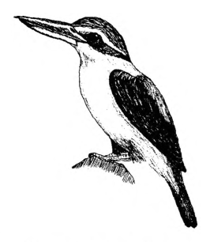

**Figure 6.15:** *Halcyon chloris*, White-collared Kingfisher

This word appears to have been reshaped in Polynesian to PPn *tiko-tara, a compound analysable as ‘defecate’ + ‘end of house’. Some outliers have returned to a historically earlier form through non-Pn influence. The Bauan Fijian word for kingfisher has a general resemblance to the Polynesian *tikotara forms, but cannot be formally reconciled with them; more exact agreement is found in the first part of the word *sikorere*, though with slightly deviant reference:

| Fij | Bauan | *sēðala* | ‘*Halcyon* spp.’ |
| --- | --- | --- | --- |
| Fij | Bauan | *sikorere* | ‘White-breasted Wood Swallow, *Artamus leucorhynchus*’ |

The following two sets are likely to be at least influenced by imitation of the voice of *Halcyon* kingfishers, represented as *ki-ki-ki-ki-ki-i-i-ee* (Watling 2004:137).

| **POc** |  | *ki(o)kio | ‘kingfisher’ (cf. PAn *kiaw ‘puling sound of a bird’; Blust 1995) |
| --- | --- | --- | --- |
| Adm | Nauna | *kikiw* | ‘kingfisher’ |
| Adm | Seimat | *kioki* | ‘kingfisher’ |
| Adm | Wuvulu | *ioio* | ‘kingfisher’ |
| NNG | Mangap | *kiakia(gāda)* | ‘kingfisher’ (cf. *gadgāda* ‘foolish, crazy’) |
| PT | Misima | *kiokio* | ‘kingfisher’ |
| PT | Nimoa | *kiokio* | ‘kingfisher’ |
| PT | Roro | *heoheo* | ‘kingfisher’ |
| MM | Tolai | *kiəkiə(tabu)* | ‘White-collared Kingfisher, *Halcyon chloris*’ |
| MM | Ramoaaina | *giagia(utam)* | ‘*Halcyon chloris* or White-tailed Kingfisher, *Tanysiptera sylvia*’ |
| MM | Nehan | *kekio* | ‘White-headed Kingfisher, *Halcyon saurophaga*’ |
| MM | Halia | *kikio* | ‘*Halcyon saurophaga*’ |
| MM | Halia | *kiukiu* | ‘kingfisher’ |
| MM | Petats | *keukeuo* | ‘kingfisher’ |
| MM | Banoni | *kiokio* | ‘*Halcyon saurophaga*’ |
| MM | Marovo | *kikio* | ‘*Halcyon saurophaga*’ |
| MM | Nduke | *kikio* | ‘*Halcyon saurophaga*, Beach Kingfisher’ |
| MM | Roviana | *kikio* | ‘the largest of the three kingfishers’ (i.e. *Halcyon* sp.) |
| MM | Simbo | *kikio* | ‘bird sp. found on reef’ |
| MM | Kia | *kiokio* | ‘Ultramarine Kingfisher, *Halcyon leucopygia*’ |
| MM | Maringe | *kʰiokʰio* | ‘*Halcyon saurophaga*’ |
| MM | Maringe | *ciocio* | ‘kingfisher sp. with white belly, blue wings and back’ |
| MM | Maringe | *kʰiakʰia* | ‘*Halcyon chloris*’ |
| SES | Gela | *giogio* | ‘a kingfisher’ |
| SES | Longgu | *kiokio* | ‘kingfisher’ |
| SES | Kwaio | *kiokio* | ‘*Halcyon saurophaga*’ |
| SES | Bauro | *kiokio* | ‘*Halcyon saurophaga*’ |
| Pn | Sikaiana | *kiokio* | ‘*Halcyon chloris*., also Island Grey-headed Monarch, *Monarcha cinerascens*’ |

| **POc** |  | *kiki | ‘kingfisher’ |
| --- | --- | --- | --- |
| Adm | Mussau | *sokiki* |  |
| MM | Vitu | *kiki* |  |
| MM | Tolai | *kik* | ‘*Halcyon* spp.’ |
| MM | Nakanai | *kiki* |  |
| SES | Kwaio | *ʔīʔī* | ‘White-collared Kingfisher, *Halcyon chloris*’ |
| NCal | Xârâcùù | *cicɔdɛ* | ‘Sacred Kingfisher, *Halcyon sancta*)’ |
| NCal | Drubea | *cécá* | ‘*Halcyon sancta*’ |
| NCal | Iaai | *jiji* | ‘*Halcyon sancta*’ |
| NCal | Dehu | *ciciat* |  |
| NCal | Nengone | *wa-zeze* |  |

### 5.14. Rollers (Coraciidae)

The single species in this family in the Oceanic homeland, the Dollar Bird (*Eurystomus orientalis*) can be associated with two small cognate sets, though there are problems of identification.

| **PWOc** |  | *ule(o) | ‘Dollar Bird, *Eurystomus orientalis*’ |
| --- | --- | --- | --- |
| PT | Iduna | *ule(kakamota)* |  |
| MM | Nduke | *uleo* |  |
| MM | Roviana | *uleo* | ‘bird sp., (Graucalus sublineatus) with a rather shrill note’ |

The obsolete generic in Roviana most probably refers to the Lineated Cuckoo Shrike (*Coracina lineata*). Since the terms below are distributed only around the Western Oceanic/SE Solomonic boundary, it is possible that terms have been borrowed across the boundary. If so, there is no support for a POc reconstruction.

| **POc** |  | *kikiroa~kikiora | ‘Dollar Bird, *Eurystomus orientalis*’ |
| --- | --- | --- | --- |
| MM | Roviana | *kik(i)ora* | ‘*Eurystomus orientalis*’ |
| MM | Maringe | *kʰikiloa* | ‘dark coloured bird with yellow markings around eyes and beak, possibly the dollar bird’ (White 1988); ‘Yellow-faced Mynah, *Mino dumontii*’ (Webb 1992) |
| SES | Malango | *kikirau* | ‘*Eurystomus orientalis*’ |
| SES | To’aba’ita | *kekeora* | ‘*Eurystomus orientalis*’ |

There are very similar names for this bird in some Papuan languages of Bougainville, such as Buin *kikitou*, Koromira *mekikiro*, which may be borrowings from Oceanic languages.

### 5.15. Hornbills (Bucerotidae)

Two good cognate sets are available for the single species, Blyth’s Hornbill (*Aceros plicatus*), which occurs throughout New Guinea and the Solomons.

| **POc** |  | *binam | ‘hornbill’ (ACD) |
| --- | --- | --- | --- |
| PT | Tubetube | *binam* |  |
| PT | Dobu | *binama* |  |
| PT | Iduna | *binama* |  |
| PT | Wedau | *binama* |  |
| PT | Balawaia | *bina* | ‘a large-beaked bird’ |
| PT | Motu | *bina* |  |
| SES | Bugotu | *bina* | ‘toucan’ |
| SES | Gela | *bina* | ‘toucan’ |
| SES | Malango | *bina* |  |
| SES | To’aba’ita | *bina* |  |
| SES | Kwaio | *bina* |  |
| SES | Arosi | *bina* | (awa) |

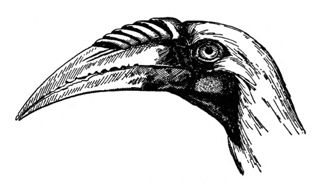

**Figure 6.16:** *Aceros plicatus*, Blyth’s Hornbill

The following indicate a considerable broadening of the reference of this term in some SE Solomonic languages:

| SES | ’Are’are | *pina (ni āno)* | ‘big grey pigeon’ (*āno* ‘garden’) |
| --- | --- | --- | --- |
| SES | Sa’a | *pine (ni ou)* | ‘Nicobar Pigeon, *Caloenas nicobarica*’ |
| SES | Arosi | *bina* | ‘hawk’ |
| SES | Arosi | *bina( ni asi)* | ‘booby’ (*asi* ‘sea’) |
| SES | Arosi | *bina (ahuri)* | ‘*Caloenas nicobarica*’ |
| SES | Arosi | *bina (ni mou)* | ‘*Caloenas nicobarica*’ (*mou* ’garden) |
| SES | Arosi | *bina (suʔu)* | ‘*Caloenas nicobarica*’ (*suʔu* ‘lake, swamp’) |

The hornbill’s voice is described as ‘various deep grunts and honking notes’ (Coates & Peckover 2001:113). Given the lack of exact agreement among the following names, it is likely that at least some represent repeated imitative coinages.

| **POc** |  | *koŋo(k) | ‘hornbill’ |
| --- | --- | --- | --- |
| NNG | Amara | *a-kŋok* |  |
| NNG | Kilenge | *a-kŋok* |  |
| NNG | Sengseng | *kaŋ-kaŋ* |  |
| NNG | Poeng | *gogo* |  |
| MM | Nehan | *ŋoŋo* |  |
| MM | Halia | *ŋuŋu* |  |
| MM | Petats | *ŋoŋo* |  |
| MM | Kia | *koŋo* |  |
| MM | Maringe | *na-kʰoŋo* |  |
| SES | Bugotu | *koŋo* | ‘toucan’ |

| **PWOc** |  | *komo | ‘hornbill’ |
| --- | --- | --- | --- |
| NNG | Kairiru | *wom* |  |
| MM | Nakanai | *ko-komo* | ‘head of hornbill (as decoration)’ |
| MM | Tolai | *ko-komo* |  |
| MM | Banoni | *komo* |  |
| MM | Nduke | *ko-gomo* |  |

The very large bill of the hornbill would account for the mis-identification as ‘toucan’ in the Bugotu and Gela sources. The toucan is a tropical American bird also celebrated for its extremely large bill.

## 6. Passerine birds

Although the Passerines belong to a single order (Passeriformes) among more than 20 within the class Aves, they account for more than half of all bird species. Yet in the present study there are far fewer cognate sets for passerines than for the rest. On the basis of the Kalam and Tobelo studies, there seems no reason to think that the Proto Oceanic speakers did not name the passerines in as much detail as other types of bird. Two factors may have contributed to the relative paucity of passerine cognate sets. First, many species are highly localised, which may have produced a high rate of turnover (abandonment and recreation of terms) as the Oceanic speakers migrated away from their homeland. Second, since these birds are, on average, smaller and less conspicuous (and of less economic importance) than the non-passerines, an accurate identification would require both a researcher with the means and inclination to go where the birds are, and a speaker as thoroughly informed about the avifauna as were the Oceanic ancestors. It is just this type of information that is lacking for most Oceanic languages; passerines are undoubtedly over-represented among the ‘unidentified bird species’ entries in the dictionaries.

### 6.1. Trillers and cuckoo-shrikes (Campephagidae)

The cuckoo-shrikes (*Coracina* spp.) and trillers (*Lalage* spp.) extend from the homeland into southern Melanesia. Some local cognate sets exist.

| **PNCal** |  | *tiā(k,ŋ) | ‘Melanesian Graybird, *Coracina caledonica*’ |
| --- | --- | --- | --- |
| NCal | Nyelâyu | *jiāŋ* |  |
| NCal | Nêlêmwâ | *jiāc* |  |
| NCal | Caac | *jiāk* |  |
| NCal | Jawe | *jiāk* |  |
| NCal | Fwai | *jiwāk* |  |
| NCal | Pije | *jiyaŋ* |  |
| NCal | Cèmuhî | *jīa* |  |
| NCal | Paicî | *cīö* |  |
| NCal | Tinrin | *ṭīo* |  |
| NCal | Xârâcùù | *cīö* |  |
| NCal | Drubea | *cíkò* |  |

| **PCP** |  | *(jea)jea | ‘Spotted Triller, *Lalage maculosa*’ |
| --- | --- | --- | --- |
| Fij | Rotuman | *jea* |  |
| Fij | Lomaiviti | *sea-sea* |  |
| Fij | Lau (Eastern Fijian) | *sea-sea* |  |
| Fij | Wayan | *sē-sē* |  |
| Pn | Niuean | *hea-hea* |  |

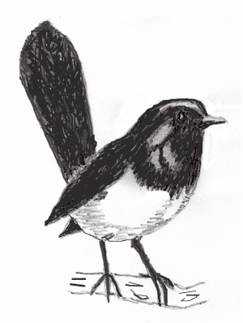

**Figure 6.17:** *Rhipidura leucophrys*, Willie Wagtail

At least some of the following are likely to be independent imitations of vocalizations variously represented as *whee-see*, *twill you twill you*, *keweeo*, and *squeeii*, produced by birds of this genus (Hadden 2004a: 185-7).

| **POc** |  | *pʷisu | ‘Cuckoo-shrike, *Coracina* sp.’ |
| --- | --- | --- | --- |
| MM | Maringe | *fisa* | ‘Common Cicadabird, *Coracina tenuirostris*’ |
| SES | Bauro | *hisu* | ‘*Coracina tenuirostris* (f)’ |
| NCV | Dorig | *(wa)vsu-vsar* | ‘Spotted Triller, *Lalage maculosa*’ |
| NCV | Raga | *vʷeu* | ‘Melanesian Greybird, *Coracina caledonica*’ |
| Pn | Tongan | *(siki)viu* | ‘*Lalage maculosa*’ |

cf. also:

| MM | Teop | *kuisau* | ‘Papuan Cuckoo Shrike, *Coracina papuensis*’ |
| --- | --- | --- | --- |
| MM | Banoni | *kuisa* | ‘*Coracina papuensis*’ |
| SES | Malango | *koiso* | ‘*Coracina* spp.’ |

### 6.2. Thrushes (Turdidae)

The only species for which any significant base of terms exists is the Island Thrush (*Turdus poliocephalus*).

| **PSOc** |  | *was(i,e) | ‘Island Thrush, *Turdus poliocephalus*’ (John Lynch, pers. comm.) |
| --- | --- | --- | --- |
| NCV | Mota | *wasia* | ‘a bird, merula’ |
| NCV | Lakon | *sıwsıw* | ‘Cuckoo-shrike, *Coracina* sp.’ (metathesis) |
| NCV | Raga | *esi-esi* |  |
| NCV | Atchin | *ni-was* | ‘sp. of bird that feeds in the creeks’ |
| SV | Sye | *wasep* |  |
| NCal | Nengone | *wasase* |  |

### 6.3. Fantails (Rhipiduridae) and flycatchers (Monarchidae)

The flycatchers (Myiagra, Monarcha) and fantails (Rhipidura) extend widely into the Oceanic region, but evince only a few local cognate sets.

#### 6.3.1. Fantails

The highly distinctive appearance and behaviour of fantails, and their tolerance of human proximity, make them familiar birds, much better represented by widespread cognate sets than the other flycatchers.

| **POc** |  | *takere | ‘Fantail, *Rhipidura* sp.’ |
| --- | --- | --- | --- |
| NNG | Bing | *teykil-kil(ahang)* | ‘willie wag tail’ |
| PT | Wedau | *tagiri-girim* | ‘wagtail’ |
| PT | Balawaia | *sikere(koio)* | ‘a small grass bird with long tail’ |
| PT | Hula | *tikere* | ‘willie wagtail’ |
| MM | Tolai | *taŋene* | ‘Sunbird, *Nectarinia* sp.’ |
| NCV | Mota | *taɣere* | ‘a bird, flycatcher’ |
| NCV | Lakon | *takɛ̄kɛ̄* | ‘Collared Grey Fantail, *Rhipidura fuliginosa*’ |
| NCV | Raga | *taɣere* | ‘*Rhipidura fuliginosa*’ |
| NCV | Southeast Ambrym | *tailel* | ‘Spotted Fantail, *Rhipidura spilodera*’ |
| NCV | Paamese | *tālēle* | ‘*Rhipidura spilodera*’ |
| NCV | Nguna | *takere-kere* |  |
| NCal | Nyelâyu | *dagīñ* |  |
| NCal | Nêlêmwâ | *dagiñ* | ‘*Rhipidura spilodera*’ |
| NCal | Caac | *dagiñ* |  |
| NCal | Jawe | *dagīñ* | ‘*Rhipidura spilodera*’ |
| NCal | Grand Couli | *dari* |  |
| Fij | Rotuman | *fœʔere* | ‘Fiji Shrikebill, *Clytorhynchus vitiensis*’ |

cf. also: A probable borrowing from some North-Central Vanuatu language:

| Pn | Emae | *takerokero* |  |
| --- | --- | --- | --- |

| **POc** |  | *laki | ‘fantail’ |
| --- | --- | --- | --- |
| MM | Nduke | *(ŋi)reɣi* | ‘fantail, possibly Cockerell’s Fantail, *Rhipidura cockerelli*’ |
| SES | Lau | *lai* | ‘fantail’ |
| SES | Kwara’ae | *laʔe* | ‘willy wagtail’ |
| SES | Kwaio | *laʔe* | ‘Willie Wagtail, *Rhipidura leucophrys*’ |
| NCV | Matantas | *liɣiliɣi* | ‘Spotted Fantail, *Rhipidura spilodera*’ |
| NCal | Paicî | *ñʌ̃di, ñẽti* | ‘*Rhipidura* spp.’ |
| NCal | Xârâcùù | *ñãdi* | ‘*Rhipidura* spp.’ |
| NCal | Drubea | *ñáti* | ‘*Rhipidura spilodera*’ |

| **Proto Northwest Solomonic** |  | *pitikole | ‘fantail’ |
| --- | --- | --- | --- |
| MM | Marovo | *pitikole* | ‘Willie Wagtail, *Rhipidura leucophrys*’ |
| MM | Nduke | *pitikole* | ‘*Rhipidura leucophrys*’ |
| MM | Roviana | *pitikole* | ‘*Rhipidura* sp.’ |
| MM | Simbo | *pitikole* | ‘bird sp. like a wagtail’ |
| MM | Maringe | *pʰipituale* | ‘*Rhipidura leucophrys*’ |

cf. also:

| MM | Halia | *pipikula* | ‘Willy Wagtail’ |
| --- | --- | --- | --- |

| **PNCV** |  | *vete-vete | ‘fantail’ |
| --- | --- | --- | --- |
| NCV | Raga | *vʷet-vete(rerea)* | ‘Spotted Fantail, *Rhipidura spilodera*’ |
| NCV | Naman | *(no-vi)vete-vet* | ‘fantail’ |
| NCV | Neve’ei | *(na-vi)vete-vet* | ‘fantail’ |

| **PSOc** |  | *sora | ‘fantail’ (John Lynch, pers. comm.) |
| --- | --- | --- | --- |
| NCV | Sakao | *nu-sora* | ‘Spotted Fantail, *Rhipidura spilodera*’ (Flux 1993) |
| NCV | Kiai | *sar(kele)* | ‘Collared Grey Fantail, *Rhipidura fuliginosa*’ |
| NCV | Nguna | *soro(pito)* | ‘fantail sp.’ |
| SV | Kwamera | *(ka)səra-sər* | ‘*Rhipidura fuliginosa*’ |

cf. also: The following potential cognate may be a local formation, cf. *tatara* ‘sweep’:

| SES | Arosi | *tatara(pʷera)* | ‘wagtail’ |
| --- | --- | --- | --- |

| **PSES** |  | *riuriu[kabe] | ‘Willie Wagtail, *Rhipidura leucophrys*’ |
| --- | --- | --- | --- |
| SES | Bugotu | *riuriuɣabi* |  |
| SES | Gela | *riuriupege* | ‘fantail’ |
| SES | Malango | *riuriuhabe* |  |
| SES | Longgu | *(ririʔu) kabi* | ‘fantail’ |
| SES | ’Are’are | *riuriu ʔapi* |  |
| SES | Sa’a | *hiʔuhiʔu pote* |  |
| SES | Ulawa | *hiʔuhiʔu kape* |  |
| SES | Uki ni Masi | *kiukiu rape* |  |
| SES | Arosi | *rurukape* |  |
| SES | Bauro | *riuriugape* |  |

cf. also: Apparently at least in part a borrowing from some SE Solomonic language:

| Pn | Rennellese | *maɣiɣape* | ‘Rennell Fantail, *Rhipidura rennelliana*’ |
| --- | --- | --- | --- |
| Pn | Rennellese | *maŋiɣape* |  |
| Pn | Rennellese | *maɣuɣape* |  |

The first part of this compound clearly relates to *riu* ‘turn’, referring to the bird’s characteristic turns with spread tail feathers, both in flight and perching. In two languages the following element is a body part: Sa’a *pote* ‘buttocks’, Gela *pege* ‘forepart of thigh’. But the more widespread second element seems more likely to be related to POc *kapak, compare Arosi *kape* ‘flutter’.

#### 6.3.2. Flycatchers

| **PEOc** |  | *paRapaRa | ‘flycatcher’ |
| --- | --- | --- | --- |
| SES | Uki ni Masi | *harahara(ŋata)* | ‘Chestnut-bellied Monarch (*Monarcha castaneiventris*’ |
| SES | Arosi | *harahara(ŋada)* | ‘bird sp.’ |
| SES | Bauro | *ɣaɣara(sia)* | ‘*Monarcha castaneiventris*’ |
| NCV | Southeast Ambrym | *holhol(vetei)* | ‘*Myiagra caledonica*’ |
| NCV | Paamese | *holiholi(vetā)* | ‘*Myiagra caledonica*’ |
| NCal | Paicî | *(nʌ̃)wãrã(ãbī)* | ‘*Myiagra caledonica*’ |

| **PEOc** |  | *k(o,u)vi | ‘Flycatcher, *Myiagra* sp.’ |
| --- | --- | --- | --- |
| SES | Malango | *(du)hui* | ‘Steel-blue Flycatcher, *Myiagra ferrocyanea*’ |
| NCV | Raga | *(buru)kuvi* | ‘*Myiagra ferrocyanea*’ |
| NCal | Nengone | *(wanere)kowɛ* | ‘*Myiagra caledonica*’ |
| Mic | Trukese | *koyi-koyi* | ‘a bird (pipes at dawn and dusk)’ |
| Mic | Mokilese | *koi-koi* | ‘bird sp.’ |
| Mic | Ponapean | *koi-koi* | ‘Micronesian Myiagra Flycatcher, *Myiagra oceanica*’ |
| Pn | Rennellese | *ɣo-ɣovi(u)* | ‘Rennell Shrikebill, *Clytorhynchus hamlini*’ |

### 6.4. Whistlers (Pachycephalidae)

The Golden Whistler, *Pachycephala pectoralis*, is the only widespread species in this family.

| **POc** |  | *sau | ‘Golden Whistler, *Pachycephala pectoralis*’ |
| --- | --- | --- | --- |
| MM | Maringe | *(k(h)ua)co* |  |
| SES | Malango | *(koe)cau* | ‘*Pachycephala* spp.’ |
| SES | Bauro | *tou-tou* |  |
| NCV | Raga | *so-so(belak)* |  |
| Fij | Lomaiviti | *(dīdībē)sau* |  |

### 6.5. Whiteyes (Zosteropidae)

A single species of this family, the White-throated White-eye, *Zosterops meeki*, occurs in the Oceanic homeland, but others of the same genus are very widely found throughout Oceania, with at least one local cognate set.

| **PNCV** |  | *laka | ‘White-eye, *Zosterops* sp.’ |
| --- | --- | --- | --- |
| NCV | Vera’a | *leɣleɣ(e)* |  |
| NCV | Raga | *laɣalaɣa* |  |
| NCV | Kiai | *lala* |  |
| NCV | Atchin | *(we)lela* | ‘small bird sp.’ |
| NCV | Naman | *(nə-vi)laɣalaɣ* | ‘Yellow-fronted White-eye, *Zosterops flavifrons*’ |
| NCV | Southeast Ambrym | *(tohu)laia* | ‘*Zosterops flavifrons*’ |
| NCV | Lewo | *(nin)laia* | ‘green bird’ |
| NCV | Namakir | *likalak* | ‘small yellow bird (feeds on pawpaw)’ |
| NCV | Nguna | *lāka* |  |

cf. also:

| NCV | Mota | *(mʷa)leɣ* |  |
| --- | --- | --- | --- |
| NCV | Mwotlap | *(na-mʷ)lıgleg* |  |

cf. also: probable borrowing from a North-Central Vanuatu language

| Pn | Emae | *lako* |  |
| --- | --- | --- | --- |

These SV words are possible cognates:

| SV | Ura | *(u)lcap* | ‘*Zosterops flavifrons*’ |
| --- | --- | --- | --- |
| SV | Sye | *(u)lcap, ne-lcap, (we)lcap* | ‘*Zosterops flavifrons*’ |

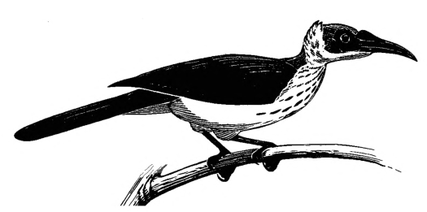

**Figure 6.18:** *Philemon buceroides*, Helmeted Friarbird

The following two items are the only possible Southeast Solomonic cognate found, and a possible Rennellese borrowing from a SE Solomonic language:

| SES | Gela | *(laulau)laka* | ‘very small bird sp.’ |
| --- | --- | --- | --- |
| Pn | Rennellese | *ɣaɣa* | ‘Woodford’s White-eye, *Woodfordia superciliosa*’ |

### 6.6. Honeyeaters (Meliphagidae)

The honeyeaters of the homeland region include several belonging to the genus Myzomela, as well as the New Britain Friarbird (*Philemon cockerelli*) and Gilliard’s Honeyeater (*Melidectes whitemanensis*). Other birds of this family can be found as far as Fiji and western Polynesia.

| **POc** |  | *midi | ‘honeyeater’ (see also PPn *miti, §6.7, p.349) |
| --- | --- | --- | --- |
| MM | Nehan | *(re)mit* | ‘Olive-backed Sunbird, *Nectarinia jugularis*’ |
| MM | Banoni | *mede-mede* | ‘Solomons Flowerpecker, *Dicaeum aeneum*’ |
| MM | Nduke | *(sik)midi* | ‘small honeyeater-like bird’ |
| SES | Gela | *mudu-mudu* | ‘blackbird sp.’ |
| SES | Lau | *(sisi)midi* | ‘honey eater’ |
| SES | Arosi | *mudi-mudi* | ‘yellow honeysucker’ |
| NCal | Tinrin | *(ma)mũrũ* | ‘bird sp. which sucks flowers’ |
| NCal | Xârâcùù | *(mā)mũrũ* | ‘Barred Honeyeater, *Phylidonyris undulata*’ |
| NCal | Drubea | *(má)mùrù* | ‘*Phylidonyris undulata*’ |
| Fij | Lau (Eastern Fijian) | *miti-miti, miti(kula)* | ‘Orange-breasted Honeyeater (*Myzomela jugularis*)’ |
| Pn | East Futunan | *miti (tokiko)* | ‘Carunculated Honeyeater, *Foulehaio carunculata*’ |

cf. also:

| Pn | Pileni | *mihi* | ‘red-fronted bird used for feather money’ (expected †*miti) |
| --- | --- | --- | --- |

The friarbirds (*Philemon* spp.) are a large and distinctive type of honeyeater represented by three species in the homeland region. The following terms present various formal problems, but could be derived from some form such as POc *(sa)quka, with metathesis to *(sa)-kuqa.[^9]

| Adm | Loniu | *cɔʔuka* | ‘White-naped Friarbird, *Philemon albitorques*’ |
| --- | --- | --- | --- |
| Adm | Titan | *cauka* | ‘friarbird, probably New Britain Friarbird, *Philemon cockerelli*’ |
| NNG | Musom | *kuaŋ* | ‘leatherhead’ (*Philemon*) |
| NNG | Aribwatsa | *uwaŋ* | ‘leatherhead’ |
| PT | Iduna | *takowa* | ‘Little Friarbird, *Philemon citreogularis*’ |
| PT | Gapapaiwa | *sakoa* | ‘Helmeted Friarbird, *Philemon buceroides*’ |
| MM | Nakanai | *kau* | ‘*Philemon cockerelli*’ |
| MM | Tolai | *kəo, kau* | ‘*Philemon cockerelli*’ |

| **PROc** |  | *(b,v)asilo | ‘honeyeater’ |
| --- | --- | --- | --- |
| NCV | Raga | *(busu)bihil* | ‘Cardinal Honeyeater, *Myzomela cardinalis*’ |
| NCV | Southeast Ambrym | *vasil* | ‘*Myzomela cardinalis*’ |
| NCV | Paamese | *vasiro* | ‘*Myzomela cardinalis*’ |
| NCal | Iaai | *bahelo* | ‘New Caledonian Friarbird, *Philemon diemensis*’ |
| Fij | W Viti Levu | *visilou* | ‘Carunculated Honeyeater, *Foulehaio carunculata*’ |
| Pn | Tongan | *fuleheu* | ‘*Foulehaio carunculata*, also Fiji Shrikebill, *Clytorhynchus vitiensis*’[^10] |

This set may be related to an innovative generic for ‘bird’ in a number of Central Vanuatu languages: Apma *bʷihil*, N Ambrym *pʷehel*, Burmbar *mbasir*, etc.

| **POc** |  | *ioli | ‘honeyeater’ |
| --- | --- | --- | --- |
| TM | Buma | *wau iele* | ‘Cardinal Honeyeater, *Myzomela cardinalis*’ |
| NCV | Kiai | *ioli* | ‘White-bellied Honeyeater, *Phylidonyris notabilis*’ |

| **PNCV** |  | *bʷatu-(i)-manu | ‘Cardinal Honeyeater, *Myzomela cardinalis*’ (lit. ‘head of bird’) |
| --- | --- | --- | --- |
| NCV | Mota | *pʷatman* | ‘a red-headed honey eater, male; cock bird of *tasis*’ |
| NCV | Mwotlap | *ne-pʷetmen* |  |
| NCV | Raga | *bʷat-i-manu* |  |

### 6.7. Starlings (Stumidae)

Starlings of the genus Aplonis, and the Yellow-faced Mynah, *Mino dumontii*, extend throughout much of Oceania. The first two cognate sets may be related.

| **POc** |  | *pusiRa | ‘Starling, *Aplonis* sp.’ |
| --- | --- | --- | --- |
| MM | Tolai | *vuirə* | ‘*Aplonis* spp.’ |
| NCV | Wusi (Nokovula) | *wōhia* | ‘New Hebrides Starling, *Aplonis zelandica*’ |
| Mic | Ponapean | *sie* |  |
| Fij | Rotuman | *husila* | ‘Striped Starling, *Aplonis labuensis*’ (*-R- > *-l-*, rare in Rotuman) |
| Fij | Bauan | *voðia* | ‘Fiji Shrikebill, *Clytorhynchus vitiensis*’ |
| Fij | W Viti Levu | *voðea* | ‘*Aplonis labuensis*’ |
| Fij | Lomaiviti | *voðea* | ‘*Aplonis labuensis*’ |
| Pn | Tongan | *fuiva* | ‘*Clytorhynchus vitiensis*’ |
| Pn | Samoan | *fuia* | ‘Samoan Starling, *Aplonis atrifusca*’ |
| Pn | Takuu | *fuia* | ‘Fead Island Starling, *Aplonis feadensis*’ |
| Pn | Luangiua | *huia* | ‘*Aplonis feadensis*’ |
| Pn | Māori | *huia* | ‘Huia, *Heteralocha acutirostris*’ |

The Shrikebill has in common with the starlings only a similar size and rather drab colouring. The Huia of New Zealand, a much larger bird, presents even less obvious similarity, and may have been named in imitation of its whistling call.

| **POc** |  | *bʷisu | ‘Shining Starling, *Aplonis metallica*’ |
| --- | --- | --- | --- |
| Adm | Lou | *pʷisi* | ‘black bird sp.’ |
| Adm | Drehet | *pʷisi* | ‘small black bird sp., with red eyes’ |
| SES | Lau | *bi-bisu* |  |
| SES | Kwara’ae | *bi-bisu* |  |
| SES | Kwaio | *bī-bisu* | ‘small black bird sp.’ |
| SES | Uki ni Masi | *pi-pisu* |  |
| SES | Arosi | *pi-pisu* | ‘bird sp.’ |
| SES | Bauro | *(a)pisu* |  |

cf. also: Probably borrowed from a SES language is

| Pn | Rennellese | *(ɣā)pilu* | ‘*Aplonis* sp.’ |
| --- | --- | --- | --- |

cf. also:

| MM | Teop | *buiŋbuiŋ* | ‘*Aplonis metallica*’ |
| --- | --- | --- | --- |
| MM | Tinputz | *bosiŋ* | ‘starling (general term)’ |
| NCV | Mota | *wotepispis* | ‘Island Thrush, *Turdus poliocephalus*’ |

The definition of Drehet *pʷisi* is a good description of *Aplonis metallica*. Yapese *gœʔpluw* ‘small black bird sp.’ bears a striking resemblance to the Rennellese word, but given the lack of precise identification and the absence of known borrowing in this direction, this is probably coincidental.

The following appears to be a continuation of POc *midi, reconstructed above (§6.6) as originally applying to honeyeaters, but extended in Polynesia to the starlings and toilers, on the basis of similarities which remain unclear.

| **PPn** |  | *miti | ‘Striped Starling, *Aplonis tabuensis*’ |
| --- | --- | --- | --- |
| Pn | Tongan | *misi* |  |
| Pn | Niuean | *miti* |  |
| Pn | East Uvean | *misi* |  |
| Pn | East Futunan | *miti (ʔuli)* | (*ʔuli* ‘black’) |
| Pn | Samoan | *miti* | ‘Spotted Triller, *Lalage maculosa*’ |
| Pn | Samoan | *miti tai* | ‘Samoan Triller, *Lalage sharpei*’ (*tai* ‘sea, shore’) |
| Pn | Samoan | *miti vao* | ‘*Aplonis tabuensis*’ (*vao* ‘forest’) |
| Pn | Tikopia | *miti* |  |

cf. also: Probable Polynesian borrowing:

| Fij | Lau (Eastern Fijian) | *miti* |  |
| --- | --- | --- | --- |

| **PSES** |  | *ciŋi(l)o | ‘Yellow-faced Mynah, *Mino dumontii*’ |
| --- | --- | --- | --- |
| SES | Malango | *ciŋiro* |  |
| SES | To’aba’ita | *siᵑgio* |  |
| SES | Lau | *siŋeo* | ‘starling’ |
| SES | Kwara’ae | *siᵑgilo* | ‘bird sp., black except for red around eye’ |

cf. also:

| MM | Halia | *cigilio* | ‘*Mino dumontii* or Fead Island Starling, *Aplonis feadensis*’ |
| --- | --- | --- | --- |
| MM | Banoni | *ciɣino* |  |
| MM | Torau | *sigineu* |  |

### 6.8. Wood swallows (Artamidae)

The Bismarck Wood Swallow (*Artamus insignis*) has congenerics elsewhere in Melanesia, but only two very local cognate sets have been found.

| **Proto Central Vanuatu** |  | *bai | ‘White-breasted Wood Swallow, *Artamus leucorhynchus*’ |
| --- | --- | --- | --- |
| NCV | Southeast Ambrym | *vœi-vœi* |  |
| NCV | Nguna | *pāe* |  |
| NCV | South Efate | *pāi* |  |

| **PNCal** |  | *kʰiñ | ‘White-breasted Wood Swallow, *Artamus leucorhynchus*’ |
| --- | --- | --- | --- |
| NCal | Nêlêmwâ | *xiñ* |  |
| NCal | Caac | *kʰiñ* |  |
| NCal | Fwai | *kʰeñ* |  |
| NCal | Cèmuhî | *kén* |  |

### 6.9. Crows (Corvidae)

Again a single species, the Australian Crow (*Corvus orru*) is present in the homeland, with congenerics elsewhere in Melanesia. Both *(kao)kao and *kaka are likely to show some influence of widespread representations of crow vocalizations such as English *caw*.

| **POc** |  | *(kao)kao | ‘crow, *Corvus* sp.’[^11] |
| --- | --- | --- | --- |
| NNG | Yabem | *aɔʔɔ* | ‘crow, raven’ |
| NNG | North Watut | *ŋaukŋauk* | ‘raven’ |
| NNG | Poeng | *kaokato* |  |
| PT | Dobu | *kaokao* |  |
| PT | Are | *ogaoga* |  |
| PT | Muyuw | *auwau* |  |
| PT | Hula | *kao* |  |
| PT | Mekeo | *oaŋou* | ‘native crow’ |
| MM | Nakanai | *kaokao* |  |
| MM | Patpatar | *kok* |  |
| MM | Halia | *koko(u)* |  |
| MM | Tinputz | *au* |  |
| MM | Banoni | *ɣeɣau* | ‘White-billed Crow, *Corvus woodfordi*’ |
| MM | Torau | *aoao* | ‘*Corvus woodfordi*’ |
| MM | Alu | *kō* |  |
| MM | Maringe | *na-ʔao* | ‘*Corvus woodfordi*’ (Webb 1992) ; ‘Yellow-faced Mynah, *Mino dumontii*’ (White 1988) |
| SES | Bugotu | *aoao* |  |
| SES | Malango | *kao* | ‘*Corvus woodfordi*’ |

| **PNGOc** |  | *ka(r,R)o(kV) | ‘crow’ |
| --- | --- | --- | --- |
| NNG | Manam | *kalo* | ‘black bird sp. (Blewett); raven (Krähe)’ |
| NNG | Kairiru | *qal* | ‘crow’ |
| NNG | Bariai | *karo* | ‘crow’ |
| NNG | Kove | *karo* | ‘crow’ |
| NNG | Lusi | *karo* | ‘crow’ |
| NNG | Dami | *kalog* | ‘crow’ |
| NNG | Takia | *alal* | ‘crow’ |
| NNG | Amara | *a-krok* | ‘crow’ |
| NNG | Kilenge | *a-kor* | ‘crow’ |
| NNG | Mangap | *aŋkor* | ‘raven, crow’ |
| NNG | Kaulong | *(ekiŋ) kʰoŋ* | ‘crow’ |
| NNG | Mouk | *ko-krak* | ‘crow’ |
| NNG | Lamogai | *ka-kroŋ* | ‘crow’ |
| NNG | Sengseng | *kohoŋ* | ‘crow’ |
| PT | Lala | *alo* | ‘crow’ |
| PT | Motu | *galo* | ‘crow’ |

| **PNCal** |  | *kaka | ‘New Caledonian Crow, *Corvus moneduloides*’ |
| --- | --- | --- | --- |
| NCal | Paicî | *këkë* |  |
| NCal | Ajië | *kēxē* |  |
| NCal | Tinrin | *kaɣa* |  |
| NCal | Xârâcùù | *gaka* |  |
| NCal | Drubea | *kʷákʷá* |  |

| **PNCal** |  | *hʷeek | ‘New Caledonian Crow, *Corvus moneduloides*’ |
| --- | --- | --- | --- |
| NCal | Nyelâyu | *wẽẽk* |  |
| NCal | Nêlêmwâ | *hʷẽẽk* |  |
| NCal | Caac | *hʷããk* |  |
| NCal | Fwai | *hʷã(w,wʷ)ãk* |  |

| **PPT** |  | *bʷayobʷayo | ‘crow’ |
| --- | --- | --- | --- |
| PT | Tubetube | *boioboio* | ‘crow’ |
| PT | Wagawaga | *waiwai* | ‘Australian Crow, *Corvus orru*’ |
| PT | Iduna | *bʷayobʷayo* | ‘*Corvus orru*’ |
| PT | Tawala | *waewae* | ‘crow’ |
| PT | Muyuw | *buaiobuaio* | ‘crow’ |

The following reconstruction seems very likely to have denoted some (probably black) passerine species, but the diversity of actual referents makes it hard to be more precise.

| **PNPn** |  | *mako | ‘small bird sp.’ |
| --- | --- | --- | --- |
| Pn | Samoan | *maʔo-maʔo* | ‘Black-breasted Honeyeater, *Gymnomyza samoensis*’ |
| Pn | Hawaiian | *(ʔō)maʔo* | ‘Hawaiian Thrush, *Myadestes obscurus*’ |
| Pn | Marquesan | *(kō)mako* | ‘Long-billed Reed Warbler, *Acrocephalus caffer*’ |
| Pn | Marquesan | *(ʔō)maʔo keʔekeʔe* | ‘Large Flycatcher, *Pomarea whitneyi*’ (keʔekeʔe ‘black’) |
| Pn | Mangareva | *(ko)mako* | ‘Tuamotu Warbler, *Acrocephalus atyphus*’ |
| Pn | Tahitian | *(ʔo)ma-maʔo* | ‘Society Islands Flycatcher, *Pomarea nigra*’ |
| Pn | Māori | *mako(mako), (kō)mako, (kori)mako* | ‘New Zealand Bellbird, *Anthornis melanura*’ |

## 7. Sea and shore birds

The sea and shore birds have in common that the species tend to be wide ranging rather than localised, many of them migrants or wanderers. The larger families contain numerous species whose field discrimination can be difficult. Observation of these birds becomes more common as sea orientation becomes more dominant, so that the most precise and detailed taxonomies are found in Micronesian and Polynesian languages.

### 7.1. Petrels (Procellariidae, Hydrobatidae)

Petrels come to land only to breed, and may be known primarily from the strange noises they make at their burrows at night. Of several species recorded for the homeland, only the Wedge-tailed Shearwater (*Puffinus pacificus*) breeds in the vicinity and is present year round.

There is a certain degree of crossover apparent between the families of petrels, albatrosses and boobies.

| **PROc** |  | *tinebu | ‘petrel’ |
| --- | --- | --- | --- |
| NCal | Nyelâyu | *cīnek* | ‘nightbird’ |
| NCal | Nêlêmwâ | *ĩlep* | ‘Tahiti Petrel, *Pseudobulweria rostrata*) and Wedge-tailed Shearwater, *Puffinus pacificus*’ |
| NCal | Caac | *ñhīnek* | ‘*Puffinus* spp.’ |
| NCal | Fwai | *ñinep* | ‘petrel’ |
| NCal | Voh-Koné | *ʒinep* | ‘White-winged Petrel, *Pterodroma leucoptera*’ |
| NCal | Cèmuhî | *īnip* | ‘Pterodroma leucoptera’ |
| Mic | Kiribatese | *tinepu* | ‘Christmas Island Shearwater, *Puffinus nativitatis*’ |

| **POc** |  | *saba(l) | ‘petrel or albatross’ |
| --- | --- | --- | --- |
| TM | Buma | *saba* | ‘Wandering Albatross, *Diomedea exulans*’ |
| Mic | Puluwatese | *hapal* | ‘petrel’ |
| Mic | Namoluk | *sapal* | ‘sea bird, dark coloured, blunt winged, size of noddy, never comes on land’ |

| **PROc** |  | *koro + | ‘petrel’ (+ modifier) |
| --- | --- | --- | --- |
| NCV | Namakir | *koro(lik)* | ‘black sea bird sp.’ |
| NCV | North Efate | *koro(liko)* | ‘Wedge-tailed Shearwater, *Puffinus pacificus*’[^12] |
| Mic | Kiribatese | *koro(paro)* | ‘*Puffinus pacificus*’ |
| Pn | Tahitian | *oro(matto)* | ‘Pelecanus fiber, Little Grey Booby’ (Forster 1775) |

| **PROc** |  | *ta(i)ko(k) | ‘petrel’ |
| --- | --- | --- | --- |
| **PSV** |  | *n-tako-tako(k) | ‘petrel’ |
| SV | Kwamera | *təkurakák* | ‘mutton bird (petrel spp.)’ |
| SV | Lenakel | *təkərka* | ‘mutton bird’ |
| **PPn** |  | *taiko | ‘petrel’ |
| Pn | Tongan | *teiko(o)* | ‘Audubon’s Shearwater, (*Puffinus lherminieri*) and Wedge-tailed Shearwater, *Puffinus pacificus*’ |
| Pn | Samoan | *taʔiʔo* | ‘*Puffinus* sp.’ |
| Pn | Pukapukan | *taiko* | ‘*Puffinus lherminieri*’ |
| Pn | Rapanui | *taiko* | ‘seabird sp.’ (Fuentes) |
| Pn | Rapanui | *taiho* | ‘Trinidade Petrel, *Pterodroma arminjoniana*’ (Metraux 1940) |
| Pn | Marquesan | *teiko* | ‘bird sp.’ |
| Pn | Mangareva | *kotai* | ‘petrel, perhaps *Puffinus lherminieri*’ (metathesis) |
| Pn | Rarotongan | *taiko* | ‘black petrel’ |
| Pn | Māori | *tāiko* | ‘Black Petrel, *Procellaria parkinsoni*’ |

cf. also: The Rotuman form is a loan from Polynesian:

| Fij | Rotuman | *tɔviko* | ‘shearwater’ (expected †*fɔiʔo*) |
| --- | --- | --- | --- |

| **PPn** |  | *lofa | ‘petrel or other large sea bird’ (cf. PPn *lofa ’extended, spread out (as a bird__s wings)’) |
| --- | --- | --- | --- |
| Pn | Tongan | *lofa* | ‘Frigate Bird, *Fregata* spp.’ |
| Pn | East Uvean | *lofa* | ‘bird sp.’ |
| Pn | Pukapukan | *noa* | ‘Brown Booby, *Sula leucogaster*’ |
| Pn | Nukuoro | *loha* | ‘bird sp. (never seen live)’ |
| Pn | Tikopia | *rofa* | ‘Great Frigate Bird, *Fregata minor*’ |
| Pn | Anutan | *ropa* | ‘bird sp.’ |
| Pn | Marquesan | *roha, noha* | ‘petrel or shearwater’ |
| Pn | Tahitian | *noha* | ‘Tahiti Petrel, *Pseudobulweria rostrata*’ |
| Pn | Tuamotuan | *noha* | ‘bird sp.’ |

### 7.2. Tropic-birds (Phaethontidae)

The two species of tropic-bird (*Phaethon*) are rare in Papua New Guinea waters but more frequently encountered in Remote Oceania. The Red-tailed Tropic Bird (*Phaethon rubricauda*) and the White-tailed Tropic Bird (*Phaethon lepturus*) differ, as their names suggest, in the colour of the two extremely elongated tail feathers by which this type of bird is readily recognised. They are generally covered by a single lexical item, though there may be a conventional specifier for one or the other, as in Tongan *tavake toto* ‘*Phaethon rubricauda*’ (*toto* ‘blood’).

| **PMic** |  | *tiku, *tuki | ‘tropic-bird’ (Bender et al. 2003) |
| --- | --- | --- | --- |
| Mic | Sonsorolese | *sə̄k* | ‘the phaeton’ |
| Mic | Woleaian | *süx* | ‘white tropic bird’ |
| Mic | Puluwatese | *wɨ̄k* |  |
| Mic | Carolinian | *sɨ̄x* | ‘white shore bird with a long tail’ |
| Mic | Namoluk | *ūk* | ‘White-tailed Tropic-bird, *Phaethon lepturus*’ |
| Mic | Trukese | *wɨ̄k* | ‘*Phaethon lepturus*’ |
| Mic | Ponapean | *sɨ̄k* | ‘white sea bird sp.’ |
| Mic | Mokilese | *cik* |  |
| Mic | Kosraean | *sik* | ‘bird sp.’ |
| Mic | Marshallese | *(lᵚokʷā)cɛk* | ‘Red-tailed Tropic-bird, *Phaethon rubricauda*’ |

cf. also: Probable borrowing from a Micronesian language:

| Yap | Yapese | *yūg* | ‘type of white dove-like bird with a long tail’ |
| --- | --- | --- | --- |

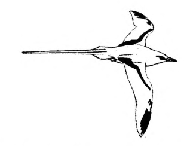

**Figure 6.19:** *Phaethon lepturus*, White-tailed Tropic Bird

| **PPn** |  | *tawake | ‘White-tailed Tropic-bird, *Phaethon lepturus*’ |
| --- | --- | --- | --- |
| Pn | Tongan | *tavake* |  |
| Pn | East Futunan | *tavake* |  |
| Pn | Samoan | *tavaʔe* |  |
| Pn | Tuvalu | *tavake* |  |
| Pn | Nukuoro | *tavake* |  |
| Pn | Sikaiana | *tavake* | ‘tropic bird’ |
| Pn | Rennellese | *tavake* | ‘Pacific Golden Plover, *Pluvialis fulva*’ |
| Pn | Tikopia | *tavake* |  |
| Pn | Emae | *manu tavake* | ‘tropic bird’ |
| Pn | Pukapukan | *tavake* | ‘tropic bird’ |
| Pn | Hawaiian | *koaʔe* | ‘tropic bird’ |
| Pn | Marquesan | *toake* |  |
| Pn | Tahitian | *tavaʔe* | ‘tropic bird’ |
| Pn | Rarotongan | *tavake* | ‘Red-tailed Tropic-bird, *Phaethon rubricauda*’ |
| Pn | Māori | *tawake* | ‘bird sp. mentioned in songs’ |

cf. also: Probable Polynesian borrowings:

| TM | Buma | *tavake* | ‘tropic bird’ |
| --- | --- | --- | --- |
| SV | Anejom̃ | *n-tauoɣ* | ‘*Phaethon* spp.’ |
| Mic | Kiribatese | *tāke* | ‘*Phaethon rubricauda*’ |
| Fij | Rotuman | *tœvœke* | ‘*Phaethon lepturus*’ (expected †*fœvœʔe*) |

cf. also: Probable Fijian cognate or borrowing:

| Fij | Bauan | *tawake* | ‘banner’ |
| --- | --- | --- | --- |

### 7.3. Boobies (Sulidae)

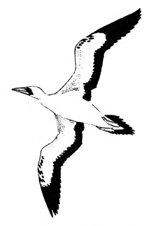

**Figure 6.20:** *Sula dactylatra*, Blue-faccd Booby

Of the three Boobies (genus Sula) found in Oceania, the Brown Booby (*Sula leucogaster*) is present year round in New Guinea waters. The Red-footed Booby (*Sula sula*), however, is also widely reported, while the Blue-faced Booby (*Sula dactylatra*) appears to be the least common. Only in Polynesia and Micronesia are the three species lexically distinguished.

| **PROc** |  | *pue | ‘Booby, *Sula* sp.’ |
| --- | --- | --- | --- |
| NCal | Nêlêmwâ | *(hʷare)wue* | ‘Brown Booby, *Sula leucogaster*’ |
| NCal | Caac | *ūa* |  |
| NCal | Fwai | *(tʰefʷana)we* |  |
| NCal | Iaai | *(sībo)üɛ* | ‘*Sula leucogaster*’ |
| Mic | Kiribatese | *(ki)pui* | ‘*Sula leucogaster*’ |
| **PPn** |  | *fua(kō) | ‘Booby, *Sula* sp.’ |
| Pn | Samoan | *fua(ʔō)* |  |
| Pn | Tokelauan | *fua(kō)* | ‘*Sula leucogaster*’ |
| Pn | Tahitian | *ua(ʔao)* | ‘Red-footed Booby, *Sula sula*’ |
| Pn | Tahitian | *aʔo* | ‘*Sula leucogaster*’ |

The following terms for petrels appear to be cognate:

| Pn | Tongan | *fuakō* | ‘Wedge-tailed Shearwater, *Puffinus pacificus*’[^13] |
| --- | --- | --- | --- |
| Pn | Hawaiian | *uaʔu* | ‘Hawaiian Petrel, *Pterodroma phaeopygia*’ |
| Pn | Hawaiian | *ʔaʔo* | ‘Manx Shearwater, *Puffinus puffinus*’ |

| **PNPn** |  | *(maua)kena | ‘booby, Sula sp.’ |
| --- | --- | --- | --- |
| Pn | Tuvalu | *kena* | ‘Blue-faced Booby, *Sula dactylatra*’ |
| Pn | Pukapukan | *kena* | ‘booby (?)’ |
| Pn | Kapingamarangi | *moua(kai)* | ‘Brown Booby, *Sula leucogaster*’ |
| Pn | Takuu | *mauakena* | ‘Red-footed Booby, *Sula sula*’ |
| Pn | Sikaiana | *mouakena* | ‘*Sula leucogaster*’ |
| Pn | Rennellese | *mauakena* | ‘*Sula sula*’ |
| Pn | Tikopia | *mauakena* | ‘*Sula dactylatra*’ |
| Pn | Rapanui | *kena* | ‘*Sula dactylatra*’ |
| Pn | Marquesan | *kena* | ‘*Sula leucogaster*’ |
| Pn | Mangareva | *kena* | ‘*Sula sula*’ |
| Pn | Manihiki | *kena* | ‘*Sula leucogaster*’ |
| Pn | Tongareva | *kena* | ‘*Sula sula*’ |

cf. also: A probable Polynesian borrowing:

| Mic | Kiribatese | *mouakena* | ‘*Sula dactylatra*’ |
| --- | --- | --- | --- |

The following also appears to be basically a term for a booby sp., though there is some spread to other sea birds. (The Maori word refers to a gannet, the temperate-zone counterpart of the booby, very similar in appearance and habits.)

| **PNPn** |  | *takupu | ‘Red-footed Booby, *Sula sula*’ |
| --- | --- | --- | --- |
| Pn | Tuvalu | *tapuku* |  |
| Pn | Tuvalu | *takupu* | ‘Dusky Shearwater, *Puffinus lherminieri*’ |
| Pn | Tokelauan | *takupu* | ‘*Sula sula* (adult)’ |
| Pn | Pukapukan | *takupu* | ‘*Sula sula* (dark morph)’ |
| Pn | Hawaiian | *kalupu* | ‘bird sp., perhaps albatross’ |
| Pn | Marquesan | *(kō)putu* | ‘Trindade Petrel, *Pterodroma arminjoniana*’ |
| Pn | Tuamotuan | *takupu* | ‘gannet’ |
| Pn | Tongareva | *tapuku* |  |
| Pn | Māori | *tākapu, tākupu* | ‘Australian Gannet, *Morus senator*’ |

| **PNPn** |  | *kanapu | ‘Brown Booby, *Sula leucogaster*’ |
| --- | --- | --- | --- |
| Pn | Tuvalu | *kanapu* |  |
| Pn | Nukuria | *kanapu* | ‘Red-footed Booby, *Sula sula*’ |
| Pn | Takuu | *kanapu* | ‘*Sula sula*’ |
| Pn | Luangiua | *ʔaŋapu, ʔaŋapaʔu* | ‘black and white seagull with red legs’ |
| Pn | Luangiua | *aŋapu* | ‘*Sula sula*’ |
| Pn | Sikaiana | *kanapu* | ‘bird sp.’ |
| Pn | Rennellese | *kanapu* |  |
| Pn | Tongareva | *kāpu* |  |

cf. also: A Polynesian borrowing:

| Fij | Rotuman | *kanɔpu* | (expected †*anɔʔu*) |
| --- | --- | --- | --- |

The following three forms suggest POc *kalau ‘booby’, but may be scattered cognates of the previous set. The Nukuoro word is probably borrowed from Micronesia.

| NNG | Mangap | *kalau* | ‘bird sp.’ |
| --- | --- | --- | --- |
| Mic | Marshallese | *kalᵚo* | ‘*Sula leucogaster*’ |
| Pn | Nukuoro | *kālau* | ‘brown booby’ |

This term is restricted to the central and northern Polynesian Outliers:

| **PNPn** |  | *katoko | ‘booby’ |
| --- | --- | --- | --- |
| Pn | Takuu | *kātoko* | ‘Blue-faced Booby, *Sula dactylatra*’ |
| Pn | Nukumanu | *(ha)katoko* | ‘Brown Booby, *Sula leucogaster*’ |
| Pn | Luangiua | *akoʔo* | ‘black bird sp. like frigate bird’ |
| Pn | Luangiua | *akoʔa* | ‘*Sula leucogaster*’ |
| Pn | Sikaiana | *katoko* | ‘Red-footed Booby, *Sula sula*’ |
| Pn | Sikaiana | *atoko* | ‘*Sula sula*’ |
| Pn | Rennellese | *katoko* | ‘young stage of kanapu, *Sula leucogaster*’ |
| Pn | Tikopia | *katoko* | ‘*Sula leucogaster*’ |

| **PROc** |  | *kemoa | ‘booby’ (cf. perhaps PWOc *kamʷaga ‘eagle, hawk’; §5.4.2) |
| --- | --- | --- | --- |
| Mic | Woleaian | *xemoa* | ‘booby bird’ |
| Mic | Puluwatese | *yɔmɔ* | ‘booby bird’ |
| Mic | Trukese | *ɔmɔ* | ‘booby bird’ |
| Pn | Pukapukan | *ākama* | ‘Red-footed Booby, *Sula sula* (white morph)’ |

### 7.4. Frigate birds (Fregatidae)

Two species of frigate bird are common in New Guinea waters, the Great Frigate Bird (*Fregata minor*) and the Lesser Frigate Bird (*Fregata ariel*). (The identifications of other species for Puluwat and Roviana below are likely to be erroneous.) Two clear POc reconstructions can be justified, though there seems to be no consistent lexical differentiation between the two species in the sources for contemporary languages.

| **POc** |  | *(dr,d)aula | ‘frigate bird’ |
| --- | --- | --- | --- |
| Adm | Mussau | *raura* |  |
| NNG | Bariai | *raila* |  |
| NNG | Gitua | *daula* | ‘seabird sp.’ |
| NNG | Gedaged | *daur* |  |
| NNG | Aria | *daila* | ‘bird sp.’ |
| PT | Muyuw | *dauta* |  |
| PT | Budibud | *dauka* |  |
| MM | Tigak | *raula* |  |
| MM | Label | *daulai* |  |
| MM | Tolai | *daulə* | ‘Lesser Frigate Bird, *Fregata ariel*’ |
| MM | Nehan | *daul* | ‘*Fregata ariel*’ |
| SES | Gela | *daula* |  |
| SES | Tolo | *daula* |  |
| SES | To’aba’ita | *kaule* |  |
| SES | Lau | *gaula* |  |
| SES | Kwaio | *gaula* |  |
| SES | ’Are’are | *kaura* |  |
| SES | Arosi | *gaura* |  |

cf. also: A borrowing from a SE Solomonic language:

| Pn | Pileni | *kaula, koula* |  |
| --- | --- | --- | --- |

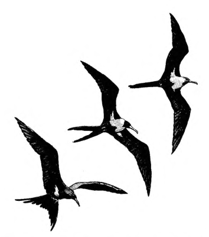

**Figure 6.21:** *Fregata ariel*, Lesser Frigate Bird

| **POc** |  | *katapa | ‘frigate bird’ |
| --- | --- | --- | --- |
| Adm | Loniu | *katah* | ‘large black seabird sp., white markings, dives to feed’ |
| Adm | Lou | *karap* |  |
| NCal | Nêlêmwâ | *cāve* | ‘Lesser Frigate Bird, *Fregata ariel*’ |
| NCal | Iaai | *ataü* | ‘*Fregata ariel*’ |
| NCal | Dehu | *wete* |  |
| NCal | Nengone | *waxej* |  |
| Mic | Sonsorolese | *xadāfɛ* |  |
| Mic | Puluwatese | *yahaf* | ‘Magnificent Frigate Bird, *Fregata magnificens*’ |
| Mic | Carolinian (Tanapag) | *ahaf* |  |
| Mic | Namoluk | *asaf* | ‘Great Frigate Bird, *Fregata minor*’ |
| Mic | Ponapean | *kasap* |  |
| Mic | Mokilese | *kacap* |  |
| Mic | Kiribatese | *eitei* |  |
| Mic | Nauruan | *itti* |  |
| Fij | Rotuman | *ʔafaha* |  |
| Fij | Bauan | *kasaga* | (expected †*katava*) |
| Pn | East Futunan | *katafa* | ‘*Fregata ariel*’ |
| Pn | Tongan | *kātafa* | ‘albatross’ |
| Pn | Niuean | *kotā* |  |
| Pn | Samoan | *ʔātafa* |  |
| Pn | Tokelauan | *katafa* | ‘*Fregata minor*’ |
| Pn | Pukapukan | *kotawa* |  |
| Pn | Nukuoro | *kataha* | ‘*Fregata minor*’ |
| Pn | Takuu | *katafa* |  |
| Pn | Sikaiana | *kataha* |  |
| Pn | Rennellese | *kataha* | ‘*Fregata ariel*’ |
| Pn | West Uvean | *katafa* | ‘*Fregata* sp.’ |
| Pn | Tahitian | *ʔōtaha* |  |
| Pn | Tongareva | *kōtaha* |  |
| Pn | Rarotongan | *kōtaʔa* |  |

| **Proto Northwest Solomonic** |  | *belama | ‘frigate bird’ |
| --- | --- | --- | --- |
| MM | Marovo | *belama* |  |
| MM | Nduke | *belama* |  |
| MM | Roviana | *belama* | ‘Ascension Frigate Bird, *Fregata aquila*’ |
| MM | Simbo | *beləmə* | ‘Lesser Frigate Bird, *Fregata ariel*’ |
| MM | Kia | *belama* |  |
| SES | Bugotu | *belama* |  |
| SES | Gela | *belama* |  |

(The glosses for Puluwat *yahaf* and Roviana *belama* are probably errors at the species level, as these frigate birds are not known in the Oceanic region.)

| **PNCal** |  | *kaidaa(n) | ‘frigate bird’ |
| --- | --- | --- | --- |
| NCal | Caac | *yʰāi dān* | ‘*Fregata* spp.’ |
| NCal | Fwai | *yāidān* | ‘*Fregata ariel*’ |
| NCal | Cèmuhî | *aidā* | ‘*Fregata* spp.’ |
| NCal | Paicî | *aidā* | ‘*Fregata* spp.’ |
| NCal | Ajië | *seidā* |  |

The Ajie name is explained as ‘the one who tells about the day’.

### 7.5. Waders (Charadriidae, Scolopacidae, Burhinidae)

More than twenty species of these shore birds frequent the coasts of the Oceanic homeland, but most are migrants seen only seasonally. Among the most commonly identified are the Bristle-thighed Curlew (*Numenius lahiliensis*), Whimbrel (*Numenius phaeopus*), Bartailed Godwit (*Limosa lapponica*), Wandering Tattler (*Heteroscelus incanus*), Pacific Golden Plover (*Pluvialis fulva*), and Ruddy Turnstone (*Arenaria interpres*). Field identification of these birds can be difficult, and even in Polynesia and Micronesia there are few cognate sets with completely consistent reference.

| **POc** |  | *jipiu | ‘wader’ |
| --- | --- | --- | --- |
| MM | Banoni | *civiu* | ‘small migratory waders’ |
| MM | Marovo | *suviu* | ‘*Tringa* spp.’ |
| MM | Nduke | *soviu* | ‘general name for sandpipers, *Tringa* spp.’ |
| MM | Nduke | *toviu* | ‘shore bird like a curlew, similar to *soviu* but smaller’ |
| SES | Gela | *di-diviu* | ‘snipe’ |
| SES | To’aba’ita | *si-sifiu* | ‘wader (perhaps *Numenius* sp.)’ |
| SES | Lau | *si-sifiu* | ‘sandpiper’ |
| SES | Kwaio | *si-sifiu* | ‘Common Sandpiper, *Actitis hypoleucos*’ |
| NCV | Mwotlap | *(ne-men) si-sivi* | ‘Pacific Golden Plover, *Pluvialis fulva*’ |
| NCV | Kiai | *zi-zivi(ro)* | ‘Wandering Tattler, *Heteroscelus incanus*’ |
| NCV | Paamese | *si-sihī* | ‘bird sp. found on coastal rocks’ |
| NCV | Lewo | *vio* | ‘sea bird sp.’ |
| NCV | Nguna | *siviu* | ‘shore bird sp.’ |
| NCV | South Efate | *sfiu, sfiw* | ‘whimbrel’ |
| NCal | Pije | *difīn* |  |
| NCal | Paicî | *dipiu* | ‘Grey-tailed Tattler, *Tringa brevipes* and Ruddy Turnstone, *Arenaria interpres*’ |

These Polynesian Outlier names are probably borrowings from Southeast Solomonic and Central Vanuatu languages, respectively:

| Pn | Rennellese | *siviu* | ‘Great Sand Plover, *Charadrius leschenaultii*’ |
| --- | --- | --- | --- |
| Pn | Emae | *siviu* | ‘large shore bird sp.’ |

| **PWOc** |  | *kiwiwi | ‘sandpiper sp.’ |
| --- | --- | --- | --- |
| PT | Gumawana | *kiwiwi* | ‘sandpiper sp.’ |
| PT | Iduna | *kiwiwi* | ‘sandpiper: white bird with black on its back, inhabits creeks’ |
| PT | Bwaidoga | *kiwiwi* | ‘sandpiper sp.’ |
| PT | Gapapaiwa | *kivivi* | ‘sea bird’ |
| PT | Wedau | *kivivi* | ‘plover; any kind of sand bird’ |
| PT | Motu | *kiwiwi* | ‘Common Sandpiper, *Actitis hypoleucos*’ |
| MM | Tabar | *kuvivi* |  |
| MM | Teop | *kivivi(o)* | ‘sea bird sp.’ |

| **POc** |  | *pʷipipi | ‘small wader taxon’ |
| --- | --- | --- | --- |
| PT | Iduna | *fififi* | ‘Rufous-necked Stint, *Calidris ruficollis*’ |
| MM | Marovo | *pivivi* | ‘*Limosa* spp.’ |
| MM | Nduke | *pivivi* | ‘*Tringa* spp., sandpiper’ |
| MM | Roviana | *pivivi* | ‘a small non-edible variety of sand snipe’ |
| SES | Lau | *kʷikʷī* | ‘snipe’ |

cf. also:

| TM | Buma | *vivi* | ‘*Charadrius* sp.’ |
| --- | --- | --- | --- |
| NCV | Southeast Ambrym | *hehe* | ‘sandpiper sp.’ |
| Pn | Tuvalu | *vivi(tai)* | ‘Wandering Tattler, *Heteroscelus incanus*’ |
| Pn | Sikaiana | *(vīvī)tai* | ‘Pacific Golden Plover, *Pluvialis fulva*’ |

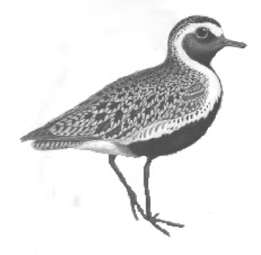

**Figure 6.22:** *Pluvialis fiulva*, Pacific Golden Plover

| **PROc** |  | *kVlili | ‘Wandering Tattler, *Heteroscelus incanus*’ |
| --- | --- | --- | --- |
| NCal | Nêlêmwâ | *hilili* | ‘*Heteroscelus incanus* and Pacific Golden Plover, *Pluvialis fulva*’ |
| **PMic** |  | *k(i,u)lili | ‘Wandering Tattler, *Heteroscelus incanus*’ |
| Mic | Woleaian | *ilīl(i)* | ‘plover’ |
| Mic | Trukese | *iɾīɾ* | ‘small plover’ |
| Mic | Namoluk | *ilil* |  |
| Mic | Kosraean | *kulul* | ‘sandpiper’ |
| Mic | Marshallese | *kiṛiṛ* |  |
| Mic | Kiribatese | *kiriri* |  |
| **PPn** |  | *kolili | ‘Wandering Tattler, *Heteroscelus incanus*’ |
| Pn | Tongan | *kolili* | ‘bird sp.’ |
| Pn | East Uvean | *polili* |  |
| Pn | Tokelauan | *kolili* |  |
| Pn | Tuvalu | *kolili* | ‘Ruddy Turnstone, *Arenaria interpres*’ |
| Pn | Pukapukan | *kolili* |  |
| Pn | Nukuria | *koriri* | ‘*Arenaria interpres*’ |
| Pn | Sikaiana | *kolili* | ‘bird sp.’ |
| Pn | Tikopia | *kolili* | ‘Common Sandpiper, *Actitis hypoleucos*’ |
| Pn | Hawaiian | *ʔūlili* |  |
| Pn | Tahitian | *ʔuriri* |  |
| Pn | Tongareva | *kuriri* |  |
| Pn | Rarotongan | *kuriri* |  |

| **PCP** |  | *tuli(i) | ‘Pacific Golden Plover, *Pluvialis fulva*’ |
| --- | --- | --- | --- |
| Fij | Rotuman | *culi* | ‘*Pluvialis fulva* and Wandering Tattler, *Heteroscelus incanus*’ |
| Fij | Bauan | *doli* | ‘*Pluvialis fulva*’ |
| Fij | Bauan | *doli-doli, dilio* | ‘*Heteroscelus incanus*’ |
| Fij | Wayan | *dolī* | ‘*Pluvialis fulva*’ |
| Fij | Wayan | *doli-dolī* | ‘*Heteroscelus incanus*’ |
| Pn | East Futunan | *tuli* | ‘various small shore-bird spp., *Pluvialis*, *Limosa*, *Heteroscelus*’ |
| Pn | Samoan | *tulī* | ‘various shore bird spp., *Pluvialis*, *Arenaria*, *Numenius*, *Limosa*, *Heteroscelus*, *Calidris*’ |
| Pn | Pukapukan | *tuli* |  |
| Pn | Tuvalu | *tuli* |  |
| Pn | Nukuoro | *tuli* |  |
| Pn | Kapingamarangi | *tuli* | ‘*Heteroscelus incanus*’ |
| Pn | Nukuria | *(te)tulia* | ‘Grey-rumped Sandpiper, *Heteroscelus brevipes*’ |
| Pn | Takuu | *turi* | ‘small black shore bird with white breast and large protruding eyes’ |
| Pn | Luangiua | *kili(kavoi)* | ‘Common Sandpiper, *Actitis hypoleucos*’ |
| Pn | Tikopia | *turi* | ‘*Pluvialis fulva*’ |
| Pn | Tikopia | *turi vare* | ‘*Heteroscelus incanus*’ |
| Pn | Tikopia | *turi fakataumako* | ‘Ruddy Turnstone, *Arenaria interpres*’ |
| Pn | Pileni | *tuli* | ‘a small wading bird’ |
| Pn | Marquesan | *turi* | ‘*Arenaria interpres*’ |
| Pn | Māori | *tu-turi(fatu)* | ‘dotterel, *Charadrius* spp.’ |

cf. also: A probable Polynesian borrowing is Nehan tulia in the following three forms:

| MM | Nehan | *tulia* | ‘*Actitis hypoleucos*’ |
| --- | --- | --- | --- |
| MM | Nehan | *tui-tui-tulia* | ‘*Pluvialis fulva*’ |
| MM | Nehan | *tuliaŋ* | ‘*Arenaria interpres*’ |

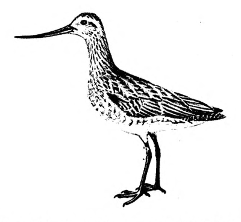

**Figure 6.23:** *Limosa lapponica*, Bar-tailed Godwit

| **PPn** |  | *kiu~kiwi | ‘shore bird taxon including *Pluvialis* and *Numenius*’ |
| --- | --- | --- | --- |
| Pn | Tongan | *kiu* | ‘any migratory wader’ |
| Pn | Niuean | *kiu* |  |
| Pn | East Uvean | *kiu* | ‘*Pluvialis fulva* and Bar-tailed Godwit, *Limosa lapponica*’ |
| Pn | Pukapukan | *kiu* | ‘plover sp.’ |
| Pn | Nukuoro | *kivi-kivi* | ‘Ruddy Turnstone, *Arenaria interpres*’ |
| Pn | Takuu | *kivi* | ‘general name for shore and wading birds’ |
| Pn | Luangiua | *ivi* |  |
| Pn | Sikaiana | *kivi* | ‘bird sp.’ |
| Pn | Sikaiana | *kivi(aitu)* | ‘Grey-rumped Sandpiper, *Heteroscelus brevipes*’ |
| Pn | Sikaiana | *kivi(talei)* | ‘*Arenaria interpres*’ |
| Pn | Tikopia | *kiu* | ‘Bristle-thighed Curlew, *Numenius tahitiensis*’ |
| Pn | Anutan | *kiui* | ‘a small bird which comes only during monsoon season’ |
| Pn | Emae | *kiu* | ‘small shore bird sp.’ |
| Pn | Marquesan | *kivi* | ‘Wandering Tattler, *Heteroscelus incanus*’ |
| Pn | Mangareva | *kivi* | ‘Bristle-thighed Curlew, *Numenius tahitiensis*’ |
| Pn | Tongareva | *kivi* | ‘*Numenius tahitensis*’ |
| Pn | Manihiki | *kivi, kihi* | ‘*Numenius tahitensis*’ |
| Pn | Māori | *kiwi* | ‘Kiwi, *Apteryx* spp.’ |

cf. also: Probably borrowed from Polynesian:

| MM | Halia | *kivi* | ‘generic term for waders, esp. *Pluvialis fulva*’ |
| --- | --- | --- | --- |

The set above is perhaps cognate with the set from which PWOc *kiwiwi ‘sandpiper sp.’ (p.360) is reconstructed. There are also probable Western Oceanic cognates, namely Tawala (PT), Gapapaiwa (PT) *kiu* ‘bird (generic)’ and Nakanai (MM) *e-kivu* ‘bird sp.’. Together with the set above these imply the reconstruction of POc *kiu, but its gloss cannot be reconstructed, as the Tawala and Gapapaiwa generic presumably reflects the promotion of a bird taxon term to generic status, and the Nakanai gloss is not specific.

| **PCEPn** |  | *tōrea | ‘Pacific Golden Plover, *Pluvialis fulva*’ |
| --- | --- | --- | --- |
| Pn | Hawaiian | *kōlea* |  |
| Pn | Tahitian | *tōrea* |  |
| Pn | Tongareva | *tōrea* |  |
| Pn | Manihiki | *tōrea* |  |
| Pn | Rarotongan | *tōrea* |  |
| Pn | Māori | *tōrea* | ‘Oystercatcher, *Haematopus* spp.’ |

| **PMic** |  | *kulu | ‘wader’ (Bender et al. 2003: ‘bird sp.’) |
| --- | --- | --- | --- |
| Mic | Mokilese | *kūl* | ‘bird sp.’ |
| Mic | Ponapean | *kulu* | ‘Pacific Golden Plover, *Pluvialis fulva*’ |
| Mic | Marshallese | *kʷōl* | ‘*Calidris* spp.’ |
| Mic | Marshallese | *kʷel* | ‘semipalmated sandpiper’ |
| Mic | Marshallese | *kʷel-yəc)* | ‘golden plover’ |
| Mic | Kiribatese | *kun* | ‘*Pluvialis fulva*’ |

| **Proto Chuukic-Ponapeic** |  | *kul(i,u)ŋa | ‘plover’ |
| --- | --- | --- | --- |
| Mic | Sonsorolese | *ɣīriŋa, kiriŋ* | ‘sandpiper, dotterel’ |
| Mic | Woleaian | *xuruŋ(o)* | ‘golden plover’ |
| Mic | Carolinian (Tanapag) | *gulīŋ* | ‘sp. of coastal bird, plover or sandpiper’ |
| Mic | Puluwatese | *kɨliŋ* | ‘Pacific Golden Plover, *Pluvialis fulva*’ |
| Mic | Namoluk | *kiliŋ* | ‘*Pluvialis fulva*’ |
| Mic | Trukese | *kuɾīŋ* | ‘plover’ |

cf. also: Probable borrowing from a Micronesian language:

| Yap | Yapese | *ʔkuleŋ* | ‘type of sea bird’ |
| --- | --- | --- | --- |

| **PROc** |  | *keke~kaka | ‘wader’ |
| --- | --- | --- | --- |
| SV | Anejom̃ | *na-ɣaɣ* | ‘Wandering Tattler, *Heteroscelus incanus*’ |
| NCal | Nyelâyu | *cẽẽk* | ‘shore bird’ |
| Mic | Woleaian | *(riy)ak(a)* | ‘bristle-thighed curlew’ |
| Mic | Puluwatese | *(liye)kāk* | ‘long-necked migratory shore bird’ |
| Mic | Namoluk | *(lia)kak* | ‘Whimbrel, *Numenius phaeopus*’ |
| Mic | Trukese | *(ɾiye)kak* | ‘bird sp.’ |
| Mic | Marshallese | *(lᵚa)kɛkɛ* | ‘*Pluvialis fulva*, black variety in breeding plumage’ |
| Mic | Kiribatese | *kaka* | ‘Bar-tailed Godwit, *Limosa lapponica*’ |

cf. also: Probable borrowings from some Micronesian language are:

| Pn | Nukuoro | *kaka* | ‘bird sp.’ |
| --- | --- | --- | --- |
| Pn | Kapingamarangi | *kaka* | ‘Bristle-thighed Curlew, *Numenius lahiliensis*’ |

Hote (NNG) *kakapʸak*, glossed as a ‘small black bird like a swallow; doesn’t sit in a tree but on rock; morning and afternoon it catches insects in sky’ is a possible Western Oceanic cognate, but its similarity to the items above may be due to chance.

| **PPn** |  | *(lafu)lafulafu | ‘wader sp.’ |
| --- | --- | --- | --- |
| Pn | Nukuoro | *lahulahu* | ‘Wandering Tattler, *Heteroscelus incanus*’ |
| Pn | Tokelauan | *lefulefu* | ‘Sanderling, *Calidris alba*’ |
| Pn | Pukapukan | *lewulewu* | ‘*Calidris alba*’ |
| Pn | Tongareva | *(kā)rahurahu* | ‘Blue-gray Noddy, *Procelsterna cerulea*’ |
| Pn | Rarotongan | *(ngōio-ʔā)reʔureʔu* | ‘*Procelsterna cerulea*’ |

cf. also: The following may be cognate, though the semantic connection is hardly close:

| Pn | Tongan | *lafu* | ‘petrel’ |
| --- | --- | --- | --- |

Finally, one very distinctive shore bird, much larger than the rest, with heavy build and thick bill, is well known in the western Solomons:

| **Proto Northwest Solomonic** |  | *(b,v)ili[ki(k,t)i] | ‘Beach Stone-Curlew, *Burhinus neglectus*’ |
| --- | --- | --- | --- |
| MM | Marovo | *bilikiki* |  |
| MM | Nduke | *vivili* |  |
| MM | Roviana | *bilikiki* | ‘large whitish bird, frequents beach, flat bill, fond of hermit crabs, etc.’ |
| MM | Simbo | *bilikiki* | ‘bird sp.’ |
| MM | Maringe | *bi(li)bili* |  |
| MM | Kia | *bilikiti* | ‘bird sp., eats crabs’ |

### 7.6. Terns (Laridae)

The family Laridae includes both gulls and terns. Gulls are mainly birds of the temperate zones, and are only rare visitors to tropical Oceania. The common gloss ‘seagull’ in dictionaries and vocabularies of languages in this area almost certainly indicates a tern. Several species of tern (Sterna, Thalasseus) are common in the waters of the homeland, along with noddies (Anous) and the very distinctive White Tern (*Gygis alba*).

| **PMP** |  | *kanaway | ‘white bird’ (Blust 2002) |
| --- | --- | --- | --- |
| **POc** |  | *kanawe | ‘tern, *Sterna* spp.’ |
| Adm | Loniu | *kanaw* | ‘bird sp. with black body and white head and beak; possibly a kind of noddy’ |
| Adm | Nyindrou | *kanau* | ‘white seagull’ |
| Adm | Lou | *kana* | ‘seagull’ |
| NNG | Yabem | *kano* | ‘seagull’ |
| NNG | Labu | *kanôla* | ‘small sp. of seagull’ |
| NNG | Mapos Buang | *kaŋ* | ‘seagull’ |
| NNG | Bariai | *kanae-nae* | ‘sea tern’ |
| NNG | Kove | *anae* | ‘sea tern’ |
| NNG | Lusi | *anae* | ‘sea tern’ |
| NNG | Bing | *kanay* | ‘seagull’ |
| NNG | Gedaged | *kanai* | ‘a sea gull’ |
| NNG | Dami | *kanai* | ‘seagull’ |
| NNG | Takia | *kanai* | ‘seagull’ |
| NNG | Mangap | *kanae* | ‘seagull’ |
| NNG | Kilenge | *kanae* | ‘sea tern’ |
| PT | Tawala | *kanawe* | ‘seagull’ |
| PT | Ubir | *kanau* | ‘seagull’ |
| PT | Nimoa | *kan-kanau* | ‘seagull’ |
| PT | Motu | *kanaɣe* | ‘seagull’ |
| MM | Patpatar | *kanaia* | ‘roseate tern’ |
| MM | Tolai | *kənai* | ‘*Sterna* sp.’ |
| MM | Halia | *nai* | ‘Black-naped Tern, *Sterna sumatrana*’ |
| MM | Taiof | *kanai* | ‘tern’ |
| SES | Gela | *ganae* | ‘a seagull, larger than sele’ |
| SES | Longgu | *anawa* | ‘tern’ |
| SES | To’aba’ita | *ʔanakʷe* | ‘*Sterna* sp.’ |
| SES | Kwaio | *ʔanakʷe* | ‘gull sp.’ |
| SES | Arosi | *ʔanawe* | ‘Red-billed Tropic Bird, *Phaethon aethurus*’ |
| Mic | Sonsorolese | *xainiau* | ‘birds of seagull type’ |

Although terns and tropic birds could be confused at a distance, the species identified for Arosi would be a rare stray in this part of the Pacific.

| **POc** |  | *sele(kai) | ‘tern’ |
| --- | --- | --- | --- |
| Adm | Loniu | *cɛlɛhɛy* | ‘small white bird sp., possibly a tern’ |
| MM | Marovo | *celekae* | ‘Sterna spp., esp. albifrons’ |
| MM | Nduke | *helekai* | ‘*Sterna* spp.’ |
| MM | Roviana | *helekae* | ‘white sea bird, often seen in flocks over a shoal of fish’ |
| MM | Simbo | *elekai* | ‘white sea bird sp.’ |
| MM | Kia | *helekai* | ‘seagull’ |
| SES | Gela | *sele* | ‘seagull’ |

cf. also:

| Mic | Sonsorolese | *kirigay, xirixax* | ‘Common Noddy, *Anous stolidus*’ |
| --- | --- | --- | --- |

| **POc** |  | *ker(a,e)(ker(a,e)) | ‘tern’ |
| --- | --- | --- | --- |
| PT | Tubetube | *(man)kelakela* | ‘seagull’ |
| PT | Dobu | *(me)kela* | ‘seagull’ |
| PT | Iduna | *(mai)ʔela* | ‘tern (generic)’ |
| PT | Ubir | *(manu)kerer* | ‘seagull’ |
| PT | Kilivila | *(me)kela* | ‘seagull’ |
| PT | Misima | *(man)kelakela* | ‘seagull’ |
| MM | Teop | *kera* | ‘tern (generic)’ |
| MM | Roviana | *(de)kere* | ‘noddy’ |
| MM | Simbo | *(de)keive* | ‘black sea bird sp.’ |
| MM | Nduke | *(de)kere* |  |
| MM | Marovo | *(de)kere* |  |
| Mic | Kiribatese | *kerēkere* | ‘Sooty Tern, *Sterna fuscata*’ |

| **PMic** |  | *karakara | ‘tern’ |
| --- | --- | --- | --- |
| Mic | Carolinian | *arār* | ‘small black bird sp.’ |
| Mic | Woleaian | *xarexar* | ‘grey-backed tern’ |
| Mic | Puluwatese | *yaṛār* | ‘sooty tern sp.’ |
| Mic | Puluwatese | *kaṛe(fas)* | ‘tern sp.’ |
| Mic | Namoluk | *arar* | ‘Black-naped Tern, *Sterna sumatrana*’ |
| Mic | Namoluk | *ara(fao)* | ‘Greater Crested Tern, *Thalasseus bergii*’ |
| Mic | Trukese | *arār* | ‘white tern’ |
| Mic | Marshallese | *keār* | ‘*Sterna* spp.’ |
| Mic | Kiribatese | *karakara* | ‘*Thalasseus bergii*’ |

cf. also:

| MM | Nehan | *kara* | ‘tern (generic)’ |
| --- | --- | --- | --- |

| **POc** |  | *kiRa | ‘White Tern, *Gygis alba*’ |
| --- | --- | --- | --- |
| Yap | Yapese | *gīgiy* | ‘bird sp.’ |
| MM | Halia | *kira* | ‘Little Tern, *Sterna albifrons*’ |
| MM | Petats | *kira* | ‘small white seabird which dives for small fish’ |

| **PMic** |  | *kiakia | ‘White Tern, *Gygis alba*’ |
| --- | --- | --- | --- |
| Mic | Sonsorolese | *giegi* |  |
| Mic | Woleaian | *xiyexiy* | ‘white or fairy tern’ |
| Mic | Carolinian (Tanapag) | *giyegi* | ‘white bird sp.’ |
| Mic | Puluwatese | *kiyekiy* |  |
| Mic | Namoluk | *ekiek* |  |
| Mic | Trukese | *ekiyek* |  |
| Mic | Ponapean | *kāke* | ‘fairy tern’ |
| Mic | Kiribatese | *kiakia* | ‘Black-naped Tern, *Sterna sumatrana*’ |
| Mic | Nauruan | *(da)gigia* | ‘white tern’ |
| **PPn** |  | *aki-aki | ‘White Tern, *Gygis alba*’ (metathesis) |
| Pn | Tongan | *ʔekiaki* |  |
| Pn | East Futunan | *akiaki* |  |
| Pn | Tokelauan | *akiaki* |  |
| Pn | Tuvalu | *akiaki* | ‘*Sterna sumatrana*’ |
| Pn | Pukapukan | *akiaki* | ‘*Sterna sumatrana*’ |
| Pn | Nukuoro | *akiaki* |  |
| Pn | Nukuria | *te-akiaki* |  |
| Pn | Luangiua | *iaʔi* | ‘white sea bird’ |
| Pn | Tikopia | *akiaki* |  |
| Pn | Rapanui | *kiakia* |  |

The following two terms from Polynesian Outliers show a closer resemblance to the Halia form above than to the rest of Polynesian, and are probably borrowed from some North Solomons language:

| Pn | Takuu | *kinakina* | ‘White Tern, *Gygis alba*’ |
| --- | --- | --- | --- |
| Pn | Sikaiana | *kinakina* | ‘White Tern, *Gygis alba*’ |

| **POc** |  | *bʷauro | ‘tern’ |
| --- | --- | --- | --- |
| TM | Buma | *bauro, bauri* | ‘noddy, *Anous* sp.’ |
| NCV | Labo | *nu-ᵐbuaxa (ne-tes)* | ‘gull’ (*tes* ‘seawater’) |
| NCV | Southwest Bay | *ni-ᵐbuar (ajᵐbataᵐbat)* | ‘gull’ |
| NCV | Maskelynes | *(na-li)ᵐbuer* | ‘gull’ |
| NCV | Port Sandwich | *(li)ᵐbuer* | ‘seagull’ |
| NCal | Nyelâyu | *bor(ivic)* | ‘sea bird’ |
| NCal | Nêlêmwâ | *bor(iric)* | ‘tern, *Sterna* spp.’ |
| Mic | Marshallese | *pᵚōṛᵚ(ōc)* | ‘a white sea bird’ |

| **POc** |  | *golo | ‘tern’ |
| --- | --- | --- | --- |
| MM | Banoni | *(va)ɣora* | ‘noddy sp.’ |
| MM | Marovo | *(va)golo* | ‘Greater Crested Tern, *Thalasseus bergii*’ |
| MM | Nduke | *(va)golo* | ‘*Sterna* sp., bergii’ |
| MM | Roviana | *(va) golo* | ‘sea bird, often seen with *helekae* following shoals of bonito etc.’ |
| MM | Simbo | *(va)golo* | ‘sea bird sp.’ |
| MM | Kia | *(va)ɣolo* | ‘Common Tern, *Sterna hirundo*’ |
| NCV | Mwotlap | *na-tkol* | ‘Black-naped Tern, *Sterna sumatrana*) (??)’ |
| NCal | Fwai | *kʰõle* | ‘*Sterna sumatrana*’ |
| NCal | Cèmuhî | *hõõle* | ‘Fairy Tern, *Sterna nereis*’ |
| Mic | Mokilese | *(sa)kɔl* | ‘tern sp. with white crest’ |

| **PAdm** |  | *baraŋ~rabaŋ | ‘tern’ |
| --- | --- | --- | --- |
| Adm | Mussau | *rabaŋana* | ‘seagull’ |
| Adm | Loniu | *paʔaŋ* | ‘white seabird sp., flies over sea and feeds on small fish; possibly tern or heron’ |
| Adm | Nyindrou | *barak* | ‘black seagull’ |

PAdm *baraŋ is reconstructed on the basis of the Loniu and Nyindrou terms. Mussau *rabaŋana* points to earlier *rabaŋan (or *baraŋan), but the relationship of Mussau to the Admiralties languages is not well enough understood to know what protolanguage this earlier term occurred in.

| **PPn** |  | *tala | ‘tern’ |
| --- | --- | --- | --- |
| Pn | Tongan | *tala* | ‘Greater Crested Tern, *Thalasseus bergii* and other terns with mainly white plumage’ |
| Pn | East Uvean | *tala* | ‘White Tern, *Gygis alba*’ |
| Pn | East Uvean | *tala(ŋoŋo)* | ‘Black-naped Tern, *Sterna sumatrana*’ |
| Pn | Tokelauan | *tala(ŋoŋo)* | ‘Sooty Tern, *Sterna fuscata*’ |
| Pn | Tuvalu | *tala* | ‘*Thalasseus bergii*’ |
| Pn | Tuvalu | *tala(liki)* | ‘*Sterna fuscata* or Blue-grey Noddy, *Procelsterna cerulea*’ |
| Pn | Tuvalu | *tala(alofi)* | ‘Spectacled Tern, *Sterna lunata*’ |
| Pn | Nukuoro | *tala* | ‘tern (?) vagrant species, hardly ever seen’ |
| Pn | Kapingamarangi | *tala* | ‘*Sterna lunata*’ |
| Pn | Takuu | *tara* | ‘*Thalasseus bergii*, *Sterna fuscata*, and other terns with black heads’ |
| Pn | Sikaiana | *tala* | ‘seagull sp.’; ‘*Thalasseus bergii*’ |
| Pn | Sikaiana | *tala* | ‘seagull sp.’; ‘*Thalasseus bergii*’ |
| Pn | Sikaiana | *tala(mona)* | ‘*Sterna fuscata*’ |
| Pn | Pileni | *tala* | ‘diving sea bird sp.’ |
| Pn | Rennellese | *taga* | ‘*Thalasseus bergii*’ |
| Pn | Tikopia | *tara moana* | ‘small kingfisher-like sea bird’ |
| Pn | Emae | *tara* | ‘largest sp. of tern’ |
| Pn | Marquesan | *taʔa* | ‘*Sterna fuscata*’ |
| Pn | Mangareva | *tarara* | ‘*Thalasseus bergii*’ |
| Pn | Tahitian | *tarā(papa)* | ‘*Thalasseus bergii*’ |
| Pn | Manihiki | *tara* | ‘*Sterna fuscata*’ |
| Pn | Māori | *tara* | ‘various tern and gull spp.’ |

cf. also: probable Polynesian borrowings:

| Fij | Rotuman | *tala* | ‘*Thalasseus bergii*’ (expected †*fala*) |
| --- | --- | --- | --- |
| Mic | Kiribatese | *tara(ŋoŋo)* | ‘*Sterna lunata*’ |

Watling (2004:208) gives Fijian *tala* (dialect unspecified) for ‘*Gygis alba*’ but this is unconfirmed by other sources.

The following term for a particular tern species may originate from a compound with *tala, though the identity of the second element is unclear.

| **PNPn** |  | *[ta]lapiti | ‘Black-naped Tern, *Sterna sumatrana*’ |
| --- | --- | --- | --- |
| Pn | Nukuoro | *lepiti* | ‘white tern?’ |
| Pn | Kapingamarangi | *tolopiti* |  |
| Pn | Nukuria | *tropiti* |  |
| Pn | Takuu | *lopiti* |  |
| Pn | Luangiua | *(ka)lapiki* |  |
| Pn | Sikaiana | *tapiti* |  |
| Pn | Rennellese | *gopiti* |  |

The noddies are smaller, generally dark-coloured relatives of the terns. Reconstructible terms for them are restricted to Central Pacific languages

| **PCP** |  | *ŋoŋo | ‘Common Noddy, *Anous stolidus*’ |
| --- | --- | --- | --- |
| Fij | Rotuman | *ŋoŋo* |  |
| Fij | Lau, Taveuni | *ŋoŋo* | ‘*Anous* spp.’ |
| Fij | Wayan | *ŋoŋo(sawa)* | ‘*Anous* spp.’ |
| Pn | Tongan | *ŋoŋo* |  |
| Pn | Niuean | *ŋoŋo* |  |
| Pn | Samoan | *ŋoŋo* | ‘*Anous* spp.’ |
| Pn | Pukapukan | *ŋoŋo* |  |
| Pn | Nukuoro | *ŋoŋo* |  |
| Pn | Nukuria | *(te)nono* |  |
| Pn | Takuu | *nnō* |  |
| Pn | Sikaiana | *nono* |  |
| Pn | Rennellese | *ŋoŋo* |  |
| Pn | Tikopia | *ŋoŋo* |  |

cf. also: An irrular change leads to forms reflecting PCEPn *ŋoio’.

| Pn | Hawaiian | *noio* | ‘White-capped Noddy, *Anous minutus*’ |
| --- | --- | --- | --- |
| Pn | Mangareva | *ŋoio* |  |
| Pn | Tahitian | *ʔōio* |  |
| Pn | Rarotongan | *ŋōio* |  |

The following term, like *lapiti above, may originally have been a compound of *tala with an unidentified second element:

| **PNPn** |  | *[ta]lakia | ‘White-capped Noddy, *Anous minutus*’ |
| --- | --- | --- | --- |
| Pn | Samoan | *laia* | ‘Blue-grey Noddy, *Procelsterna cerulea*’ |
| Pn | Tokelauan | *lakia* |  |
| Pn | Tuvalu | *lakia* |  |
| Pn | Pukapukan | *lakia* |  |
| Pn | Nukuoro | *lekia* |  |
| Pn | Kapingamarangi | *manu-telekia* |  |
| Pn | Nukuria | *terakia* |  |
| Pn | Takuu | *lakia* |  |
| Pn | Luangiua | *leia, leʔiʔa* |  |
| Pn | Sikaiana | *lekia, leia* |  |
| Pn | Tikopia | *rakia* |  |
| Pn | Tongareva | *rakia* |  |
| Pn | Manihiki | *rakie* |  |

## Notes

[^1]: This is distinct from POc *raun ‘leaves, head hair’, reflected in Titan (Adm) *laun* ‘leaf, hair, feathers’, Bariai (NNG) *i-laun* ‘his/her hair, its feathers’.
[^2]: Isneg *motoŋ* ‘mouth’. Iban *muncoŋ* ‘protruding, sticking out. esp. of jaw or lips’, Toba Batak *munsuŋ* ‘beak, snout’, Malay *moncoŋ* ‘snout’, Wolio *muncu* ‘(outside of the) mouth, beak, snout’.
[^3]: Both *ŋuju and *muju were also apparently used for the carved prow of a canoe, i.e. its ‘beak’: see vol.1,189.
[^4]: Cognates in SHWNG languages include Mor *nibi*, *niwi*, Waropen *ni*, Biak *niw* (Anceaux 1961).
[^5]: Note that Jackson & Marck (1991) consider Carolinian *ŋāŋa* a loan from Chamorro *ŋaŋaʔ* ‘duck’.
[^6]: Southern Melanesian is a subgroup proposed by John Lynch comprising the Southern Vanuatu and New Caledonian languages. See for example Lynch (2004b: 317).
[^7]: ‘Pasismanua’ is the name provisionally used here for ‘native names’ given by Gilliard & Lecroy (1967) for birds identified during the 1958-59 Gilliard New Britain Expedition. The spellings are impressionistic and the language or languages are not clearly identified, but the area of the expedition’s work lies within the territory of the Pasismanua group of languages, part of the Southwest New Britain Linkage.
[^8]: cf. PAn *tuRtuR ‘resonant sound’ (Blust 1995)
[^9]: Cf. Nage (CMP) *koka* ‘*Philemon buceroides*’.
[^10]: Niuatoputapu and Tafahi.
[^11]: Cf. (WMP) Muna *kaoki*.
[^12]: Tongoa.
[^13]: Niuatoputapu.